# White Matter Development: Analysis

Benjamin Risk

5/27/2024

```r
library(mgcv)
library(itsadug)
dat_harmonized = read.csv('dat_harmonized.csv',stringsAsFactors = TRUE)
```

Fx – Fornix (limbic, output of hippocampus)

IFOF – inferior-fronto-occipital-fasciculus (associative, connects occipital cortex to frontal lobe)

CCb – body of corpus callosum (commissural, connects hemispheres)

PT – pyramidal tract includes pyramidal neurons connecting motor neurons to brain stem or spinal cord (corticospinal and corticobulbar tracts)

```r
#Function for examining whether there is an interaction between GA and corrected age
### FA
maxCorrAge = function(GAlow,GAhigh=40,model,ylab,less=TRUE,print.plot=FALSE) {
  a=plot_diff(model,view='Corr_age',comp=list(GA=c(GAlow,GAhigh)),sim.ci = TRUE, hide.label=TRUE,xlab='Corrected age (days)',ylab=ylab,plot=print.plot)
  if(less) {
  max(a$Corr_age[a$est+a$sim.CI<0])
  } else {
    max(a$Corr_age[a$est-a$sim.CI>0])
  }
}
minCorrAge = function(GAlow,GAhigh=40,model,ylab,less=TRUE,print.plot=FALSE) {
  a=plot_diff(model,view='Corr_age',comp=list(GA=c(GAlow,GAhigh)),sim.ci = TRUE, hide.label=TRUE,xlab='Corrected age (days)',ylab=ylab,plot=print.plot)
  if(less) {
  min(a$Corr_age[a$est+a$sim.CI<0])
  } else {
    min(a$Corr_age[a$est-a$sim.CI>0])
  }
}

# Create plots at different gestational ages:
my.function.ga.corr <- function(dti.tract, my.ylim = c(0.1,0.3), my.ylab,  my.main="", estMaxCorrAge=TRUE,estMinCorrAge=FALSE,print.legend=FALSE,less=TRUE) {
    model0 = gam(dti.tract~ti(Corr_age,k=9)+ti(GA,k=5)+ti(Corr_age,GA,k=c(9,5))+Sex+s(Unique_ID,bs='re'),method='REML',data=dat_harmonized)
  # step into function to examine model diagnostics:
 # gam.check(model0)
  print(summary(model0))

  # vis.gam(model0,view=c('chor_age','GA'),theta=-45,ticktype='detailed',xlab='Chron Age',ylab='Gest Age',zlab='FA')
  set.seed(123)

  #tiff('../Figures/DiffCurves_FA.tiff',width=720,height=480,pointsize=20)
  if (estMaxCorrAge) {
      # par(mfrow=c(2,3))
      (ga.35=maxCorrAge(GAlow=35,GAhigh=40,model=model0,ylab='Est. difference',less=less))
      (ga.36=maxCorrAge(GAlow=36,GAhigh=40,model=model0,ylab='Est. difference',less=less))
      (ga.37=maxCorrAge(GAlow=37,GAhigh=40,model=model0,ylab='Est. difference',less=less))
      (ga.38=maxCorrAge(GAlow=38,GAhigh=40,model=model0,ylab='Est. difference',less=less))
      (ga.39=maxCorrAge(GAlow=39,GAhigh=40,model=model0,ylab='Est. difference',less=less))
      (ga.41=maxCorrAge(GAlow=40,GAhigh=41,model=model0,ylab='Est. difference',less=less))
      #dev.off()
  }

  if (estMinCorrAge) {
      # par(mfrow=c(2,3))
      (ga.35=minCorrAge(GAlow=35,GAhigh=40,model=model0,ylab='Est. difference',less=less))
      (ga.36=minCorrAge(GAlow=36,GAhigh=40,model=model0,ylab='Est. difference',less=less))
      (ga.37=minCorrAge(GAlow=37,GAhigh=40,model=model0,ylab='Est. difference',less=less))
      (ga.38=minCorrAge(GAlow=38,GAhigh=40,model=model0,ylab='Est. difference',less=less))
      (ga.39=minCorrAge(GAlow=39,GAhigh=40,model=model0,ylab='Est. difference',less=less))
      (ga.41=minCorrAge(GAlow=40,GAhigh=41,model=model0,ylab='Est. difference',less=less))
      #dev.off()
  }

  cColors = viridis::plasma(15)

    model0.plot = plot_smooth(model0, view="Corr_age",cond=list(GA=35),col=cColors[1],rug=FALSE,ylim=my.ylim,lwd=2,se=0,ylab=my.ylab,xlab='Corrected age (days)',hide.label=TRUE,main=my.main,xlim=c(2,201),print.summary=FALSE)
  plot_smooth(model0, view="Corr_age",cond=list(GA=36),col=cColors[3],add=TRUE,rug=FALSE,lwd=2,se=0,print.summary=FALSE)
  plot_smooth(model0, view="Corr_age",  cond=list(GA=37),col=cColors[5],add=TRUE,rug=FALSE,lwd=2,se=0,print.summary=FALSE,xlim=c(2,201))
  plot_smooth(model0, view="Corr_age", se=0, cond=list(GA=38),col=cColors[7],add=TRUE,rug=FALSE,lwd=2,print.summary=FALSE,xlim=c(2,201))
  plot_smooth(model0, view="Corr_age", se=0, cond=list(GA=39),col=cColors[9],add=TRUE,rug=FALSE,lwd=2,print.summary=FALSE,xlim=c(2,201))
  plot_smooth(model0, view="Corr_age", se=0, cond=list(GA=40),col=cColors[11],add=TRUE,rug=FALSE,lwd=2,print.summary=FALSE,xlim=c(2,201))
  plot_smooth(model0, view="Corr_age", se=0, cond=list(GA=41),col=cColors[13],add=TRUE,rug=FALSE,lwd=2,print.summary=FALSE,xlim=c(2,201))

  if(print.legend==TRUE) {
  legend(x='bottomright',legend=c('GA=35','GA=36','GA=37','GA=38','GA=39','GA=40','GA=41'),lty=1,lwd=2,col=cColors[seq(1,13,by=2)],bty='n',cex=1)
  }
  if (estMaxCorrAge | estMinCorrAge) {
    abline(v=ga.41,col=cColors[13],lwd=2,lty=2)
    abline(v=ga.39,col=cColors[9],lwd=2,lty=2)
    abline(v=ga.38,col=cColors[7],lwd=2,lty=2)
    abline(v=ga.37,col=cColors[5],lwd=2,lty=2)
    abline(v=ga.36,col=cColors[3],lwd=2,lty=2)
    abline(v=ga.35,col=cColors[1],lwd=2,lty=2)
  }
  my.plot = recordPlot()
  my.plot
}
```

```r
tiff('../Figures/TractSpecific_GestCorrectedAgeFA.tiff',width=1080,height=1280,pointsize=18)

par(mfrow=c(4,3))

fx.fa = my.function.ga.corr(dti.tract = dat_harmonized$Fx_fa.combat, my.ylab = "FX FA")
```

```
##
## Family: gaussian
## Link function: identity
##
## Formula:
## dti.tract ~ ti(Corr_age, k = 9) + ti(GA, k = 5) + ti(Corr_age,
##     GA, k = c(9, 5)) + Sex + s(Unique_ID, bs = "re")
##
## Parametric coefficients:
##               Estimate Std. Error t value Pr(>|t|)
## (Intercept)  0.2019474  0.0022111  91.335   <2e-16 ***
## SexM        -0.0004175  0.0028337  -0.147    0.883
## ---
## Signif. codes:  0 '***' 0.001 '**' 0.01 '*' 0.05 '.' 0.1 ' ' 1
##
## Approximate significance of smooth terms:
##                    edf Ref.df     F  p-value
## ti(Corr_age)     2.179  2.637 9.370 8.19e-05 ***
## ti(GA)           1.237  1.312 4.044   0.0264 *
## ti(Corr_age,GA)  1.002  1.004 0.502   0.4804
## s(Unique_ID)    51.658 76.000 2.238 5.40e-07 ***
## ---
## Signif. codes:  0 '***' 0.001 '**' 0.01 '*' 0.05 '.' 0.1 ' ' 1
##
## R-sq.(adj) =  0.685   Deviance explained = 82.6%
## -REML = -368.58  Scale est. = 6.6006e-05  n = 129
## Summary:
##  * Sex : factor; set to the value(s): M.
##  * Corr_age : numeric predictor; with 200 values ranging from 2.000000 to 201.000000.
##  * Unique_ID : factor; set to the value(s): 00106_04. (Might be canceled as random effect, check below.)
##  * NOTE : The following random effects columns are canceled: s(Unique_ID)
##
##  * Simultaneous 95%-CI used :
##      Critical value: 2.445
##      Proportion posterior simulations in pointwise CI: 1 (10000 samples)
##      Proportion posterior simulations in simultaneous CI: 1 (10000 samples)
##
```

```
## Summary:
##  * Sex : factor; set to the value(s): M.
##  * Corr_age : numeric predictor; with 200 values ranging from 2.000000 to 201.000000.
##  * Unique_ID : factor; set to the value(s): 00106_04. (Might be canceled as random effect, check below.)
##  * NOTE : The following random effects columns are canceled: s(Unique_ID)
##
##  * Simultaneous 95%-CI used :
##      Critical value: 2.417
##      Proportion posterior simulations in pointwise CI: 1 (10000 samples)
##      Proportion posterior simulations in simultaneous CI: 1 (10000 samples)
##
```

```
## Summary:
##  * Sex : factor; set to the value(s): M.
##  * Corr_age : numeric predictor; with 200 values ranging from 2.000000 to 201.000000.
##  * Unique_ID : factor; set to the value(s): 00106_04. (Might be canceled as random effect, check below.)
##  * NOTE : The following random effects columns are canceled: s(Unique_ID)
##
##  * Simultaneous 95%-CI used :
##      Critical value: 2.4
##      Proportion posterior simulations in pointwise CI: 1 (10000 samples)
##      Proportion posterior simulations in simultaneous CI: 1 (10000 samples)
##
```

```
## Summary:
##  * Sex : factor; set to the value(s): M.
##  * Corr_age : numeric predictor; with 200 values ranging from 2.000000 to 201.000000.
##  * Unique_ID : factor; set to the value(s): 00106_04. (Might be canceled as random effect, check below.)
##  * NOTE : The following random effects columns are canceled: s(Unique_ID)
##
##  * Simultaneous 95%-CI used :
##      Critical value: 2.351
##      Proportion posterior simulations in pointwise CI: 1 (10000 samples)
##      Proportion posterior simulations in simultaneous CI: 1 (10000 samples)
##
```

```
## Summary:
##  * Sex : factor; set to the value(s): M.
##  * Corr_age : numeric predictor; with 200 values ranging from 2.000000 to 201.000000.
##  * Unique_ID : factor; set to the value(s): 00106_04. (Might be canceled as random effect, check below.)
##  * NOTE : The following random effects columns are canceled: s(Unique_ID)
##
##  * Simultaneous 95%-CI used :
##      Critical value: 2.361
##      Proportion posterior simulations in pointwise CI: 1 (10000 samples)
##      Proportion posterior simulations in simultaneous CI: 1 (10000 samples)
##
```

```
## Summary:
##  * Sex : factor; set to the value(s): M.
##  * Corr_age : numeric predictor; with 200 values ranging from 2.000000 to 201.000000.
##  * Unique_ID : factor; set to the value(s): 00106_04. (Might be canceled as random effect, check below.)
##  * NOTE : The following random effects columns are canceled: s(Unique_ID)
##
##  * Simultaneous 95%-CI used :
##      Critical value: 2.33
##      Proportion posterior simulations in pointwise CI: 1 (10000 samples)
##      Proportion posterior simulations in simultaneous CI: 1 (10000 samples)
##
```

```r
# check if there is a difference for entire time range or no difference anywhere:
#model0 = gam(Fx_fa.combat~ti(chor_age,k=9)+ti(GA,k=5)+ti(chor_age,GA,k=c(9,5))+Sex+s(Unique_ID,bs='re'),method='REML',data=dat_harmonized)
#plot_diff(model0,view='chor_age',comp=list(GA=c(35,40)),sim.ci = TRUE, hide.label=TRUE,xlab='Chronological age (days)')


ci.fa = my.function.ga.corr(dti.tract = dat_harmonized$Ci_fa.combat, my.ylab = "Ci FA")
```

```
##
## Family: gaussian
## Link function: identity
##
## Formula:
## dti.tract ~ ti(Corr_age, k = 9) + ti(GA, k = 5) + ti(Corr_age,
##     GA, k = c(9, 5)) + Sex + s(Unique_ID, bs = "re")
##
## Parametric coefficients:
##             Estimate Std. Error t value Pr(>|t|)
## (Intercept) 0.162877   0.001255 129.771   <2e-16 ***
## SexM        0.001885   0.001608   1.172    0.245
## ---
## Signif. codes:  0 '***' 0.001 '**' 0.01 '*' 0.05 '.' 0.1 ' ' 1
##
## Approximate significance of smooth terms:
##                    edf Ref.df       F  p-value
## ti(Corr_age)     4.043  4.728 152.974  < 2e-16 ***
## ti(GA)           1.000  1.000   2.306    0.133
## ti(Corr_age,GA)  1.003  1.005   0.151    0.699
## s(Unique_ID)    48.298 76.000   2.051 6.36e-07 ***
## ---
## Signif. codes:  0 '***' 0.001 '**' 0.01 '*' 0.05 '.' 0.1 ' ' 1
##
## R-sq.(adj) =  0.908   Deviance explained = 94.8%
## -REML = -433.19  Scale est. = 2.4195e-05  n = 129
## Summary:
##  * Sex : factor; set to the value(s): M.
##  * Corr_age : numeric predictor; with 200 values ranging from 2.000000 to 201.000000.
##  * Unique_ID : factor; set to the value(s): 00106_04. (Might be canceled as random effect, check below.)
##  * NOTE : The following random effects columns are canceled: s(Unique_ID)
##
##  * Simultaneous 95%-CI used :
##      Critical value: 2.453
##      Proportion posterior simulations in pointwise CI: 1 (10000 samples)
##      Proportion posterior simulations in simultaneous CI: 1 (10000 samples)
##
```

```
## Summary:
##  * Sex : factor; set to the value(s): M.
##  * Corr_age : numeric predictor; with 200 values ranging from 2.000000 to 201.000000.
##  * Unique_ID : factor; set to the value(s): 00106_04. (Might be canceled as random effect, check below.)
##  * NOTE : The following random effects columns are canceled: s(Unique_ID)
##
##  * Simultaneous 95%-CI used :
##      Critical value: 2.461
##      Proportion posterior simulations in pointwise CI: 1 (10000 samples)
##      Proportion posterior simulations in simultaneous CI: 1 (10000 samples)
##
```

```
## Summary:
##  * Sex : factor; set to the value(s): M.
##  * Corr_age : numeric predictor; with 200 values ranging from 2.000000 to 201.000000.
##  * Unique_ID : factor; set to the value(s): 00106_04. (Might be canceled as random effect, check below.)
##  * NOTE : The following random effects columns are canceled: s(Unique_ID)
##
##  * Simultaneous 95%-CI used :
##      Critical value: 2.482
##      Proportion posterior simulations in pointwise CI: 1 (10000 samples)
##      Proportion posterior simulations in simultaneous CI: 1 (10000 samples)
##
```

```
## Summary:
##  * Sex : factor; set to the value(s): M.
##  * Corr_age : numeric predictor; with 200 values ranging from 2.000000 to 201.000000.
##  * Unique_ID : factor; set to the value(s): 00106_04. (Might be canceled as random effect, check below.)
##  * NOTE : The following random effects columns are canceled: s(Unique_ID)
##
##  * Simultaneous 95%-CI used :
##      Critical value: 2.443
##      Proportion posterior simulations in pointwise CI: 1 (10000 samples)
##      Proportion posterior simulations in simultaneous CI: 1 (10000 samples)
##
```

```
## Summary:
##  * Sex : factor; set to the value(s): M.
##  * Corr_age : numeric predictor; with 200 values ranging from 2.000000 to 201.000000.
##  * Unique_ID : factor; set to the value(s): 00106_04. (Might be canceled as random effect, check below.)
##  * NOTE : The following random effects columns are canceled: s(Unique_ID)
##
##  * Simultaneous 95%-CI used :
##      Critical value: 2.441
##      Proportion posterior simulations in pointwise CI: 1 (10000 samples)
##      Proportion posterior simulations in simultaneous CI: 1 (10000 samples)
##
```

```
## Summary:
##  * Sex : factor; set to the value(s): M.
##  * Corr_age : numeric predictor; with 200 values ranging from 2.000000 to 201.000000.
##  * Unique_ID : factor; set to the value(s): 00106_04. (Might be canceled as random effect, check below.)
##  * NOTE : The following random effects columns are canceled: s(Unique_ID)
##
##  * Simultaneous 95%-CI used :
##      Critical value: 2.438
##      Proportion posterior simulations in pointwise CI: 1 (10000 samples)
##      Proportion posterior simulations in simultaneous CI: 1 (10000 samples)
##
```

```r
ccg.fa = my.function.ga.corr(dti.tract = dat_harmonized$CCg_fa.combat, my.ylab = "CCg FA")
```

```
##
## Family: gaussian
## Link function: identity
##
## Formula:
## dti.tract ~ ti(Corr_age, k = 9) + ti(GA, k = 5) + ti(Corr_age,
##     GA, k = c(9, 5)) + Sex + s(Unique_ID, bs = "re")
##
## Parametric coefficients:
##               Estimate Std. Error t value Pr(>|t|)
## (Intercept)  0.1807556  0.0015645 115.536   <2e-16 ***
## SexM        -0.0009693  0.0019988  -0.485    0.629
## ---
## Signif. codes:  0 '***' 0.001 '**' 0.01 '*' 0.05 '.' 0.1 ' ' 1
##
## Approximate significance of smooth terms:
##                    edf Ref.df       F  p-value
## ti(Corr_age)     3.162  3.784 106.862  < 2e-16 ***
## ti(GA)           1.000  1.000   0.162 0.688601
## ti(Corr_age,GA)  1.039  1.067   1.875 0.181480
## s(Unique_ID)    38.108 76.000   1.092 0.000295 ***
## ---
## Signif. codes:  0 '***' 0.001 '**' 0.01 '*' 0.05 '.' 0.1 ' ' 1
##
## R-sq.(adj) =  0.843   Deviance explained = 89.7%
## -REML = -398.62  Scale est. = 5.3221e-05  n = 129
## Summary:
##  * Sex : factor; set to the value(s): M.
##  * Corr_age : numeric predictor; with 200 values ranging from 2.000000 to 201.000000.
##  * Unique_ID : factor; set to the value(s): 00106_04. (Might be canceled as random effect, check below.)
##  * NOTE : The following random effects columns are canceled: s(Unique_ID)
##
##  * Simultaneous 95%-CI used :
##      Critical value: 2.601
##      Proportion posterior simulations in pointwise CI: 1 (10000 samples)
##      Proportion posterior simulations in simultaneous CI: 1 (10000 samples)
##
```

```
## Summary:
##  * Sex : factor; set to the value(s): M.
##  * Corr_age : numeric predictor; with 200 values ranging from 2.000000 to 201.000000.
##  * Unique_ID : factor; set to the value(s): 00106_04. (Might be canceled as random effect, check below.)
##  * NOTE : The following random effects columns are canceled: s(Unique_ID)
##
##  * Simultaneous 95%-CI used :
##      Critical value: 2.59
##      Proportion posterior simulations in pointwise CI: 1 (10000 samples)
##      Proportion posterior simulations in simultaneous CI: 1 (10000 samples)
##
```

```
## Summary:
##  * Sex : factor; set to the value(s): M.
##  * Corr_age : numeric predictor; with 200 values ranging from 2.000000 to 201.000000.
##  * Unique_ID : factor; set to the value(s): 00106_04. (Might be canceled as random effect, check below.)
##  * NOTE : The following random effects columns are canceled: s(Unique_ID)
##
##  * Simultaneous 95%-CI used :
##      Critical value: 2.621
##      Proportion posterior simulations in pointwise CI: 1 (10000 samples)
##      Proportion posterior simulations in simultaneous CI: 1 (10000 samples)
##
```

```
## Summary:
##  * Sex : factor; set to the value(s): M.
##  * Corr_age : numeric predictor; with 200 values ranging from 2.000000 to 201.000000.
##  * Unique_ID : factor; set to the value(s): 00106_04. (Might be canceled as random effect, check below.)
##  * NOTE : The following random effects columns are canceled: s(Unique_ID)
##
##  * Simultaneous 95%-CI used :
##      Critical value: 2.582
##      Proportion posterior simulations in pointwise CI: 1 (10000 samples)
##      Proportion posterior simulations in simultaneous CI: 1 (10000 samples)
##
```

```
## Summary:
##  * Sex : factor; set to the value(s): M.
##  * Corr_age : numeric predictor; with 200 values ranging from 2.000000 to 201.000000.
##  * Unique_ID : factor; set to the value(s): 00106_04. (Might be canceled as random effect, check below.)
##  * NOTE : The following random effects columns are canceled: s(Unique_ID)
##
##  * Simultaneous 95%-CI used :
##      Critical value: 2.598
##      Proportion posterior simulations in pointwise CI: 1 (10000 samples)
##      Proportion posterior simulations in simultaneous CI: 1 (10000 samples)
##
```

```
## Summary:
##  * Sex : factor; set to the value(s): M.
##  * Corr_age : numeric predictor; with 200 values ranging from 2.000000 to 201.000000.
##  * Unique_ID : factor; set to the value(s): 00106_04. (Might be canceled as random effect, check below.)
##  * NOTE : The following random effects columns are canceled: s(Unique_ID)
##
##  * Simultaneous 95%-CI used :
##      Critical value: 2.613
##      Proportion posterior simulations in pointwise CI: 1 (10000 samples)
##      Proportion posterior simulations in simultaneous CI: 1 (10000 samples)
##
```

```r
ccb.fa = my.function.ga.corr(dti.tract = dat_harmonized$CCb_fa.combat, my.ylab="CCb FA")
```

```
##
## Family: gaussian
## Link function: identity
##
## Formula:
## dti.tract ~ ti(Corr_age, k = 9) + ti(GA, k = 5) + ti(Corr_age,
##     GA, k = c(9, 5)) + Sex + s(Unique_ID, bs = "re")
##
## Parametric coefficients:
##              Estimate Std. Error t value Pr(>|t|)
## (Intercept)  0.215074   0.001863 115.443   <2e-16 ***
## SexM        -0.001608   0.002390  -0.673    0.503
## ---
## Signif. codes:  0 '***' 0.001 '**' 0.01 '*' 0.05 '.' 0.1 ' ' 1
##
## Approximate significance of smooth terms:
##                    edf Ref.df       F p-value
## ti(Corr_age)     3.960  4.633 145.730  <2e-16 ***
## ti(GA)           1.000  1.000   0.418   0.520
## ti(Corr_age,GA)  1.001  1.001   0.031   0.861
## s(Unique_ID)    54.541 76.000   2.846  <2e-16 ***
## ---
## Signif. codes:  0 '***' 0.001 '**' 0.01 '*' 0.05 '.' 0.1 ' ' 1
##
## R-sq.(adj) =  0.916   Deviance explained = 95.6%
## -REML = -390.96  Scale est. = 4.0576e-05  n = 129
## Summary:
##  * Sex : factor; set to the value(s): M.
##  * Corr_age : numeric predictor; with 200 values ranging from 2.000000 to 201.000000.
##  * Unique_ID : factor; set to the value(s): 00106_04. (Might be canceled as random effect, check below.)
##  * NOTE : The following random effects columns are canceled: s(Unique_ID)
##
##  * Simultaneous 95%-CI used :
##      Critical value: 2.377
##      Proportion posterior simulations in pointwise CI: 1 (10000 samples)
##      Proportion posterior simulations in simultaneous CI: 1 (10000 samples)
##
```

```
## Summary:
##  * Sex : factor; set to the value(s): M.
##  * Corr_age : numeric predictor; with 200 values ranging from 2.000000 to 201.000000.
##  * Unique_ID : factor; set to the value(s): 00106_04. (Might be canceled as random effect, check below.)
##  * NOTE : The following random effects columns are canceled: s(Unique_ID)
##
##  * Simultaneous 95%-CI used :
##      Critical value: 2.4
##      Proportion posterior simulations in pointwise CI: 1 (10000 samples)
##      Proportion posterior simulations in simultaneous CI: 1 (10000 samples)
##
```

```
## Summary:
##  * Sex : factor; set to the value(s): M.
##  * Corr_age : numeric predictor; with 200 values ranging from 2.000000 to 201.000000.
##  * Unique_ID : factor; set to the value(s): 00106_04. (Might be canceled as random effect, check below.)
##  * NOTE : The following random effects columns are canceled: s(Unique_ID)
##
##  * Simultaneous 95%-CI used :
##      Critical value: 2.415
##      Proportion posterior simulations in pointwise CI: 1 (10000 samples)
##      Proportion posterior simulations in simultaneous CI: 1 (10000 samples)
##
```

```
## Summary:
##  * Sex : factor; set to the value(s): M.
##  * Corr_age : numeric predictor; with 200 values ranging from 2.000000 to 201.000000.
##  * Unique_ID : factor; set to the value(s): 00106_04. (Might be canceled as random effect, check below.)
##  * NOTE : The following random effects columns are canceled: s(Unique_ID)
##
##  * Simultaneous 95%-CI used :
##      Critical value: 2.429
##      Proportion posterior simulations in pointwise CI: 1 (10000 samples)
##      Proportion posterior simulations in simultaneous CI: 1 (10000 samples)
##
```

```
## Summary:
##  * Sex : factor; set to the value(s): M.
##  * Corr_age : numeric predictor; with 200 values ranging from 2.000000 to 201.000000.
##  * Unique_ID : factor; set to the value(s): 00106_04. (Might be canceled as random effect, check below.)
##  * NOTE : The following random effects columns are canceled: s(Unique_ID)
##
##  * Simultaneous 95%-CI used :
##      Critical value: 2.379
##      Proportion posterior simulations in pointwise CI: 1 (10000 samples)
##      Proportion posterior simulations in simultaneous CI: 1 (10000 samples)
##
```

```
## Summary:
##  * Sex : factor; set to the value(s): M.
##  * Corr_age : numeric predictor; with 200 values ranging from 2.000000 to 201.000000.
##  * Unique_ID : factor; set to the value(s): 00106_04. (Might be canceled as random effect, check below.)
##  * NOTE : The following random effects columns are canceled: s(Unique_ID)
##
##  * Simultaneous 95%-CI used :
##      Critical value: 2.396
##      Proportion posterior simulations in pointwise CI: 1 (10000 samples)
##      Proportion posterior simulations in simultaneous CI: 1 (10000 samples)
##
```

```r
ccs.fa = my.function.ga.corr(dti.tract = dat_harmonized$CCs_fa.combat, my.ylab="CCs FA")
```

```
##
## Family: gaussian
## Link function: identity
##
## Formula:
## dti.tract ~ ti(Corr_age, k = 9) + ti(GA, k = 5) + ti(Corr_age,
##     GA, k = c(9, 5)) + Sex + s(Unique_ID, bs = "re")
##
## Parametric coefficients:
##              Estimate Std. Error t value Pr(>|t|)
## (Intercept)  0.169067   0.001922  87.969   <2e-16 ***
## SexM        -0.001511   0.002461  -0.614    0.541
## ---
## Signif. codes:  0 '***' 0.001 '**' 0.01 '*' 0.05 '.' 0.1 ' ' 1
##
## Approximate significance of smooth terms:
##                    edf Ref.df      F p-value
## ti(Corr_age)     2.989  3.574 70.870 < 2e-16 ***
## ti(GA)           1.000  1.000  0.676   0.414
## ti(Corr_age,GA)  1.000  1.001  0.135   0.715
## s(Unique_ID)    47.284 76.000  1.836 2.6e-06 ***
## ---
## Signif. codes:  0 '***' 0.001 '**' 0.01 '*' 0.05 '.' 0.1 ' ' 1
##
## R-sq.(adj) =  0.804   Deviance explained = 88.5%
## -REML = -380.73  Scale est. = 5.9578e-05  n = 129
## Summary:
##  * Sex : factor; set to the value(s): M.
##  * Corr_age : numeric predictor; with 200 values ranging from 2.000000 to 201.000000.
##  * Unique_ID : factor; set to the value(s): 00106_04. (Might be canceled as random effect, check below.)
##  * NOTE : The following random effects columns are canceled: s(Unique_ID)
##
##  * Simultaneous 95%-CI used :
##      Critical value: 2.396
##      Proportion posterior simulations in pointwise CI: 1 (10000 samples)
##      Proportion posterior simulations in simultaneous CI: 1 (10000 samples)
##
```

```
## Summary:
##  * Sex : factor; set to the value(s): M.
##  * Corr_age : numeric predictor; with 200 values ranging from 2.000000 to 201.000000.
##  * Unique_ID : factor; set to the value(s): 00106_04. (Might be canceled as random effect, check below.)
##  * NOTE : The following random effects columns are canceled: s(Unique_ID)
##
##  * Simultaneous 95%-CI used :
##      Critical value: 2.413
##      Proportion posterior simulations in pointwise CI: 1 (10000 samples)
##      Proportion posterior simulations in simultaneous CI: 1 (10000 samples)
##
```

```
## Summary:
##  * Sex : factor; set to the value(s): M.
##  * Corr_age : numeric predictor; with 200 values ranging from 2.000000 to 201.000000.
##  * Unique_ID : factor; set to the value(s): 00106_04. (Might be canceled as random effect, check below.)
##  * NOTE : The following random effects columns are canceled: s(Unique_ID)
##
##  * Simultaneous 95%-CI used :
##      Critical value: 2.418
##      Proportion posterior simulations in pointwise CI: 1 (10000 samples)
##      Proportion posterior simulations in simultaneous CI: 1 (10000 samples)
##
```

```
## Summary:
##  * Sex : factor; set to the value(s): M.
##  * Corr_age : numeric predictor; with 200 values ranging from 2.000000 to 201.000000.
##  * Unique_ID : factor; set to the value(s): 00106_04. (Might be canceled as random effect, check below.)
##  * NOTE : The following random effects columns are canceled: s(Unique_ID)
##
##  * Simultaneous 95%-CI used :
##      Critical value: 2.401
##      Proportion posterior simulations in pointwise CI: 1 (10000 samples)
##      Proportion posterior simulations in simultaneous CI: 1 (10000 samples)
##
```

```
## Summary:
##  * Sex : factor; set to the value(s): M.
##  * Corr_age : numeric predictor; with 200 values ranging from 2.000000 to 201.000000.
##  * Unique_ID : factor; set to the value(s): 00106_04. (Might be canceled as random effect, check below.)
##  * NOTE : The following random effects columns are canceled: s(Unique_ID)
##
##  * Simultaneous 95%-CI used :
##      Critical value: 2.393
##      Proportion posterior simulations in pointwise CI: 1 (10000 samples)
##      Proportion posterior simulations in simultaneous CI: 1 (10000 samples)
##
```

```
## Summary:
##  * Sex : factor; set to the value(s): M.
##  * Corr_age : numeric predictor; with 200 values ranging from 2.000000 to 201.000000.
##  * Unique_ID : factor; set to the value(s): 00106_04. (Might be canceled as random effect, check below.)
##  * NOTE : The following random effects columns are canceled: s(Unique_ID)
##
##  * Simultaneous 95%-CI used :
##      Critical value: 2.39
##      Proportion posterior simulations in pointwise CI: 1 (10000 samples)
##      Proportion posterior simulations in simultaneous CI: 1 (10000 samples)
##
```

```r
ilf.fa = my.function.ga.corr(dti.tract = dat_harmonized$ILF_fa.combat, my.ylab="ILF FA")
```

```
##
## Family: gaussian
## Link function: identity
##
## Formula:
## dti.tract ~ ti(Corr_age, k = 9) + ti(GA, k = 5) + ti(Corr_age,
##     GA, k = c(9, 5)) + Sex + s(Unique_ID, bs = "re")
##
## Parametric coefficients:
##               Estimate Std. Error t value Pr(>|t|)
## (Intercept)  0.1497874  0.0017362  86.271   <2e-16 ***
## SexM        -0.0002909  0.0022157  -0.131    0.896
## ---
## Signif. codes:  0 '***' 0.001 '**' 0.01 '*' 0.05 '.' 0.1 ' ' 1
##
## Approximate significance of smooth terms:
##                    edf Ref.df      F p-value
## ti(Corr_age)     2.955  3.561 46.519 < 2e-16 ***
## ti(GA)           2.123  2.436  2.693 0.05827 .
## ti(Corr_age,GA)  1.187  1.311  0.879 0.29299
## s(Unique_ID)    30.166 76.000  0.687 0.00584 **
## ---
## Signif. codes:  0 '***' 0.001 '**' 0.01 '*' 0.05 '.' 0.1 ' ' 1
##
## R-sq.(adj) =  0.708   Deviance explained = 79.3%
## -REML = -380.81  Scale est. = 7.9007e-05  n = 129
## Summary:
##  * Sex : factor; set to the value(s): M.
##  * Corr_age : numeric predictor; with 200 values ranging from 2.000000 to 201.000000.
##  * Unique_ID : factor; set to the value(s): 00106_04. (Might be canceled as random effect, check below.)
##  * NOTE : The following random effects columns are canceled: s(Unique_ID)
##
##  * Simultaneous 95%-CI used :
##      Critical value: 2.647
##      Proportion posterior simulations in pointwise CI: 1 (10000 samples)
##      Proportion posterior simulations in simultaneous CI: 1 (10000 samples)
##
```

```
## Summary:
##  * Sex : factor; set to the value(s): M.
##  * Corr_age : numeric predictor; with 200 values ranging from 2.000000 to 201.000000.
##  * Unique_ID : factor; set to the value(s): 00106_04. (Might be canceled as random effect, check below.)
##  * NOTE : The following random effects columns are canceled: s(Unique_ID)
##
##  * Simultaneous 95%-CI used :
##      Critical value: 2.628
##      Proportion posterior simulations in pointwise CI: 1 (10000 samples)
##      Proportion posterior simulations in simultaneous CI: 1 (10000 samples)
##
```

```
## Summary:
##  * Sex : factor; set to the value(s): M.
##  * Corr_age : numeric predictor; with 200 values ranging from 2.000000 to 201.000000.
##  * Unique_ID : factor; set to the value(s): 00106_04. (Might be canceled as random effect, check below.)
##  * NOTE : The following random effects columns are canceled: s(Unique_ID)
##
##  * Simultaneous 95%-CI used :
##      Critical value: 2.613
##      Proportion posterior simulations in pointwise CI: 1 (10000 samples)
##      Proportion posterior simulations in simultaneous CI: 1 (10000 samples)
##
```

```
## Summary:
##  * Sex : factor; set to the value(s): M.
##  * Corr_age : numeric predictor; with 200 values ranging from 2.000000 to 201.000000.
##  * Unique_ID : factor; set to the value(s): 00106_04. (Might be canceled as random effect, check below.)
##  * NOTE : The following random effects columns are canceled: s(Unique_ID)
##
##  * Simultaneous 95%-CI used :
##      Critical value: 2.578
##      Proportion posterior simulations in pointwise CI: 1 (10000 samples)
##      Proportion posterior simulations in simultaneous CI: 1 (10000 samples)
##
```

```
## Summary:
##  * Sex : factor; set to the value(s): M.
##  * Corr_age : numeric predictor; with 200 values ranging from 2.000000 to 201.000000.
##  * Unique_ID : factor; set to the value(s): 00106_04. (Might be canceled as random effect, check below.)
##  * NOTE : The following random effects columns are canceled: s(Unique_ID)
##
##  * Simultaneous 95%-CI used :
##      Critical value: 2.525
##      Proportion posterior simulations in pointwise CI: 1 (10000 samples)
##      Proportion posterior simulations in simultaneous CI: 1 (10000 samples)
##
```

```
## Summary:
##  * Sex : factor; set to the value(s): M.
##  * Corr_age : numeric predictor; with 200 values ranging from 2.000000 to 201.000000.
##  * Unique_ID : factor; set to the value(s): 00106_04. (Might be canceled as random effect, check below.)
##  * NOTE : The following random effects columns are canceled: s(Unique_ID)
##
##  * Simultaneous 95%-CI used :
##      Critical value: 2.533
##      Proportion posterior simulations in pointwise CI: 1 (10000 samples)
##      Proportion posterior simulations in simultaneous CI: 1 (10000 samples)
##
```

```r
#model0 = gam(ILF_fa.combat~ti(chor_age,k=9)+ti(GA,k=5)+ti(chor_age,GA,k=c(9,5))+Sex+s(Unique_ID,bs='re'),method='REML',data=dat_harmonized)
#plot_diff(model0,view='chor_age',comp=list(GA=c(35,40)),sim.ci = TRUE, hide.label=TRUE,xlab='Chronological age (days)')



ifof.fa = my.function.ga.corr(dti.tract = dat_harmonized$IFOF_fa.combat, my.ylab="IFOF FA")
```

```
##
## Family: gaussian
## Link function: identity
##
## Formula:
## dti.tract ~ ti(Corr_age, k = 9) + ti(GA, k = 5) + ti(Corr_age,
##     GA, k = c(9, 5)) + Sex + s(Unique_ID, bs = "re")
##
## Parametric coefficients:
##             Estimate Std. Error t value Pr(>|t|)
## (Intercept) 0.188324   0.001654 113.889   <2e-16 ***
## SexM        0.000515   0.002120   0.243    0.809
## ---
## Signif. codes:  0 '***' 0.001 '**' 0.01 '*' 0.05 '.' 0.1 ' ' 1
##
## Approximate significance of smooth terms:
##                    edf Ref.df      F  p-value
## ti(Corr_age)     4.054  4.743 81.525  < 2e-16 ***
## ti(GA)           1.935  2.140  0.916    0.502
## ti(Corr_age,GA)  1.001  1.001  0.301    0.585
## s(Unique_ID)    45.139 76.000  1.755 2.13e-06 ***
## ---
## Signif. codes:  0 '***' 0.001 '**' 0.01 '*' 0.05 '.' 0.1 ' ' 1
##
## R-sq.(adj) =  0.863   Deviance explained =   92%
## -REML = -396.45  Scale est. = 4.5937e-05  n = 129
## Summary:
##  * Sex : factor; set to the value(s): M.
##  * Corr_age : numeric predictor; with 200 values ranging from 2.000000 to 201.000000.
##  * Unique_ID : factor; set to the value(s): 00106_04. (Might be canceled as random effect, check below.)
##  * NOTE : The following random effects columns are canceled: s(Unique_ID)
##
##  * Simultaneous 95%-CI used :
##      Critical value: 2.457
##      Proportion posterior simulations in pointwise CI: 1 (10000 samples)
##      Proportion posterior simulations in simultaneous CI: 1 (10000 samples)
##
```

```
## Summary:
##  * Sex : factor; set to the value(s): M.
##  * Corr_age : numeric predictor; with 200 values ranging from 2.000000 to 201.000000.
##  * Unique_ID : factor; set to the value(s): 00106_04. (Might be canceled as random effect, check below.)
##  * NOTE : The following random effects columns are canceled: s(Unique_ID)
##
##  * Simultaneous 95%-CI used :
##      Critical value: 2.378
##      Proportion posterior simulations in pointwise CI: 1 (10000 samples)
##      Proportion posterior simulations in simultaneous CI: 1 (10000 samples)
##
```

```
## Summary:
##  * Sex : factor; set to the value(s): M.
##  * Corr_age : numeric predictor; with 200 values ranging from 2.000000 to 201.000000.
##  * Unique_ID : factor; set to the value(s): 00106_04. (Might be canceled as random effect, check below.)
##  * NOTE : The following random effects columns are canceled: s(Unique_ID)
##
##  * Simultaneous 95%-CI used :
##      Critical value: 2.369
##      Proportion posterior simulations in pointwise CI: 1 (10000 samples)
##      Proportion posterior simulations in simultaneous CI: 1 (10000 samples)
##
```

```
## Summary:
##  * Sex : factor; set to the value(s): M.
##  * Corr_age : numeric predictor; with 200 values ranging from 2.000000 to 201.000000.
##  * Unique_ID : factor; set to the value(s): 00106_04. (Might be canceled as random effect, check below.)
##  * NOTE : The following random effects columns are canceled: s(Unique_ID)
##
##  * Simultaneous 95%-CI used :
##      Critical value: 2.33
##      Proportion posterior simulations in pointwise CI: 1 (10000 samples)
##      Proportion posterior simulations in simultaneous CI: 1 (10000 samples)
##
```

```
## Summary:
##  * Sex : factor; set to the value(s): M.
##  * Corr_age : numeric predictor; with 200 values ranging from 2.000000 to 201.000000.
##  * Unique_ID : factor; set to the value(s): 00106_04. (Might be canceled as random effect, check below.)
##  * NOTE : The following random effects columns are canceled: s(Unique_ID)
##
##  * Simultaneous 95%-CI used :
##      Critical value: 2.325
##      Proportion posterior simulations in pointwise CI: 1 (10000 samples)
##      Proportion posterior simulations in simultaneous CI: 1 (10000 samples)
##
```

```
## Summary:
##  * Sex : factor; set to the value(s): M.
##  * Corr_age : numeric predictor; with 200 values ranging from 2.000000 to 201.000000.
##  * Unique_ID : factor; set to the value(s): 00106_04. (Might be canceled as random effect, check below.)
##  * NOTE : The following random effects columns are canceled: s(Unique_ID)
##
##  * Simultaneous 95%-CI used :
##      Critical value: 2.324
##      Proportion posterior simulations in pointwise CI: 1 (10000 samples)
##      Proportion posterior simulations in simultaneous CI: 1 (10000 samples)
##
```

```r
af.fa = my.function.ga.corr(dti.tract = dat_harmonized$AF_fa.combat, my.ylab = "AF FA")
```

```
##
## Family: gaussian
## Link function: identity
##
## Formula:
## dti.tract ~ ti(Corr_age, k = 9) + ti(GA, k = 5) + ti(Corr_age,
##     GA, k = c(9, 5)) + Sex + s(Unique_ID, bs = "re")
##
## Parametric coefficients:
##              Estimate Std. Error t value Pr(>|t|)
## (Intercept)  0.178607   0.001732 103.130   <2e-16 ***
## SexM        -0.001850   0.002205  -0.839    0.403
## ---
## Signif. codes:  0 '***' 0.001 '**' 0.01 '*' 0.05 '.' 0.1 ' ' 1
##
## Approximate significance of smooth terms:
##                    edf Ref.df      F p-value
## ti(Corr_age)     3.188  3.857 88.039  <2e-16 ***
## ti(GA)           1.000  1.000  0.207  0.6499
## ti(Corr_age,GA)  1.000  1.001  0.011  0.9193
## s(Unique_ID)    24.105 76.000  0.491  0.0218 *
## ---
## Signif. codes:  0 '***' 0.001 '**' 0.01 '*' 0.05 '.' 0.1 ' ' 1
##
## R-sq.(adj) =  0.783   Deviance explained = 83.4%
## -REML = -377.12  Scale est. = 9.2417e-05  n = 129
## Summary:
##  * Sex : factor; set to the value(s): M.
##  * Corr_age : numeric predictor; with 200 values ranging from 2.000000 to 201.000000.
##  * Unique_ID : factor; set to the value(s): 00106_04. (Might be canceled as random effect, check below.)
##  * NOTE : The following random effects columns are canceled: s(Unique_ID)
##
##  * Simultaneous 95%-CI used :
##      Critical value: 2.421
##      Proportion posterior simulations in pointwise CI: 1 (10000 samples)
##      Proportion posterior simulations in simultaneous CI: 1 (10000 samples)
##
```

```
## Summary:
##  * Sex : factor; set to the value(s): M.
##  * Corr_age : numeric predictor; with 200 values ranging from 2.000000 to 201.000000.
##  * Unique_ID : factor; set to the value(s): 00106_04. (Might be canceled as random effect, check below.)
##  * NOTE : The following random effects columns are canceled: s(Unique_ID)
##
##  * Simultaneous 95%-CI used :
##      Critical value: 2.397
##      Proportion posterior simulations in pointwise CI: 1 (10000 samples)
##      Proportion posterior simulations in simultaneous CI: 1 (10000 samples)
##
```

```
## Summary:
##  * Sex : factor; set to the value(s): M.
##  * Corr_age : numeric predictor; with 200 values ranging from 2.000000 to 201.000000.
##  * Unique_ID : factor; set to the value(s): 00106_04. (Might be canceled as random effect, check below.)
##  * NOTE : The following random effects columns are canceled: s(Unique_ID)
##
##  * Simultaneous 95%-CI used :
##      Critical value: 2.415
##      Proportion posterior simulations in pointwise CI: 1 (10000 samples)
##      Proportion posterior simulations in simultaneous CI: 1 (10000 samples)
##
```

```
## Summary:
##  * Sex : factor; set to the value(s): M.
##  * Corr_age : numeric predictor; with 200 values ranging from 2.000000 to 201.000000.
##  * Unique_ID : factor; set to the value(s): 00106_04. (Might be canceled as random effect, check below.)
##  * NOTE : The following random effects columns are canceled: s(Unique_ID)
##
##  * Simultaneous 95%-CI used :
##      Critical value: 2.453
##      Proportion posterior simulations in pointwise CI: 1 (10000 samples)
##      Proportion posterior simulations in simultaneous CI: 1 (10000 samples)
##
```

```
## Summary:
##  * Sex : factor; set to the value(s): M.
##  * Corr_age : numeric predictor; with 200 values ranging from 2.000000 to 201.000000.
##  * Unique_ID : factor; set to the value(s): 00106_04. (Might be canceled as random effect, check below.)
##  * NOTE : The following random effects columns are canceled: s(Unique_ID)
##
##  * Simultaneous 95%-CI used :
##      Critical value: 2.402
##      Proportion posterior simulations in pointwise CI: 1 (10000 samples)
##      Proportion posterior simulations in simultaneous CI: 1 (10000 samples)
##
```

```
## Summary:
##  * Sex : factor; set to the value(s): M.
##  * Corr_age : numeric predictor; with 200 values ranging from 2.000000 to 201.000000.
##  * Unique_ID : factor; set to the value(s): 00106_04. (Might be canceled as random effect, check below.)
##  * NOTE : The following random effects columns are canceled: s(Unique_ID)
##
##  * Simultaneous 95%-CI used :
##      Critical value: 2.378
##      Proportion posterior simulations in pointwise CI: 1 (10000 samples)
##      Proportion posterior simulations in simultaneous CI: 1 (10000 samples)
##
```

```r
uf.fa = my.function.ga.corr(dti.tract = dat_harmonized$UF_fa.combat, my.ylab="UF FA")
```

```
##
## Family: gaussian
## Link function: identity
##
## Formula:
## dti.tract ~ ti(Corr_age, k = 9) + ti(GA, k = 5) + ti(Corr_age,
##     GA, k = c(9, 5)) + Sex + s(Unique_ID, bs = "re")
##
## Parametric coefficients:
##               Estimate Std. Error t value Pr(>|t|)
## (Intercept)  1.727e-01  1.536e-03 112.474   <2e-16 ***
## SexM        -3.257e-05  1.966e-03  -0.017    0.987
## ---
## Signif. codes:  0 '***' 0.001 '**' 0.01 '*' 0.05 '.' 0.1 ' ' 1
##
## Approximate significance of smooth terms:
##                    edf Ref.df      F  p-value
## ti(Corr_age)     4.217  4.923 97.429  < 2e-16 ***
## ti(GA)           1.000  1.000  1.463    0.230
## ti(Corr_age,GA)  1.001  1.002  1.814    0.182
## s(Unique_ID)    44.002 76.000  1.590 7.91e-06 ***
## ---
## Signif. codes:  0 '***' 0.001 '**' 0.01 '*' 0.05 '.' 0.1 ' ' 1
##
## R-sq.(adj) =  0.887   Deviance explained = 93.2%
## -REML = -404.1  Scale est. = 4.2285e-05  n = 129
## Summary:
##  * Sex : factor; set to the value(s): M.
##  * Corr_age : numeric predictor; with 200 values ranging from 2.000000 to 201.000000.
##  * Unique_ID : factor; set to the value(s): 00106_04. (Might be canceled as random effect, check below.)
##  * NOTE : The following random effects columns are canceled: s(Unique_ID)
##
##  * Simultaneous 95%-CI used :
##      Critical value: 2.449
##      Proportion posterior simulations in pointwise CI: 1 (10000 samples)
##      Proportion posterior simulations in simultaneous CI: 1 (10000 samples)
##
```

```
## Summary:
##  * Sex : factor; set to the value(s): M.
##  * Corr_age : numeric predictor; with 200 values ranging from 2.000000 to 201.000000.
##  * Unique_ID : factor; set to the value(s): 00106_04. (Might be canceled as random effect, check below.)
##  * NOTE : The following random effects columns are canceled: s(Unique_ID)
##
##  * Simultaneous 95%-CI used :
##      Critical value: 2.405
##      Proportion posterior simulations in pointwise CI: 1 (10000 samples)
##      Proportion posterior simulations in simultaneous CI: 1 (10000 samples)
##
```

```
## Summary:
##  * Sex : factor; set to the value(s): M.
##  * Corr_age : numeric predictor; with 200 values ranging from 2.000000 to 201.000000.
##  * Unique_ID : factor; set to the value(s): 00106_04. (Might be canceled as random effect, check below.)
##  * NOTE : The following random effects columns are canceled: s(Unique_ID)
##
##  * Simultaneous 95%-CI used :
##      Critical value: 2.403
##      Proportion posterior simulations in pointwise CI: 1 (10000 samples)
##      Proportion posterior simulations in simultaneous CI: 1 (10000 samples)
##
```

```
## Summary:
##  * Sex : factor; set to the value(s): M.
##  * Corr_age : numeric predictor; with 200 values ranging from 2.000000 to 201.000000.
##  * Unique_ID : factor; set to the value(s): 00106_04. (Might be canceled as random effect, check below.)
##  * NOTE : The following random effects columns are canceled: s(Unique_ID)
##
##  * Simultaneous 95%-CI used :
##      Critical value: 2.407
##      Proportion posterior simulations in pointwise CI: 1 (10000 samples)
##      Proportion posterior simulations in simultaneous CI: 1 (10000 samples)
##
```

```
## Summary:
##  * Sex : factor; set to the value(s): M.
##  * Corr_age : numeric predictor; with 200 values ranging from 2.000000 to 201.000000.
##  * Unique_ID : factor; set to the value(s): 00106_04. (Might be canceled as random effect, check below.)
##  * NOTE : The following random effects columns are canceled: s(Unique_ID)
##
##  * Simultaneous 95%-CI used :
##      Critical value: 2.409
##      Proportion posterior simulations in pointwise CI: 1 (10000 samples)
##      Proportion posterior simulations in simultaneous CI: 1 (10000 samples)
##
```

```
## Summary:
##  * Sex : factor; set to the value(s): M.
##  * Corr_age : numeric predictor; with 200 values ranging from 2.000000 to 201.000000.
##  * Unique_ID : factor; set to the value(s): 00106_04. (Might be canceled as random effect, check below.)
##  * NOTE : The following random effects columns are canceled: s(Unique_ID)
##
##  * Simultaneous 95%-CI used :
##      Critical value: 2.385
##      Proportion posterior simulations in pointwise CI: 1 (10000 samples)
##      Proportion posterior simulations in simultaneous CI: 1 (10000 samples)
##
```

```r
atr.fa = my.function.ga.corr(dti.tract = dat_harmonized$ATR_fa.combat, my.ylab="ATR FA")
```

```
##
## Family: gaussian
## Link function: identity
##
## Formula:
## dti.tract ~ ti(Corr_age, k = 9) + ti(GA, k = 5) + ti(Corr_age,
##     GA, k = c(9, 5)) + Sex + s(Unique_ID, bs = "re")
##
## Parametric coefficients:
##               Estimate Std. Error t value Pr(>|t|)
## (Intercept)  1.929e-01  1.541e-03 125.156   <2e-16 ***
## SexM        -2.895e-05  1.972e-03  -0.015    0.988
## ---
## Signif. codes:  0 '***' 0.001 '**' 0.01 '*' 0.05 '.' 0.1 ' ' 1
##
## Approximate significance of smooth terms:
##                    edf Ref.df      F  p-value
## ti(Corr_age)     3.833  4.511 74.948  < 2e-16 ***
## ti(GA)           1.002  1.003  0.016    0.906
## ti(Corr_age,GA)  1.070  1.117  0.125    0.745
## s(Unique_ID)    43.973 76.000  1.439 4.52e-05 ***
## ---
## Signif. codes:  0 '***' 0.001 '**' 0.01 '*' 0.05 '.' 0.1 ' ' 1
##
## R-sq.(adj) =   0.84   Deviance explained = 90.4%
## -REML = -404.2  Scale est. = 4.2718e-05  n = 129
## Summary:
##  * Sex : factor; set to the value(s): M.
##  * Corr_age : numeric predictor; with 200 values ranging from 2.000000 to 201.000000.
##  * Unique_ID : factor; set to the value(s): 00106_04. (Might be canceled as random effect, check below.)
##  * NOTE : The following random effects columns are canceled: s(Unique_ID)
##
##  * Simultaneous 95%-CI used :
##      Critical value: 2.62
##      Proportion posterior simulations in pointwise CI: 1 (10000 samples)
##      Proportion posterior simulations in simultaneous CI: 1 (10000 samples)
##
```

```
## Summary:
##  * Sex : factor; set to the value(s): M.
##  * Corr_age : numeric predictor; with 200 values ranging from 2.000000 to 201.000000.
##  * Unique_ID : factor; set to the value(s): 00106_04. (Might be canceled as random effect, check below.)
##  * NOTE : The following random effects columns are canceled: s(Unique_ID)
##
##  * Simultaneous 95%-CI used :
##      Critical value: 2.615
##      Proportion posterior simulations in pointwise CI: 1 (10000 samples)
##      Proportion posterior simulations in simultaneous CI: 1 (10000 samples)
##
```

```
## Summary:
##  * Sex : factor; set to the value(s): M.
##  * Corr_age : numeric predictor; with 200 values ranging from 2.000000 to 201.000000.
##  * Unique_ID : factor; set to the value(s): 00106_04. (Might be canceled as random effect, check below.)
##  * NOTE : The following random effects columns are canceled: s(Unique_ID)
##
##  * Simultaneous 95%-CI used :
##      Critical value: 2.644
##      Proportion posterior simulations in pointwise CI: 1 (10000 samples)
##      Proportion posterior simulations in simultaneous CI: 1 (10000 samples)
##
```

```
## Summary:
##  * Sex : factor; set to the value(s): M.
##  * Corr_age : numeric predictor; with 200 values ranging from 2.000000 to 201.000000.
##  * Unique_ID : factor; set to the value(s): 00106_04. (Might be canceled as random effect, check below.)
##  * NOTE : The following random effects columns are canceled: s(Unique_ID)
##
##  * Simultaneous 95%-CI used :
##      Critical value: 2.627
##      Proportion posterior simulations in pointwise CI: 1 (10000 samples)
##      Proportion posterior simulations in simultaneous CI: 1 (10000 samples)
##
```

```
## Summary:
##  * Sex : factor; set to the value(s): M.
##  * Corr_age : numeric predictor; with 200 values ranging from 2.000000 to 201.000000.
##  * Unique_ID : factor; set to the value(s): 00106_04. (Might be canceled as random effect, check below.)
##  * NOTE : The following random effects columns are canceled: s(Unique_ID)
##
##  * Simultaneous 95%-CI used :
##      Critical value: 2.638
##      Proportion posterior simulations in pointwise CI: 1 (10000 samples)
##      Proportion posterior simulations in simultaneous CI: 1 (10000 samples)
##
```

```
## Summary:
##  * Sex : factor; set to the value(s): M.
##  * Corr_age : numeric predictor; with 200 values ranging from 2.000000 to 201.000000.
##  * Unique_ID : factor; set to the value(s): 00106_04. (Might be canceled as random effect, check below.)
##  * NOTE : The following random effects columns are canceled: s(Unique_ID)
##
##  * Simultaneous 95%-CI used :
##      Critical value: 2.623
##      Proportion posterior simulations in pointwise CI: 1 (10000 samples)
##      Proportion posterior simulations in simultaneous CI: 1 (10000 samples)
##
```

```r
pt.fa = my.function.ga.corr(dti.tract = dat_harmonized$PT_fa.combat, my.ylab="PT FA",print.legend = FALSE)
```

```
##
## Family: gaussian
## Link function: identity
##
## Formula:
## dti.tract ~ ti(Corr_age, k = 9) + ti(GA, k = 5) + ti(Corr_age,
##     GA, k = c(9, 5)) + Sex + s(Unique_ID, bs = "re")
##
## Parametric coefficients:
##              Estimate Std. Error t value Pr(>|t|)
## (Intercept)  0.262652   0.001942 135.260   <2e-16 ***
## SexM        -0.001426   0.002482  -0.575    0.567
## ---
## Signif. codes:  0 '***' 0.001 '**' 0.01 '*' 0.05 '.' 0.1 ' ' 1
##
## Approximate significance of smooth terms:
##                    edf Ref.df      F  p-value
## ti(Corr_age)     3.871  4.516 91.932  < 2e-16 ***
## ti(GA)           1.000  1.001  0.074    0.787
## ti(Corr_age,GA)  4.561  5.906  1.038    0.407
## s(Unique_ID)    47.709 76.000  1.931 1.51e-06 ***
## ---
## Signif. codes:  0 '***' 0.001 '**' 0.01 '*' 0.05 '.' 0.1 ' ' 1
##
## R-sq.(adj) =   0.88   Deviance explained = 93.4%
## -REML = -377.8  Scale est. = 5.6332e-05  n = 129
## Summary:
##  * Sex : factor; set to the value(s): M.
##  * Corr_age : numeric predictor; with 200 values ranging from 2.000000 to 201.000000.
##  * Unique_ID : factor; set to the value(s): 00106_04. (Might be canceled as random effect, check below.)
##  * NOTE : The following random effects columns are canceled: s(Unique_ID)
##
##  * Simultaneous 95%-CI used :
##      Critical value: 2.718
##      Proportion posterior simulations in pointwise CI: 1 (10000 samples)
##      Proportion posterior simulations in simultaneous CI: 1 (10000 samples)
##
```

```
## Summary:
##  * Sex : factor; set to the value(s): M.
##  * Corr_age : numeric predictor; with 200 values ranging from 2.000000 to 201.000000.
##  * Unique_ID : factor; set to the value(s): 00106_04. (Might be canceled as random effect, check below.)
##  * NOTE : The following random effects columns are canceled: s(Unique_ID)
##
##  * Simultaneous 95%-CI used :
##      Critical value: 2.766
##      Proportion posterior simulations in pointwise CI: 1 (10000 samples)
##      Proportion posterior simulations in simultaneous CI: 1 (10000 samples)
##
```

```
## Summary:
##  * Sex : factor; set to the value(s): M.
##  * Corr_age : numeric predictor; with 200 values ranging from 2.000000 to 201.000000.
##  * Unique_ID : factor; set to the value(s): 00106_04. (Might be canceled as random effect, check below.)
##  * NOTE : The following random effects columns are canceled: s(Unique_ID)
##
##  * Simultaneous 95%-CI used :
##      Critical value: 2.765
##      Proportion posterior simulations in pointwise CI: 1 (10000 samples)
##      Proportion posterior simulations in simultaneous CI: 1 (10000 samples)
##
```

```
## Summary:
##  * Sex : factor; set to the value(s): M.
##  * Corr_age : numeric predictor; with 200 values ranging from 2.000000 to 201.000000.
##  * Unique_ID : factor; set to the value(s): 00106_04. (Might be canceled as random effect, check below.)
##  * NOTE : The following random effects columns are canceled: s(Unique_ID)
##
##  * Simultaneous 95%-CI used :
##      Critical value: 2.816
##      Proportion posterior simulations in pointwise CI: 1 (10000 samples)
##      Proportion posterior simulations in simultaneous CI: 1 (10000 samples)
##
```

```
## Summary:
##  * Sex : factor; set to the value(s): M.
##  * Corr_age : numeric predictor; with 200 values ranging from 2.000000 to 201.000000.
##  * Unique_ID : factor; set to the value(s): 00106_04. (Might be canceled as random effect, check below.)
##  * NOTE : The following random effects columns are canceled: s(Unique_ID)
##
##  * Simultaneous 95%-CI used :
##      Critical value: 2.83
##      Proportion posterior simulations in pointwise CI: 1 (10000 samples)
##      Proportion posterior simulations in simultaneous CI: 1 (10000 samples)
##
```

```
## Summary:
##  * Sex : factor; set to the value(s): M.
##  * Corr_age : numeric predictor; with 200 values ranging from 2.000000 to 201.000000.
##  * Unique_ID : factor; set to the value(s): 00106_04. (Might be canceled as random effect, check below.)
##  * NOTE : The following random effects columns are canceled: s(Unique_ID)
##
##  * Simultaneous 95%-CI used :
##      Critical value: 2.691
##      Proportion posterior simulations in pointwise CI: 1 (10000 samples)
##      Proportion posterior simulations in simultaneous CI: 1 (10000 samples)
##
```

```r
plot.new()
  cColors = viridis::plasma(15)

legend(x='topleft',legend=c('GA=35','GA=36','GA=37','GA=38','GA=39','GA=40','GA=41'),lty=1,lwd=2,col=cColors[seq(1,13,by=2)],bty='n',cex=1.2)

dev.off()
```

### MD

```r
tiff('../Figures/TractSpecific_GestCorrectedAgeMD.tiff',width=1080,height=1280,pointsize=18)

par(mfrow=c(4,3))

fx = my.function.ga.corr(dti.tract = dat_harmonized$Fx_md.combat, my.ylab = "FX MD",less=FALSE,my.ylim = c(0.9,1.5),estMinCorrAge = FALSE,estMaxCorrAge=FALSE)
```

```
##
## Family: gaussian
## Link function: identity
##
## Formula:
## dti.tract ~ ti(Corr_age, k = 9) + ti(GA, k = 5) + ti(Corr_age,
##     GA, k = c(9, 5)) + Sex + s(Unique_ID, bs = "re")
##
## Parametric coefficients:
##             Estimate Std. Error t value Pr(>|t|)
## (Intercept)  1.29884    0.01905  68.167   <2e-16 ***
## SexM         0.04576    0.02444   1.872   0.0655 .
## ---
## Signif. codes:  0 '***' 0.001 '**' 0.01 '*' 0.05 '.' 0.1 ' ' 1
##
## Approximate significance of smooth terms:
##                    edf Ref.df     F p-value
## ti(Corr_age)     1.000  1.000 5.890  0.0179 *
## ti(GA)           1.146  1.187 3.491  0.0459 *
## ti(Corr_age,GA)  1.000  1.000 0.617  0.4348
## s(Unique_ID)    56.832 76.000 2.963  <2e-16 ***
## ---
## Signif. codes:  0 '***' 0.001 '**' 0.01 '*' 0.05 '.' 0.1 ' ' 1
##
## R-sq.(adj) =  0.698   Deviance explained = 84.2%
## -REML = -108.2  Scale est. = 0.0038605  n = 129
```

```r
ci = my.function.ga.corr(dti.tract = dat_harmonized$Ci_md.combat, my.ylab = "Ci MD",my.ylim = c(0.9,1.5),less=FALSE)
```

```
##
## Family: gaussian
## Link function: identity
##
## Formula:
## dti.tract ~ ti(Corr_age, k = 9) + ti(GA, k = 5) + ti(Corr_age,
##     GA, k = c(9, 5)) + Sex + s(Unique_ID, bs = "re")
##
## Parametric coefficients:
##             Estimate Std. Error t value Pr(>|t|)
## (Intercept) 1.082068   0.005037 214.837   <2e-16 ***
## SexM        0.017990   0.006470   2.781   0.0071 **
## ---
## Signif. codes:  0 '***' 0.001 '**' 0.01 '*' 0.05 '.' 0.1 ' ' 1
##
## Approximate significance of smooth terms:
##                    edf Ref.df       F p-value
## ti(Corr_age)     5.477  6.186 245.777  <2e-16 ***
## ti(GA)           1.609  1.735   1.218   0.413
## ti(Corr_age,GA)  1.286  1.450   1.898   0.110
## s(Unique_ID)    53.843 76.000   2.735  <2e-16 ***
## ---
## Signif. codes:  0 '***' 0.001 '**' 0.01 '*' 0.05 '.' 0.1 ' ' 1
##
## R-sq.(adj) =  0.959   Deviance explained = 97.9%
## -REML = -264.86  Scale est. = 0.00029118  n = 129
## Summary:
##  * Sex : factor; set to the value(s): M.
##  * Corr_age : numeric predictor; with 200 values ranging from 2.000000 to 201.000000.
##  * Unique_ID : factor; set to the value(s): 00106_04. (Might be canceled as random effect, check below.)
##  * NOTE : The following random effects columns are canceled: s(Unique_ID)
##
##  * Simultaneous 95%-CI used :
##      Critical value: 2.655
##      Proportion posterior simulations in pointwise CI: 1 (10000 samples)
##      Proportion posterior simulations in simultaneous CI: 1 (10000 samples)
##
```

```
## Summary:
##  * Sex : factor; set to the value(s): M.
##  * Corr_age : numeric predictor; with 200 values ranging from 2.000000 to 201.000000.
##  * Unique_ID : factor; set to the value(s): 00106_04. (Might be canceled as random effect, check below.)
##  * NOTE : The following random effects columns are canceled: s(Unique_ID)
##
##  * Simultaneous 95%-CI used :
##      Critical value: 2.607
##      Proportion posterior simulations in pointwise CI: 1 (10000 samples)
##      Proportion posterior simulations in simultaneous CI: 1 (10000 samples)
##
```

```
## Summary:
##  * Sex : factor; set to the value(s): M.
##  * Corr_age : numeric predictor; with 200 values ranging from 2.000000 to 201.000000.
##  * Unique_ID : factor; set to the value(s): 00106_04. (Might be canceled as random effect, check below.)
##  * NOTE : The following random effects columns are canceled: s(Unique_ID)
##
##  * Simultaneous 95%-CI used :
##      Critical value: 2.589
##      Proportion posterior simulations in pointwise CI: 1 (10000 samples)
##      Proportion posterior simulations in simultaneous CI: 1 (10000 samples)
##
```

```
## Summary:
##  * Sex : factor; set to the value(s): M.
##  * Corr_age : numeric predictor; with 200 values ranging from 2.000000 to 201.000000.
##  * Unique_ID : factor; set to the value(s): 00106_04. (Might be canceled as random effect, check below.)
##  * NOTE : The following random effects columns are canceled: s(Unique_ID)
##
##  * Simultaneous 95%-CI used :
##      Critical value: 2.563
##      Proportion posterior simulations in pointwise CI: 1 (10000 samples)
##      Proportion posterior simulations in simultaneous CI: 1 (10000 samples)
##
```

```
## Summary:
##  * Sex : factor; set to the value(s): M.
##  * Corr_age : numeric predictor; with 200 values ranging from 2.000000 to 201.000000.
##  * Unique_ID : factor; set to the value(s): 00106_04. (Might be canceled as random effect, check below.)
##  * NOTE : The following random effects columns are canceled: s(Unique_ID)
##
##  * Simultaneous 95%-CI used :
##      Critical value: 2.569
##      Proportion posterior simulations in pointwise CI: 1 (10000 samples)
##      Proportion posterior simulations in simultaneous CI: 1 (10000 samples)
##
```

```
## Summary:
##  * Sex : factor; set to the value(s): M.
##  * Corr_age : numeric predictor; with 200 values ranging from 2.000000 to 201.000000.
##  * Unique_ID : factor; set to the value(s): 00106_04. (Might be canceled as random effect, check below.)
##  * NOTE : The following random effects columns are canceled: s(Unique_ID)
##
##  * Simultaneous 95%-CI used :
##      Critical value: 2.551
##      Proportion posterior simulations in pointwise CI: 1 (10000 samples)
##      Proportion posterior simulations in simultaneous CI: 1 (10000 samples)
##
```

```r
ccg = my.function.ga.corr(dti.tract = dat_harmonized$CCg_md.combat, my.ylab = "CCg MD",my.ylim = c(0.9,1.5),less=FALSE)
```

```
##
## Family: gaussian
## Link function: identity
##
## Formula:
## dti.tract ~ ti(Corr_age, k = 9) + ti(GA, k = 5) + ti(Corr_age,
##     GA, k = c(9, 5)) + Sex + s(Unique_ID, bs = "re")
##
## Parametric coefficients:
##             Estimate Std. Error t value Pr(>|t|)
## (Intercept)  1.18197    0.01371  86.206   <2e-16 ***
## SexM         0.01004    0.01755   0.572    0.569
## ---
## Signif. codes:  0 '***' 0.001 '**' 0.01 '*' 0.05 '.' 0.1 ' ' 1
##
## Approximate significance of smooth terms:
##                    edf Ref.df      F  p-value
## ti(Corr_age)     1.000  1.000 93.082  < 2e-16 ***
## ti(GA)           1.001  1.001  0.483 0.488878
## ti(Corr_age,GA)  2.583  2.993  2.284 0.084128 .
## s(Unique_ID)    40.004 76.000  1.148 0.000333 ***
## ---
## Signif. codes:  0 '***' 0.001 '**' 0.01 '*' 0.05 '.' 0.1 ' ' 1
##
## R-sq.(adj) =  0.662   Deviance explained = 78.3%
## -REML = -131.49  Scale est. = 0.0038659  n = 129
## Summary:
##  * Sex : factor; set to the value(s): M.
##  * Corr_age : numeric predictor; with 200 values ranging from 2.000000 to 201.000000.
##  * Unique_ID : factor; set to the value(s): 00106_04. (Might be canceled as random effect, check below.)
##  * NOTE : The following random effects columns are canceled: s(Unique_ID)
##
##  * Simultaneous 95%-CI used :
##      Critical value: 2.424
##      Proportion posterior simulations in pointwise CI: 1 (10000 samples)
##      Proportion posterior simulations in simultaneous CI: 1 (10000 samples)
##
```

```
## Summary:
##  * Sex : factor; set to the value(s): M.
##  * Corr_age : numeric predictor; with 200 values ranging from 2.000000 to 201.000000.
##  * Unique_ID : factor; set to the value(s): 00106_04. (Might be canceled as random effect, check below.)
##  * NOTE : The following random effects columns are canceled: s(Unique_ID)
##
##  * Simultaneous 95%-CI used :
##      Critical value: 2.411
##      Proportion posterior simulations in pointwise CI: 1 (10000 samples)
##      Proportion posterior simulations in simultaneous CI: 1 (10000 samples)
##
```

```
## Summary:
##  * Sex : factor; set to the value(s): M.
##  * Corr_age : numeric predictor; with 200 values ranging from 2.000000 to 201.000000.
##  * Unique_ID : factor; set to the value(s): 00106_04. (Might be canceled as random effect, check below.)
##  * NOTE : The following random effects columns are canceled: s(Unique_ID)
##
##  * Simultaneous 95%-CI used :
##      Critical value: 2.442
##      Proportion posterior simulations in pointwise CI: 1 (10000 samples)
##      Proportion posterior simulations in simultaneous CI: 1 (10000 samples)
##
```

```
## Summary:
##  * Sex : factor; set to the value(s): M.
##  * Corr_age : numeric predictor; with 200 values ranging from 2.000000 to 201.000000.
##  * Unique_ID : factor; set to the value(s): 00106_04. (Might be canceled as random effect, check below.)
##  * NOTE : The following random effects columns are canceled: s(Unique_ID)
##
##  * Simultaneous 95%-CI used :
##      Critical value: 2.447
##      Proportion posterior simulations in pointwise CI: 1 (10000 samples)
##      Proportion posterior simulations in simultaneous CI: 1 (10000 samples)
##
```

```
## Summary:
##  * Sex : factor; set to the value(s): M.
##  * Corr_age : numeric predictor; with 200 values ranging from 2.000000 to 201.000000.
##  * Unique_ID : factor; set to the value(s): 00106_04. (Might be canceled as random effect, check below.)
##  * NOTE : The following random effects columns are canceled: s(Unique_ID)
##
##  * Simultaneous 95%-CI used :
##      Critical value: 2.45
##      Proportion posterior simulations in pointwise CI: 1 (10000 samples)
##      Proportion posterior simulations in simultaneous CI: 1 (10000 samples)
##
```

```
## Summary:
##  * Sex : factor; set to the value(s): M.
##  * Corr_age : numeric predictor; with 200 values ranging from 2.000000 to 201.000000.
##  * Unique_ID : factor; set to the value(s): 00106_04. (Might be canceled as random effect, check below.)
##  * NOTE : The following random effects columns are canceled: s(Unique_ID)
##
##  * Simultaneous 95%-CI used :
##      Critical value: 2.433
##      Proportion posterior simulations in pointwise CI: 1 (10000 samples)
##      Proportion posterior simulations in simultaneous CI: 1 (10000 samples)
##
```

```r
ccb = my.function.ga.corr(dti.tract = dat_harmonized$CCb_md.combat, my.ylab="CCb MD",my.ylim = c(0.9,1.5),less=FALSE)
```

```
##
## Family: gaussian
## Link function: identity
##
## Formula:
## dti.tract ~ ti(Corr_age, k = 9) + ti(GA, k = 5) + ti(Corr_age,
##     GA, k = c(9, 5)) + Sex + s(Unique_ID, bs = "re")
##
## Parametric coefficients:
##             Estimate Std. Error t value Pr(>|t|)
## (Intercept) 1.147250   0.008135 141.026   <2e-16 ***
## SexM        0.011081   0.010464   1.059    0.294
## ---
## Signif. codes:  0 '***' 0.001 '**' 0.01 '*' 0.05 '.' 0.1 ' ' 1
##
## Approximate significance of smooth terms:
##                    edf Ref.df       F p-value
## ti(Corr_age)     4.141  4.828 142.171  <2e-16 ***
## ti(GA)           1.735  1.827   0.986   0.271
## ti(Corr_age,GA)  1.467  1.732   0.199   0.845
## s(Unique_ID)    61.392 76.000   4.679  <2e-16 ***
## ---
## Signif. codes:  0 '***' 0.001 '**' 0.01 '*' 0.05 '.' 0.1 ' ' 1
##
## R-sq.(adj) =  0.935   Deviance explained =   97%
## -REML = -218.68  Scale est. = 0.00048381  n = 129
## Summary:
##  * Sex : factor; set to the value(s): M.
##  * Corr_age : numeric predictor; with 200 values ranging from 2.000000 to 201.000000.
##  * Unique_ID : factor; set to the value(s): 00106_04. (Might be canceled as random effect, check below.)
##  * NOTE : The following random effects columns are canceled: s(Unique_ID)
##
##  * Simultaneous 95%-CI used :
##      Critical value: 2.679
##      Proportion posterior simulations in pointwise CI: 1 (10000 samples)
##      Proportion posterior simulations in simultaneous CI: 1 (10000 samples)
##
```

```
## Summary:
##  * Sex : factor; set to the value(s): M.
##  * Corr_age : numeric predictor; with 200 values ranging from 2.000000 to 201.000000.
##  * Unique_ID : factor; set to the value(s): 00106_04. (Might be canceled as random effect, check below.)
##  * NOTE : The following random effects columns are canceled: s(Unique_ID)
##
##  * Simultaneous 95%-CI used :
##      Critical value: 2.628
##      Proportion posterior simulations in pointwise CI: 1 (10000 samples)
##      Proportion posterior simulations in simultaneous CI: 1 (10000 samples)
##
```

```
## Summary:
##  * Sex : factor; set to the value(s): M.
##  * Corr_age : numeric predictor; with 200 values ranging from 2.000000 to 201.000000.
##  * Unique_ID : factor; set to the value(s): 00106_04. (Might be canceled as random effect, check below.)
##  * NOTE : The following random effects columns are canceled: s(Unique_ID)
##
##  * Simultaneous 95%-CI used :
##      Critical value: 2.624
##      Proportion posterior simulations in pointwise CI: 1 (10000 samples)
##      Proportion posterior simulations in simultaneous CI: 1 (10000 samples)
##
```

```
## Summary:
##  * Sex : factor; set to the value(s): M.
##  * Corr_age : numeric predictor; with 200 values ranging from 2.000000 to 201.000000.
##  * Unique_ID : factor; set to the value(s): 00106_04. (Might be canceled as random effect, check below.)
##  * NOTE : The following random effects columns are canceled: s(Unique_ID)
##
##  * Simultaneous 95%-CI used :
##      Critical value: 2.561
##      Proportion posterior simulations in pointwise CI: 1 (10000 samples)
##      Proportion posterior simulations in simultaneous CI: 1 (10000 samples)
##
```

```
## Summary:
##  * Sex : factor; set to the value(s): M.
##  * Corr_age : numeric predictor; with 200 values ranging from 2.000000 to 201.000000.
##  * Unique_ID : factor; set to the value(s): 00106_04. (Might be canceled as random effect, check below.)
##  * NOTE : The following random effects columns are canceled: s(Unique_ID)
##
##  * Simultaneous 95%-CI used :
##      Critical value: 2.549
##      Proportion posterior simulations in pointwise CI: 1 (10000 samples)
##      Proportion posterior simulations in simultaneous CI: 1 (10000 samples)
##
```

```
## Summary:
##  * Sex : factor; set to the value(s): M.
##  * Corr_age : numeric predictor; with 200 values ranging from 2.000000 to 201.000000.
##  * Unique_ID : factor; set to the value(s): 00106_04. (Might be canceled as random effect, check below.)
##  * NOTE : The following random effects columns are canceled: s(Unique_ID)
##
##  * Simultaneous 95%-CI used :
##      Critical value: 2.513
##      Proportion posterior simulations in pointwise CI: 1 (10000 samples)
##      Proportion posterior simulations in simultaneous CI: 1 (10000 samples)
##
```

```r
ccs = my.function.ga.corr(dti.tract = dat_harmonized$CCs_md.combat, my.ylab="CCs MD",less=FALSE,my.ylim = c(0.9,1.5))
```

```
##
## Family: gaussian
## Link function: identity
##
## Formula:
## dti.tract ~ ti(Corr_age, k = 9) + ti(GA, k = 5) + ti(Corr_age,
##     GA, k = c(9, 5)) + Sex + s(Unique_ID, bs = "re")
##
## Parametric coefficients:
##             Estimate Std. Error t value Pr(>|t|)
## (Intercept) 0.986649   0.009474 104.143  < 2e-16 ***
## SexM        0.032543   0.012137   2.681  0.00909 **
## ---
## Signif. codes:  0 '***' 0.001 '**' 0.01 '*' 0.05 '.' 0.1 ' ' 1
##
## Approximate significance of smooth terms:
##                    edf Ref.df      F  p-value
## ti(Corr_age)     3.366  3.994 87.870  < 2e-16 ***
## ti(GA)           1.000  1.000  0.218    0.642
## ti(Corr_age,GA)  1.000  1.000  0.097    0.756
## s(Unique_ID)    49.663 76.000  1.949 2.76e-06 ***
## ---
## Signif. codes:  0 '***' 0.001 '**' 0.01 '*' 0.05 '.' 0.1 ' ' 1
##
## R-sq.(adj) =  0.861   Deviance explained = 92.2%
## -REML = -184.75  Scale est. = 0.0013147  n = 129
## Summary:
##  * Sex : factor; set to the value(s): M.
##  * Corr_age : numeric predictor; with 200 values ranging from 2.000000 to 201.000000.
##  * Unique_ID : factor; set to the value(s): 00106_04. (Might be canceled as random effect, check below.)
##  * NOTE : The following random effects columns are canceled: s(Unique_ID)
##
##  * Simultaneous 95%-CI used :
##      Critical value: 2.401
##      Proportion posterior simulations in pointwise CI: 1 (10000 samples)
##      Proportion posterior simulations in simultaneous CI: 1 (10000 samples)
##
```

```
## Summary:
##  * Sex : factor; set to the value(s): M.
##  * Corr_age : numeric predictor; with 200 values ranging from 2.000000 to 201.000000.
##  * Unique_ID : factor; set to the value(s): 00106_04. (Might be canceled as random effect, check below.)
##  * NOTE : The following random effects columns are canceled: s(Unique_ID)
##
##  * Simultaneous 95%-CI used :
##      Critical value: 2.42
##      Proportion posterior simulations in pointwise CI: 1 (10000 samples)
##      Proportion posterior simulations in simultaneous CI: 1 (10000 samples)
##
```

```
## Summary:
##  * Sex : factor; set to the value(s): M.
##  * Corr_age : numeric predictor; with 200 values ranging from 2.000000 to 201.000000.
##  * Unique_ID : factor; set to the value(s): 00106_04. (Might be canceled as random effect, check below.)
##  * NOTE : The following random effects columns are canceled: s(Unique_ID)
##
##  * Simultaneous 95%-CI used :
##      Critical value: 2.437
##      Proportion posterior simulations in pointwise CI: 1 (10000 samples)
##      Proportion posterior simulations in simultaneous CI: 1 (10000 samples)
##
```

```
## Summary:
##  * Sex : factor; set to the value(s): M.
##  * Corr_age : numeric predictor; with 200 values ranging from 2.000000 to 201.000000.
##  * Unique_ID : factor; set to the value(s): 00106_04. (Might be canceled as random effect, check below.)
##  * NOTE : The following random effects columns are canceled: s(Unique_ID)
##
##  * Simultaneous 95%-CI used :
##      Critical value: 2.433
##      Proportion posterior simulations in pointwise CI: 1 (10000 samples)
##      Proportion posterior simulations in simultaneous CI: 1 (10000 samples)
##
```

```
## Summary:
##  * Sex : factor; set to the value(s): M.
##  * Corr_age : numeric predictor; with 200 values ranging from 2.000000 to 201.000000.
##  * Unique_ID : factor; set to the value(s): 00106_04. (Might be canceled as random effect, check below.)
##  * NOTE : The following random effects columns are canceled: s(Unique_ID)
##
##  * Simultaneous 95%-CI used :
##      Critical value: 2.39
##      Proportion posterior simulations in pointwise CI: 1 (10000 samples)
##      Proportion posterior simulations in simultaneous CI: 1 (10000 samples)
##
```

```
## Summary:
##  * Sex : factor; set to the value(s): M.
##  * Corr_age : numeric predictor; with 200 values ranging from 2.000000 to 201.000000.
##  * Unique_ID : factor; set to the value(s): 00106_04. (Might be canceled as random effect, check below.)
##  * NOTE : The following random effects columns are canceled: s(Unique_ID)
##
##  * Simultaneous 95%-CI used :
##      Critical value: 2.409
##      Proportion posterior simulations in pointwise CI: 1 (10000 samples)
##      Proportion posterior simulations in simultaneous CI: 1 (10000 samples)
##
```

```r
ilf = my.function.ga.corr(dti.tract = dat_harmonized$ILF_md.combat, my.ylab="ILF MD",less=FALSE,my.ylim = c(0.9,1.5))
```

```
##
## Family: gaussian
## Link function: identity
##
## Formula:
## dti.tract ~ ti(Corr_age, k = 9) + ti(GA, k = 5) + ti(Corr_age,
##     GA, k = c(9, 5)) + Sex + s(Unique_ID, bs = "re")
##
## Parametric coefficients:
##             Estimate Std. Error t value Pr(>|t|)
## (Intercept) 1.026609   0.008051  127.51   <2e-16 ***
## SexM        0.026540   0.010248    2.59   0.0112 *
## ---
## Signif. codes:  0 '***' 0.001 '**' 0.01 '*' 0.05 '.' 0.1 ' ' 1
##
## Approximate significance of smooth terms:
##                    edf Ref.df      F p-value
## ti(Corr_age)     3.795  4.507 84.066 < 2e-16 ***
## ti(GA)           1.051  1.082  0.261 0.60649
## ti(Corr_age,GA)  1.863  2.222  1.463 0.25402
## s(Unique_ID)    29.415 76.000  0.685 0.00458 **
## ---
## Signif. codes:  0 '***' 0.001 '**' 0.01 '*' 0.05 '.' 0.1 ' ' 1
##
## R-sq.(adj) =  0.841   Deviance explained = 88.7%
## -REML = -189.17  Scale est. = 0.0017327  n = 129
## Summary:
##  * Sex : factor; set to the value(s): M.
##  * Corr_age : numeric predictor; with 200 values ranging from 2.000000 to 201.000000.
##  * Unique_ID : factor; set to the value(s): 00106_04. (Might be canceled as random effect, check below.)
##  * NOTE : The following random effects columns are canceled: s(Unique_ID)
##
##  * Simultaneous 95%-CI used :
##      Critical value: 2.683
##      Proportion posterior simulations in pointwise CI: 1 (10000 samples)
##      Proportion posterior simulations in simultaneous CI: 1 (10000 samples)
##
```

```
## Summary:
##  * Sex : factor; set to the value(s): M.
##  * Corr_age : numeric predictor; with 200 values ranging from 2.000000 to 201.000000.
##  * Unique_ID : factor; set to the value(s): 00106_04. (Might be canceled as random effect, check below.)
##  * NOTE : The following random effects columns are canceled: s(Unique_ID)
##
##  * Simultaneous 95%-CI used :
##      Critical value: 2.684
##      Proportion posterior simulations in pointwise CI: 1 (10000 samples)
##      Proportion posterior simulations in simultaneous CI: 1 (10000 samples)
##
```

```
## Summary:
##  * Sex : factor; set to the value(s): M.
##  * Corr_age : numeric predictor; with 200 values ranging from 2.000000 to 201.000000.
##  * Unique_ID : factor; set to the value(s): 00106_04. (Might be canceled as random effect, check below.)
##  * NOTE : The following random effects columns are canceled: s(Unique_ID)
##
##  * Simultaneous 95%-CI used :
##      Critical value: 2.681
##      Proportion posterior simulations in pointwise CI: 1 (10000 samples)
##      Proportion posterior simulations in simultaneous CI: 1 (10000 samples)
##
```

```
## Summary:
##  * Sex : factor; set to the value(s): M.
##  * Corr_age : numeric predictor; with 200 values ranging from 2.000000 to 201.000000.
##  * Unique_ID : factor; set to the value(s): 00106_04. (Might be canceled as random effect, check below.)
##  * NOTE : The following random effects columns are canceled: s(Unique_ID)
##
##  * Simultaneous 95%-CI used :
##      Critical value: 2.624
##      Proportion posterior simulations in pointwise CI: 1 (10000 samples)
##      Proportion posterior simulations in simultaneous CI: 1 (10000 samples)
##
```

```
## Summary:
##  * Sex : factor; set to the value(s): M.
##  * Corr_age : numeric predictor; with 200 values ranging from 2.000000 to 201.000000.
##  * Unique_ID : factor; set to the value(s): 00106_04. (Might be canceled as random effect, check below.)
##  * NOTE : The following random effects columns are canceled: s(Unique_ID)
##
##  * Simultaneous 95%-CI used :
##      Critical value: 2.587
##      Proportion posterior simulations in pointwise CI: 1 (10000 samples)
##      Proportion posterior simulations in simultaneous CI: 1 (10000 samples)
##
```

```
## Summary:
##  * Sex : factor; set to the value(s): M.
##  * Corr_age : numeric predictor; with 200 values ranging from 2.000000 to 201.000000.
##  * Unique_ID : factor; set to the value(s): 00106_04. (Might be canceled as random effect, check below.)
##  * NOTE : The following random effects columns are canceled: s(Unique_ID)
##
##  * Simultaneous 95%-CI used :
##      Critical value: 2.546
##      Proportion posterior simulations in pointwise CI: 1 (10000 samples)
##      Proportion posterior simulations in simultaneous CI: 1 (10000 samples)
##
```

```r
ifof = my.function.ga.corr(dti.tract = dat_harmonized$IFOF_md.combat, my.ylab="IFOF MD",less=FALSE,my.ylim=c(0.9,1.5))
```

```
##
## Family: gaussian
## Link function: identity
##
## Formula:
## dti.tract ~ ti(Corr_age, k = 9) + ti(GA, k = 5) + ti(Corr_age,
##     GA, k = c(9, 5)) + Sex + s(Unique_ID, bs = "re")
##
## Parametric coefficients:
##             Estimate Std. Error t value Pr(>|t|)
## (Intercept) 1.030185   0.009966 103.375   <2e-16 ***
## SexM        0.030462   0.012706   2.398    0.019 *
## ---
## Signif. codes:  0 '***' 0.001 '**' 0.01 '*' 0.05 '.' 0.1 ' ' 1
##
## Approximate significance of smooth terms:
##                    edf Ref.df      F  p-value
## ti(Corr_age)     3.966  4.631 44.047  < 2e-16 ***
## ti(GA)           1.000  1.000  0.384    0.537
## ti(Corr_age,GA)  3.792  5.068  0.447    0.823
## s(Unique_ID)    43.564 76.000  1.435 3.56e-05 ***
## ---
## Signif. codes:  0 '***' 0.001 '**' 0.01 '*' 0.05 '.' 0.1 ' ' 1
##
## R-sq.(adj) =   0.81   Deviance explained = 88.9%
## -REML = -172.28  Scale est. = 0.001727  n = 129
## Summary:
##  * Sex : factor; set to the value(s): M.
##  * Corr_age : numeric predictor; with 200 values ranging from 2.000000 to 201.000000.
##  * Unique_ID : factor; set to the value(s): 00106_04. (Might be canceled as random effect, check below.)
##  * NOTE : The following random effects columns are canceled: s(Unique_ID)
##
##  * Simultaneous 95%-CI used :
##      Critical value: 2.856
##      Proportion posterior simulations in pointwise CI: 1 (10000 samples)
##      Proportion posterior simulations in simultaneous CI: 1 (10000 samples)
##
```

```
## Summary:
##  * Sex : factor; set to the value(s): M.
##  * Corr_age : numeric predictor; with 200 values ranging from 2.000000 to 201.000000.
##  * Unique_ID : factor; set to the value(s): 00106_04. (Might be canceled as random effect, check below.)
##  * NOTE : The following random effects columns are canceled: s(Unique_ID)
##
##  * Simultaneous 95%-CI used :
##      Critical value: 2.906
##      Proportion posterior simulations in pointwise CI: 1 (10000 samples)
##      Proportion posterior simulations in simultaneous CI: 1 (10000 samples)
##
```

```
## Summary:
##  * Sex : factor; set to the value(s): M.
##  * Corr_age : numeric predictor; with 200 values ranging from 2.000000 to 201.000000.
##  * Unique_ID : factor; set to the value(s): 00106_04. (Might be canceled as random effect, check below.)
##  * NOTE : The following random effects columns are canceled: s(Unique_ID)
##
##  * Simultaneous 95%-CI used :
##      Critical value: 2.876
##      Proportion posterior simulations in pointwise CI: 1 (10000 samples)
##      Proportion posterior simulations in simultaneous CI: 1 (10000 samples)
##
```

```
## Summary:
##  * Sex : factor; set to the value(s): M.
##  * Corr_age : numeric predictor; with 200 values ranging from 2.000000 to 201.000000.
##  * Unique_ID : factor; set to the value(s): 00106_04. (Might be canceled as random effect, check below.)
##  * NOTE : The following random effects columns are canceled: s(Unique_ID)
##
##  * Simultaneous 95%-CI used :
##      Critical value: 2.879
##      Proportion posterior simulations in pointwise CI: 1 (10000 samples)
##      Proportion posterior simulations in simultaneous CI: 1 (10000 samples)
##
```

```
## Summary:
##  * Sex : factor; set to the value(s): M.
##  * Corr_age : numeric predictor; with 200 values ranging from 2.000000 to 201.000000.
##  * Unique_ID : factor; set to the value(s): 00106_04. (Might be canceled as random effect, check below.)
##  * NOTE : The following random effects columns are canceled: s(Unique_ID)
##
##  * Simultaneous 95%-CI used :
##      Critical value: 2.909
##      Proportion posterior simulations in pointwise CI: 1 (10000 samples)
##      Proportion posterior simulations in simultaneous CI: 1 (10000 samples)
##
```

```
## Summary:
##  * Sex : factor; set to the value(s): M.
##  * Corr_age : numeric predictor; with 200 values ranging from 2.000000 to 201.000000.
##  * Unique_ID : factor; set to the value(s): 00106_04. (Might be canceled as random effect, check below.)
##  * NOTE : The following random effects columns are canceled: s(Unique_ID)
##
##  * Simultaneous 95%-CI used :
##      Critical value: 2.814
##      Proportion posterior simulations in pointwise CI: 1 (10000 samples)
##      Proportion posterior simulations in simultaneous CI: 1 (10000 samples)
##
```

```r
af = my.function.ga.corr(dti.tract = dat_harmonized$AF_md.combat, my.ylab = "AF MD",my.ylim=c(0.9,1.5),less=FALSE,estMaxCorrAge=FALSE)
```

```
##
## Family: gaussian
## Link function: identity
##
## Formula:
## dti.tract ~ ti(Corr_age, k = 9) + ti(GA, k = 5) + ti(Corr_age,
##     GA, k = c(9, 5)) + Sex + s(Unique_ID, bs = "re")
##
## Parametric coefficients:
##             Estimate Std. Error t value Pr(>|t|)
## (Intercept) 1.041801   0.007817 133.282   <2e-16 ***
## SexM        0.007655   0.010000   0.766    0.446
## ---
## Signif. codes:  0 '***' 0.001 '**' 0.01 '*' 0.05 '.' 0.1 ' ' 1
##
## Approximate significance of smooth terms:
##                    edf Ref.df      F p-value
## ti(Corr_age)     3.749  4.435 62.799 < 2e-16 ***
## ti(GA)           1.000  1.000  0.051 0.82185
## ti(Corr_age,GA)  2.531  2.940  3.515 0.03102 *
## s(Unique_ID)    35.765 76.000  0.934 0.00116 **
## ---
## Signif. codes:  0 '***' 0.001 '**' 0.01 '*' 0.05 '.' 0.1 ' ' 1
##
## R-sq.(adj) =  0.782   Deviance explained = 85.7%
## -REML = -195.73  Scale est. = 0.0013957  n = 129
```

```r
uf = my.function.ga.corr(dti.tract = dat_harmonized$UF_md.combat, my.ylab="UF MD",less=FALSE,my.ylim=c(0.9,1.5))
```

```
##
## Family: gaussian
## Link function: identity
##
## Formula:
## dti.tract ~ ti(Corr_age, k = 9) + ti(GA, k = 5) + ti(Corr_age,
##     GA, k = c(9, 5)) + Sex + s(Unique_ID, bs = "re")
##
## Parametric coefficients:
##             Estimate Std. Error t value Pr(>|t|)
## (Intercept)  1.07357    0.01206   89.01   <2e-16 ***
## SexM         0.03410    0.01536    2.22   0.0288 *
## ---
## Signif. codes:  0 '***' 0.001 '**' 0.01 '*' 0.05 '.' 0.1 ' ' 1
##
## Approximate significance of smooth terms:
##                    edf Ref.df      F p-value
## ti(Corr_age)     3.192  3.855 29.089  <2e-16 ***
## ti(GA)           1.000  1.000  1.627  0.2052
## ti(Corr_age,GA)  1.000  1.001  0.412  0.5227
## s(Unique_ID)    25.963 76.000  0.523  0.0251 *
## ---
## Signif. codes:  0 '***' 0.001 '**' 0.01 '*' 0.05 '.' 0.1 ' ' 1
##
## R-sq.(adj) =  0.629   Deviance explained = 72.2%
## -REML = -137.52  Scale est. = 0.0043029  n = 129
## Summary:
##  * Sex : factor; set to the value(s): M.
##  * Corr_age : numeric predictor; with 200 values ranging from 2.000000 to 201.000000.
##  * Unique_ID : factor; set to the value(s): 00106_04. (Might be canceled as random effect, check below.)
##  * NOTE : The following random effects columns are canceled: s(Unique_ID)
##
##  * Simultaneous 95%-CI used :
##      Critical value: 2.438
##      Proportion posterior simulations in pointwise CI: 1 (10000 samples)
##      Proportion posterior simulations in simultaneous CI: 1 (10000 samples)
##
```

```
## Summary:
##  * Sex : factor; set to the value(s): M.
##  * Corr_age : numeric predictor; with 200 values ranging from 2.000000 to 201.000000.
##  * Unique_ID : factor; set to the value(s): 00106_04. (Might be canceled as random effect, check below.)
##  * NOTE : The following random effects columns are canceled: s(Unique_ID)
##
##  * Simultaneous 95%-CI used :
##      Critical value: 2.412
##      Proportion posterior simulations in pointwise CI: 1 (10000 samples)
##      Proportion posterior simulations in simultaneous CI: 1 (10000 samples)
##
```

```
## Summary:
##  * Sex : factor; set to the value(s): M.
##  * Corr_age : numeric predictor; with 200 values ranging from 2.000000 to 201.000000.
##  * Unique_ID : factor; set to the value(s): 00106_04. (Might be canceled as random effect, check below.)
##  * NOTE : The following random effects columns are canceled: s(Unique_ID)
##
##  * Simultaneous 95%-CI used :
##      Critical value: 2.421
##      Proportion posterior simulations in pointwise CI: 1 (10000 samples)
##      Proportion posterior simulations in simultaneous CI: 1 (10000 samples)
##
```

```
## Summary:
##  * Sex : factor; set to the value(s): M.
##  * Corr_age : numeric predictor; with 200 values ranging from 2.000000 to 201.000000.
##  * Unique_ID : factor; set to the value(s): 00106_04. (Might be canceled as random effect, check below.)
##  * NOTE : The following random effects columns are canceled: s(Unique_ID)
##
##  * Simultaneous 95%-CI used :
##      Critical value: 2.415
##      Proportion posterior simulations in pointwise CI: 1 (10000 samples)
##      Proportion posterior simulations in simultaneous CI: 1 (10000 samples)
##
```

```
## Summary:
##  * Sex : factor; set to the value(s): M.
##  * Corr_age : numeric predictor; with 200 values ranging from 2.000000 to 201.000000.
##  * Unique_ID : factor; set to the value(s): 00106_04. (Might be canceled as random effect, check below.)
##  * NOTE : The following random effects columns are canceled: s(Unique_ID)
##
##  * Simultaneous 95%-CI used :
##      Critical value: 2.415
##      Proportion posterior simulations in pointwise CI: 1 (10000 samples)
##      Proportion posterior simulations in simultaneous CI: 1 (10000 samples)
##
```

```
## Summary:
##  * Sex : factor; set to the value(s): M.
##  * Corr_age : numeric predictor; with 200 values ranging from 2.000000 to 201.000000.
##  * Unique_ID : factor; set to the value(s): 00106_04. (Might be canceled as random effect, check below.)
##  * NOTE : The following random effects columns are canceled: s(Unique_ID)
##
##  * Simultaneous 95%-CI used :
##      Critical value: 2.372
##      Proportion posterior simulations in pointwise CI: 1 (10000 samples)
##      Proportion posterior simulations in simultaneous CI: 1 (10000 samples)
##
```

```r
atr = my.function.ga.corr(dti.tract = dat_harmonized$ATR_md.combat, my.ylab="ATR MD",less=FALSE,my.ylim=c(0.9,1.5))
```

```
##
## Family: gaussian
## Link function: identity
##
## Formula:
## dti.tract ~ ti(Corr_age, k = 9) + ti(GA, k = 5) + ti(Corr_age,
##     GA, k = c(9, 5)) + Sex + s(Unique_ID, bs = "re")
##
## Parametric coefficients:
##             Estimate Std. Error t value Pr(>|t|)
## (Intercept) 1.017303   0.008602 118.269   <2e-16 ***
## SexM        0.012960   0.011039   1.174    0.244
## ---
## Signif. codes:  0 '***' 0.001 '**' 0.01 '*' 0.05 '.' 0.1 ' ' 1
##
## Approximate significance of smooth terms:
##                    edf Ref.df      F  p-value
## ti(Corr_age)     4.121  4.801 35.708  < 2e-16 ***
## ti(GA)           1.000  1.000  0.006  0.93857
## ti(Corr_age,GA)  3.299  3.641  4.879  0.00316 **
## s(Unique_ID)    47.602 76.000  1.831 4.25e-06 ***
## ---
## Signif. codes:  0 '***' 0.001 '**' 0.01 '*' 0.05 '.' 0.1 ' ' 1
##
## R-sq.(adj) =  0.794   Deviance explained = 88.6%
## -REML = -191.58  Scale est. = 0.0011348  n = 129
## Summary:
##  * Sex : factor; set to the value(s): M.
##  * Corr_age : numeric predictor; with 200 values ranging from 2.000000 to 201.000000.
##  * Unique_ID : factor; set to the value(s): 00106_04. (Might be canceled as random effect, check below.)
##  * NOTE : The following random effects columns are canceled: s(Unique_ID)
##
##  * Simultaneous 95%-CI used :
##      Critical value: 2.412
##      Proportion posterior simulations in pointwise CI: 1 (10000 samples)
##      Proportion posterior simulations in simultaneous CI: 1 (10000 samples)
##
```

```
## Summary:
##  * Sex : factor; set to the value(s): M.
##  * Corr_age : numeric predictor; with 200 values ranging from 2.000000 to 201.000000.
##  * Unique_ID : factor; set to the value(s): 00106_04. (Might be canceled as random effect, check below.)
##  * NOTE : The following random effects columns are canceled: s(Unique_ID)
##
##  * Simultaneous 95%-CI used :
##      Critical value: 2.391
##      Proportion posterior simulations in pointwise CI: 1 (10000 samples)
##      Proportion posterior simulations in simultaneous CI: 1 (10000 samples)
##
```

```
## Summary:
##  * Sex : factor; set to the value(s): M.
##  * Corr_age : numeric predictor; with 200 values ranging from 2.000000 to 201.000000.
##  * Unique_ID : factor; set to the value(s): 00106_04. (Might be canceled as random effect, check below.)
##  * NOTE : The following random effects columns are canceled: s(Unique_ID)
##
##  * Simultaneous 95%-CI used :
##      Critical value: 2.41
##      Proportion posterior simulations in pointwise CI: 1 (10000 samples)
##      Proportion posterior simulations in simultaneous CI: 1 (10000 samples)
##
```

```
## Summary:
##  * Sex : factor; set to the value(s): M.
##  * Corr_age : numeric predictor; with 200 values ranging from 2.000000 to 201.000000.
##  * Unique_ID : factor; set to the value(s): 00106_04. (Might be canceled as random effect, check below.)
##  * NOTE : The following random effects columns are canceled: s(Unique_ID)
##
##  * Simultaneous 95%-CI used :
##      Critical value: 2.432
##      Proportion posterior simulations in pointwise CI: 1 (10000 samples)
##      Proportion posterior simulations in simultaneous CI: 1 (10000 samples)
##
```

```
## Summary:
##  * Sex : factor; set to the value(s): M.
##  * Corr_age : numeric predictor; with 200 values ranging from 2.000000 to 201.000000.
##  * Unique_ID : factor; set to the value(s): 00106_04. (Might be canceled as random effect, check below.)
##  * NOTE : The following random effects columns are canceled: s(Unique_ID)
##
##  * Simultaneous 95%-CI used :
##      Critical value: 2.427
##      Proportion posterior simulations in pointwise CI: 1 (10000 samples)
##      Proportion posterior simulations in simultaneous CI: 1 (10000 samples)
##
```

```
## Summary:
##  * Sex : factor; set to the value(s): M.
##  * Corr_age : numeric predictor; with 200 values ranging from 2.000000 to 201.000000.
##  * Unique_ID : factor; set to the value(s): 00106_04. (Might be canceled as random effect, check below.)
##  * NOTE : The following random effects columns are canceled: s(Unique_ID)
##
##  * Simultaneous 95%-CI used :
##      Critical value: 2.439
##      Proportion posterior simulations in pointwise CI: 1 (10000 samples)
##      Proportion posterior simulations in simultaneous CI: 1 (10000 samples)
##
```

```r
pt = my.function.ga.corr(dti.tract = dat_harmonized$PT_md.combat, my.ylab="PT MD",print.legend = FALSE,less=FALSE,estMinCorrAge=FALSE,estMaxCorrAge=FALSE,my.ylim=c(0.9,1.5))
```

```
##
## Family: gaussian
## Link function: identity
##
## Formula:
## dti.tract ~ ti(Corr_age, k = 9) + ti(GA, k = 5) + ti(Corr_age,
##     GA, k = c(9, 5)) + Sex + s(Unique_ID, bs = "re")
##
## Parametric coefficients:
##             Estimate Std. Error t value Pr(>|t|)
## (Intercept)  1.04393    0.01150  90.813   <2e-16 ***
## SexM         0.01740    0.01478   1.177    0.243
## ---
## Signif. codes:  0 '***' 0.001 '**' 0.01 '*' 0.05 '.' 0.1 ' ' 1
##
## Approximate significance of smooth terms:
##                    edf Ref.df      F  p-value
## ti(Corr_age)     1.794  2.167 29.971  < 2e-16 ***
## ti(GA)           2.602  2.811  2.732   0.0537 .
## ti(Corr_age,GA)  2.335  2.913  0.677   0.5228
## s(Unique_ID)    43.721 76.000  1.463 2.69e-05 ***
## ---
## Signif. codes:  0 '***' 0.001 '**' 0.01 '*' 0.05 '.' 0.1 ' ' 1
##
## R-sq.(adj) =  0.656   Deviance explained = 79.4%
## -REML = -156.57  Scale est. = 0.0022956  n = 129
```

```r
plot.new()
  cColors = viridis::plasma(15)

legend(x='topleft',legend=c('GA=35','GA=36','GA=37','GA=38','GA=39','GA=40','GA=41'),lty=1,lwd=2,col=cColors[seq(1,13,by=2)],bty='n',cex=1.2)

dev.off()
```

### AD

```r
tiff('../Figures/TractSpecific_GestCorrectedAgeAD.tiff',width=1080,height=1280,pointsize=18)

par(mfrow=c(4,3))

fx = my.function.ga.corr(dti.tract = dat_harmonized$Fx_ad.combat, my.ylab = "FX AD",less=FALSE,my.ylim = c(1.1,1.7),estMinCorrAge = FALSE,estMaxCorrAge=FALSE)
```

```
##
## Family: gaussian
## Link function: identity
##
## Formula:
## dti.tract ~ ti(Corr_age, k = 9) + ti(GA, k = 5) + ti(Corr_age,
##     GA, k = c(9, 5)) + Sex + s(Unique_ID, bs = "re")
##
## Parametric coefficients:
##             Estimate Std. Error t value Pr(>|t|)
## (Intercept)  1.58547    0.01945  81.522   <2e-16 ***
## SexM         0.05167    0.02495   2.071   0.0422 *
## ---
## Signif. codes:  0 '***' 0.001 '**' 0.01 '*' 0.05 '.' 0.1 ' ' 1
##
## Approximate significance of smooth terms:
##                    edf Ref.df     F p-value
## ti(Corr_age)     1.000  1.000 4.336  0.0411 *
## ti(GA)           1.208  1.265 2.794  0.0647 .
## ti(Corr_age,GA)  1.000  1.000 0.726  0.3971
## s(Unique_ID)    56.202 76.000 2.824  <2e-16 ***
## ---
## Signif. codes:  0 '***' 0.001 '**' 0.01 '*' 0.05 '.' 0.1 ' ' 1
##
## R-sq.(adj) =  0.684   Deviance explained = 83.3%
## -REML = -104.88  Scale est. = 0.0041497  n = 129
```

```r
ci = my.function.ga.corr(dti.tract = dat_harmonized$Ci_ad.combat, my.ylab = "Ci AD",my.ylim = c(1.1,1.7),less=FALSE)
```

```
##
## Family: gaussian
## Link function: identity
##
## Formula:
## dti.tract ~ ti(Corr_age, k = 9) + ti(GA, k = 5) + ti(Corr_age,
##     GA, k = c(9, 5)) + Sex + s(Unique_ID, bs = "re")
##
## Parametric coefficients:
##             Estimate Std. Error t value Pr(>|t|)
## (Intercept) 1.263685   0.005133 246.169  < 2e-16 ***
## SexM        0.023058   0.006598   3.495 0.000858 ***
## ---
## Signif. codes:  0 '***' 0.001 '**' 0.01 '*' 0.05 '.' 0.1 ' ' 1
##
## Approximate significance of smooth terms:
##                    edf Ref.df       F p-value
## ti(Corr_age)     5.349  6.063 211.130  <2e-16 ***
## ti(GA)           1.824  1.970   0.975  0.4248
## ti(Corr_age,GA)  1.027  1.046   3.866  0.0488 *
## s(Unique_ID)    53.531 76.000   2.578  <2e-16 ***
## ---
## Signif. codes:  0 '***' 0.001 '**' 0.01 '*' 0.05 '.' 0.1 ' ' 1
##
## R-sq.(adj) =  0.952   Deviance explained = 97.6%
## -REML = -262.42  Scale est. = 0.00030686  n = 129
## Summary:
##  * Sex : factor; set to the value(s): M.
##  * Corr_age : numeric predictor; with 200 values ranging from 2.000000 to 201.000000.
##  * Unique_ID : factor; set to the value(s): 00106_04. (Might be canceled as random effect, check below.)
##  * NOTE : The following random effects columns are canceled: s(Unique_ID)
##
##  * Simultaneous 95%-CI used :
##      Critical value: 2.615
##      Proportion posterior simulations in pointwise CI: 1 (10000 samples)
##      Proportion posterior simulations in simultaneous CI: 1 (10000 samples)
##
```

```
## Summary:
##  * Sex : factor; set to the value(s): M.
##  * Corr_age : numeric predictor; with 200 values ranging from 2.000000 to 201.000000.
##  * Unique_ID : factor; set to the value(s): 00106_04. (Might be canceled as random effect, check below.)
##  * NOTE : The following random effects columns are canceled: s(Unique_ID)
##
##  * Simultaneous 95%-CI used :
##      Critical value: 2.558
##      Proportion posterior simulations in pointwise CI: 1 (10000 samples)
##      Proportion posterior simulations in simultaneous CI: 1 (10000 samples)
##
```

```
## Summary:
##  * Sex : factor; set to the value(s): M.
##  * Corr_age : numeric predictor; with 200 values ranging from 2.000000 to 201.000000.
##  * Unique_ID : factor; set to the value(s): 00106_04. (Might be canceled as random effect, check below.)
##  * NOTE : The following random effects columns are canceled: s(Unique_ID)
##
##  * Simultaneous 95%-CI used :
##      Critical value: 2.497
##      Proportion posterior simulations in pointwise CI: 1 (10000 samples)
##      Proportion posterior simulations in simultaneous CI: 1 (10000 samples)
##
```

```
## Summary:
##  * Sex : factor; set to the value(s): M.
##  * Corr_age : numeric predictor; with 200 values ranging from 2.000000 to 201.000000.
##  * Unique_ID : factor; set to the value(s): 00106_04. (Might be canceled as random effect, check below.)
##  * NOTE : The following random effects columns are canceled: s(Unique_ID)
##
##  * Simultaneous 95%-CI used :
##      Critical value: 2.467
##      Proportion posterior simulations in pointwise CI: 1 (10000 samples)
##      Proportion posterior simulations in simultaneous CI: 1 (10000 samples)
##
```

```
## Summary:
##  * Sex : factor; set to the value(s): M.
##  * Corr_age : numeric predictor; with 200 values ranging from 2.000000 to 201.000000.
##  * Unique_ID : factor; set to the value(s): 00106_04. (Might be canceled as random effect, check below.)
##  * NOTE : The following random effects columns are canceled: s(Unique_ID)
##
##  * Simultaneous 95%-CI used :
##      Critical value: 2.486
##      Proportion posterior simulations in pointwise CI: 1 (10000 samples)
##      Proportion posterior simulations in simultaneous CI: 1 (10000 samples)
##
```

```
## Summary:
##  * Sex : factor; set to the value(s): M.
##  * Corr_age : numeric predictor; with 200 values ranging from 2.000000 to 201.000000.
##  * Unique_ID : factor; set to the value(s): 00106_04. (Might be canceled as random effect, check below.)
##  * NOTE : The following random effects columns are canceled: s(Unique_ID)
##
##  * Simultaneous 95%-CI used :
##      Critical value: 2.457
##      Proportion posterior simulations in pointwise CI: 1 (10000 samples)
##      Proportion posterior simulations in simultaneous CI: 1 (10000 samples)
##
```

```r
ccg = my.function.ga.corr(dti.tract = dat_harmonized$CCg_ad.combat, my.ylab = "CCg AD",my.ylim = c(1.1,1.7),less=FALSE)
```

```
##
## Family: gaussian
## Link function: identity
##
## Formula:
## dti.tract ~ ti(Corr_age, k = 9) + ti(GA, k = 5) + ti(Corr_age,
##     GA, k = c(9, 5)) + Sex + s(Unique_ID, bs = "re")
##
## Parametric coefficients:
##             Estimate Std. Error t value Pr(>|t|)
## (Intercept)  1.41038    0.01338 105.387   <2e-16 ***
## SexM         0.01120    0.01708   0.655    0.514
## ---
## Signif. codes:  0 '***' 0.001 '**' 0.01 '*' 0.05 '.' 0.1 ' ' 1
##
## Approximate significance of smooth terms:
##                    edf Ref.df      F p-value
## ti(Corr_age)     1.000  1.000 67.211 < 2e-16 ***
## ti(GA)           2.000  2.294  1.807 0.19398
## ti(Corr_age,GA)  1.072  1.128  0.662 0.45781
## s(Unique_ID)    32.018 76.000  0.750 0.00434 **
## ---
## Signif. codes:  0 '***' 0.001 '**' 0.01 '*' 0.05 '.' 0.1 ' ' 1
##
## R-sq.(adj) =  0.566   Deviance explained = 69.2%
## -REML = -130.16  Scale est. = 0.0045526  n = 129
## Summary:
##  * Sex : factor; set to the value(s): M.
##  * Corr_age : numeric predictor; with 200 values ranging from 2.000000 to 201.000000.
##  * Unique_ID : factor; set to the value(s): 00106_04. (Might be canceled as random effect, check below.)
##  * NOTE : The following random effects columns are canceled: s(Unique_ID)
##
##  * Simultaneous 95%-CI used :
##      Critical value: 2.608
##      Proportion posterior simulations in pointwise CI: 1 (10000 samples)
##      Proportion posterior simulations in simultaneous CI: 1 (10000 samples)
##
```

```
## Summary:
##  * Sex : factor; set to the value(s): M.
##  * Corr_age : numeric predictor; with 200 values ranging from 2.000000 to 201.000000.
##  * Unique_ID : factor; set to the value(s): 00106_04. (Might be canceled as random effect, check below.)
##  * NOTE : The following random effects columns are canceled: s(Unique_ID)
##
##  * Simultaneous 95%-CI used :
##      Critical value: 2.595
##      Proportion posterior simulations in pointwise CI: 1 (10000 samples)
##      Proportion posterior simulations in simultaneous CI: 1 (10000 samples)
##
```

```
## Summary:
##  * Sex : factor; set to the value(s): M.
##  * Corr_age : numeric predictor; with 200 values ranging from 2.000000 to 201.000000.
##  * Unique_ID : factor; set to the value(s): 00106_04. (Might be canceled as random effect, check below.)
##  * NOTE : The following random effects columns are canceled: s(Unique_ID)
##
##  * Simultaneous 95%-CI used :
##      Critical value: 2.606
##      Proportion posterior simulations in pointwise CI: 1 (10000 samples)
##      Proportion posterior simulations in simultaneous CI: 1 (10000 samples)
##
```

```
## Summary:
##  * Sex : factor; set to the value(s): M.
##  * Corr_age : numeric predictor; with 200 values ranging from 2.000000 to 201.000000.
##  * Unique_ID : factor; set to the value(s): 00106_04. (Might be canceled as random effect, check below.)
##  * NOTE : The following random effects columns are canceled: s(Unique_ID)
##
##  * Simultaneous 95%-CI used :
##      Critical value: 2.582
##      Proportion posterior simulations in pointwise CI: 1 (10000 samples)
##      Proportion posterior simulations in simultaneous CI: 1 (10000 samples)
##
```

```
## Summary:
##  * Sex : factor; set to the value(s): M.
##  * Corr_age : numeric predictor; with 200 values ranging from 2.000000 to 201.000000.
##  * Unique_ID : factor; set to the value(s): 00106_04. (Might be canceled as random effect, check below.)
##  * NOTE : The following random effects columns are canceled: s(Unique_ID)
##
##  * Simultaneous 95%-CI used :
##      Critical value: 2.514
##      Proportion posterior simulations in pointwise CI: 1 (10000 samples)
##      Proportion posterior simulations in simultaneous CI: 1 (10000 samples)
##
```

```
## Summary:
##  * Sex : factor; set to the value(s): M.
##  * Corr_age : numeric predictor; with 200 values ranging from 2.000000 to 201.000000.
##  * Unique_ID : factor; set to the value(s): 00106_04. (Might be canceled as random effect, check below.)
##  * NOTE : The following random effects columns are canceled: s(Unique_ID)
##
##  * Simultaneous 95%-CI used :
##      Critical value: 2.497
##      Proportion posterior simulations in pointwise CI: 1 (10000 samples)
##      Proportion posterior simulations in simultaneous CI: 1 (10000 samples)
##
```

```r
ccb = my.function.ga.corr(dti.tract = dat_harmonized$CCb_ad.combat, my.ylab="CCb AD",my.ylim = c(1.1,1.7),less=FALSE)
```

```
##
## Family: gaussian
## Link function: identity
##
## Formula:
## dti.tract ~ ti(Corr_age, k = 9) + ti(GA, k = 5) + ti(Corr_age,
##     GA, k = c(9, 5)) + Sex + s(Unique_ID, bs = "re")
##
## Parametric coefficients:
##             Estimate Std. Error t value Pr(>|t|)
## (Intercept) 1.419751   0.007987 177.763   <2e-16 ***
## SexM        0.010247   0.010274   0.997    0.323
## ---
## Signif. codes:  0 '***' 0.001 '**' 0.01 '*' 0.05 '.' 0.1 ' ' 1
##
## Approximate significance of smooth terms:
##                    edf Ref.df       F p-value
## ti(Corr_age)     3.686  4.343 109.985  <2e-16 ***
## ti(GA)           1.882  1.989   1.286   0.263
## ti(Corr_age,GA)  1.227  1.365   0.100   0.919
## s(Unique_ID)    59.964 76.000   4.011  <2e-16 ***
## ---
## Signif. codes:  0 '***' 0.001 '**' 0.01 '*' 0.05 '.' 0.1 ' ' 1
##
## R-sq.(adj) =  0.912   Deviance explained = 95.8%
## -REML = -219.19  Scale est. = 0.00051911  n = 129
## Summary:
##  * Sex : factor; set to the value(s): M.
##  * Corr_age : numeric predictor; with 200 values ranging from 2.000000 to 201.000000.
##  * Unique_ID : factor; set to the value(s): 00106_04. (Might be canceled as random effect, check below.)
##  * NOTE : The following random effects columns are canceled: s(Unique_ID)
##
##  * Simultaneous 95%-CI used :
##      Critical value: 2.652
##      Proportion posterior simulations in pointwise CI: 1 (10000 samples)
##      Proportion posterior simulations in simultaneous CI: 1 (10000 samples)
##
```

```
## Summary:
##  * Sex : factor; set to the value(s): M.
##  * Corr_age : numeric predictor; with 200 values ranging from 2.000000 to 201.000000.
##  * Unique_ID : factor; set to the value(s): 00106_04. (Might be canceled as random effect, check below.)
##  * NOTE : The following random effects columns are canceled: s(Unique_ID)
##
##  * Simultaneous 95%-CI used :
##      Critical value: 2.633
##      Proportion posterior simulations in pointwise CI: 1 (10000 samples)
##      Proportion posterior simulations in simultaneous CI: 1 (10000 samples)
##
```

```
## Summary:
##  * Sex : factor; set to the value(s): M.
##  * Corr_age : numeric predictor; with 200 values ranging from 2.000000 to 201.000000.
##  * Unique_ID : factor; set to the value(s): 00106_04. (Might be canceled as random effect, check below.)
##  * NOTE : The following random effects columns are canceled: s(Unique_ID)
##
##  * Simultaneous 95%-CI used :
##      Critical value: 2.598
##      Proportion posterior simulations in pointwise CI: 1 (10000 samples)
##      Proportion posterior simulations in simultaneous CI: 1 (10000 samples)
##
```

```
## Summary:
##  * Sex : factor; set to the value(s): M.
##  * Corr_age : numeric predictor; with 200 values ranging from 2.000000 to 201.000000.
##  * Unique_ID : factor; set to the value(s): 00106_04. (Might be canceled as random effect, check below.)
##  * NOTE : The following random effects columns are canceled: s(Unique_ID)
##
##  * Simultaneous 95%-CI used :
##      Critical value: 2.527
##      Proportion posterior simulations in pointwise CI: 1 (10000 samples)
##      Proportion posterior simulations in simultaneous CI: 1 (10000 samples)
##
```

```
## Summary:
##  * Sex : factor; set to the value(s): M.
##  * Corr_age : numeric predictor; with 200 values ranging from 2.000000 to 201.000000.
##  * Unique_ID : factor; set to the value(s): 00106_04. (Might be canceled as random effect, check below.)
##  * NOTE : The following random effects columns are canceled: s(Unique_ID)
##
##  * Simultaneous 95%-CI used :
##      Critical value: 2.522
##      Proportion posterior simulations in pointwise CI: 1 (10000 samples)
##      Proportion posterior simulations in simultaneous CI: 1 (10000 samples)
##
```

```
## Summary:
##  * Sex : factor; set to the value(s): M.
##  * Corr_age : numeric predictor; with 200 values ranging from 2.000000 to 201.000000.
##  * Unique_ID : factor; set to the value(s): 00106_04. (Might be canceled as random effect, check below.)
##  * NOTE : The following random effects columns are canceled: s(Unique_ID)
##
##  * Simultaneous 95%-CI used :
##      Critical value: 2.51
##      Proportion posterior simulations in pointwise CI: 1 (10000 samples)
##      Proportion posterior simulations in simultaneous CI: 1 (10000 samples)
##
```

```r
ccs = my.function.ga.corr(dti.tract = dat_harmonized$CCs_ad.combat, my.ylab="CCs AD",less=FALSE,my.ylim = c(1.1,1.7))
```

```
##
## Family: gaussian
## Link function: identity
##
## Formula:
## dti.tract ~ ti(Corr_age, k = 9) + ti(GA, k = 5) + ti(Corr_age,
##     GA, k = c(9, 5)) + Sex + s(Unique_ID, bs = "re")
##
## Parametric coefficients:
##             Estimate Std. Error t value Pr(>|t|)
## (Intercept)  1.17715    0.00980 120.113  < 2e-16 ***
## SexM         0.03584    0.01256   2.854  0.00567 **
## ---
## Signif. codes:  0 '***' 0.001 '**' 0.01 '*' 0.05 '.' 0.1 ' ' 1
##
## Approximate significance of smooth terms:
##                    edf Ref.df      F  p-value
## ti(Corr_age)     3.251  3.866 81.029  < 2e-16 ***
## ti(GA)           1.000  1.000  0.347    0.558
## ti(Corr_age,GA)  1.000  1.001  0.110    0.741
## s(Unique_ID)    51.254 76.000  2.157 1.01e-06 ***
## ---
## Signif. codes:  0 '***' 0.001 '**' 0.01 '*' 0.05 '.' 0.1 ' ' 1
##
## R-sq.(adj) =  0.856   Deviance explained = 92.1%
## -REML = -182.31  Scale est. = 0.0013176  n = 129
## Summary:
##  * Sex : factor; set to the value(s): M.
##  * Corr_age : numeric predictor; with 200 values ranging from 2.000000 to 201.000000.
##  * Unique_ID : factor; set to the value(s): 00106_04. (Might be canceled as random effect, check below.)
##  * NOTE : The following random effects columns are canceled: s(Unique_ID)
##
##  * Simultaneous 95%-CI used :
##      Critical value: 2.395
##      Proportion posterior simulations in pointwise CI: 1 (10000 samples)
##      Proportion posterior simulations in simultaneous CI: 1 (10000 samples)
##
```

```
## Summary:
##  * Sex : factor; set to the value(s): M.
##  * Corr_age : numeric predictor; with 200 values ranging from 2.000000 to 201.000000.
##  * Unique_ID : factor; set to the value(s): 00106_04. (Might be canceled as random effect, check below.)
##  * NOTE : The following random effects columns are canceled: s(Unique_ID)
##
##  * Simultaneous 95%-CI used :
##      Critical value: 2.381
##      Proportion posterior simulations in pointwise CI: 1 (10000 samples)
##      Proportion posterior simulations in simultaneous CI: 1 (10000 samples)
##
```

```
## Summary:
##  * Sex : factor; set to the value(s): M.
##  * Corr_age : numeric predictor; with 200 values ranging from 2.000000 to 201.000000.
##  * Unique_ID : factor; set to the value(s): 00106_04. (Might be canceled as random effect, check below.)
##  * NOTE : The following random effects columns are canceled: s(Unique_ID)
##
##  * Simultaneous 95%-CI used :
##      Critical value: 2.446
##      Proportion posterior simulations in pointwise CI: 1 (10000 samples)
##      Proportion posterior simulations in simultaneous CI: 1 (10000 samples)
##
```

```
## Summary:
##  * Sex : factor; set to the value(s): M.
##  * Corr_age : numeric predictor; with 200 values ranging from 2.000000 to 201.000000.
##  * Unique_ID : factor; set to the value(s): 00106_04. (Might be canceled as random effect, check below.)
##  * NOTE : The following random effects columns are canceled: s(Unique_ID)
##
##  * Simultaneous 95%-CI used :
##      Critical value: 2.388
##      Proportion posterior simulations in pointwise CI: 1 (10000 samples)
##      Proportion posterior simulations in simultaneous CI: 1 (10000 samples)
##
```

```
## Summary:
##  * Sex : factor; set to the value(s): M.
##  * Corr_age : numeric predictor; with 200 values ranging from 2.000000 to 201.000000.
##  * Unique_ID : factor; set to the value(s): 00106_04. (Might be canceled as random effect, check below.)
##  * NOTE : The following random effects columns are canceled: s(Unique_ID)
##
##  * Simultaneous 95%-CI used :
##      Critical value: 2.403
##      Proportion posterior simulations in pointwise CI: 1 (10000 samples)
##      Proportion posterior simulations in simultaneous CI: 1 (10000 samples)
##
```

```
## Summary:
##  * Sex : factor; set to the value(s): M.
##  * Corr_age : numeric predictor; with 200 values ranging from 2.000000 to 201.000000.
##  * Unique_ID : factor; set to the value(s): 00106_04. (Might be canceled as random effect, check below.)
##  * NOTE : The following random effects columns are canceled: s(Unique_ID)
##
##  * Simultaneous 95%-CI used :
##      Critical value: 2.39
##      Proportion posterior simulations in pointwise CI: 1 (10000 samples)
##      Proportion posterior simulations in simultaneous CI: 1 (10000 samples)
##
```

```r
ilf = my.function.ga.corr(dti.tract = dat_harmonized$ILF_ad.combat, my.ylab="ILF AD",less=FALSE,my.ylim = c(1.1,1.7))
```

```
##
## Family: gaussian
## Link function: identity
##
## Formula:
## dti.tract ~ ti(Corr_age, k = 9) + ti(GA, k = 5) + ti(Corr_age,
##     GA, k = c(9, 5)) + Sex + s(Unique_ID, bs = "re")
##
## Parametric coefficients:
##             Estimate Std. Error t value Pr(>|t|)
## (Intercept) 1.188830   0.008408 141.396  < 2e-16 ***
## SexM        0.030790   0.010712   2.875  0.00505 **
## ---
## Signif. codes:  0 '***' 0.001 '**' 0.01 '*' 0.05 '.' 0.1 ' ' 1
##
## Approximate significance of smooth terms:
##                    edf Ref.df      F p-value
## ti(Corr_age)     3.615  4.302 79.847 < 2e-16 ***
## ti(GA)           1.000  1.000  0.111 0.74004
## ti(Corr_age,GA)  1.698  2.018  1.289 0.28557
## s(Unique_ID)    30.790 76.000  0.732 0.00367 **
## ---
## Signif. codes:  0 '***' 0.001 '**' 0.01 '*' 0.05 '.' 0.1 ' ' 1
##
## R-sq.(adj) =  0.829   Deviance explained =   88%
## -REML = -184.81  Scale est. = 0.0018386  n = 129
## Summary:
##  * Sex : factor; set to the value(s): M.
##  * Corr_age : numeric predictor; with 200 values ranging from 2.000000 to 201.000000.
##  * Unique_ID : factor; set to the value(s): 00106_04. (Might be canceled as random effect, check below.)
##  * NOTE : The following random effects columns are canceled: s(Unique_ID)
##
##  * Simultaneous 95%-CI used :
##      Critical value: 2.676
##      Proportion posterior simulations in pointwise CI: 1 (10000 samples)
##      Proportion posterior simulations in simultaneous CI: 1 (10000 samples)
##
```

```
## Summary:
##  * Sex : factor; set to the value(s): M.
##  * Corr_age : numeric predictor; with 200 values ranging from 2.000000 to 201.000000.
##  * Unique_ID : factor; set to the value(s): 00106_04. (Might be canceled as random effect, check below.)
##  * NOTE : The following random effects columns are canceled: s(Unique_ID)
##
##  * Simultaneous 95%-CI used :
##      Critical value: 2.694
##      Proportion posterior simulations in pointwise CI: 1 (10000 samples)
##      Proportion posterior simulations in simultaneous CI: 1 (10000 samples)
##
```

```
## Summary:
##  * Sex : factor; set to the value(s): M.
##  * Corr_age : numeric predictor; with 200 values ranging from 2.000000 to 201.000000.
##  * Unique_ID : factor; set to the value(s): 00106_04. (Might be canceled as random effect, check below.)
##  * NOTE : The following random effects columns are canceled: s(Unique_ID)
##
##  * Simultaneous 95%-CI used :
##      Critical value: 2.668
##      Proportion posterior simulations in pointwise CI: 1 (10000 samples)
##      Proportion posterior simulations in simultaneous CI: 1 (10000 samples)
##
```

```
## Summary:
##  * Sex : factor; set to the value(s): M.
##  * Corr_age : numeric predictor; with 200 values ranging from 2.000000 to 201.000000.
##  * Unique_ID : factor; set to the value(s): 00106_04. (Might be canceled as random effect, check below.)
##  * NOTE : The following random effects columns are canceled: s(Unique_ID)
##
##  * Simultaneous 95%-CI used :
##      Critical value: 2.673
##      Proportion posterior simulations in pointwise CI: 1 (10000 samples)
##      Proportion posterior simulations in simultaneous CI: 1 (10000 samples)
##
```

```
## Summary:
##  * Sex : factor; set to the value(s): M.
##  * Corr_age : numeric predictor; with 200 values ranging from 2.000000 to 201.000000.
##  * Unique_ID : factor; set to the value(s): 00106_04. (Might be canceled as random effect, check below.)
##  * NOTE : The following random effects columns are canceled: s(Unique_ID)
##
##  * Simultaneous 95%-CI used :
##      Critical value: 2.695
##      Proportion posterior simulations in pointwise CI: 1 (10000 samples)
##      Proportion posterior simulations in simultaneous CI: 1 (10000 samples)
##
```

```
## Summary:
##  * Sex : factor; set to the value(s): M.
##  * Corr_age : numeric predictor; with 200 values ranging from 2.000000 to 201.000000.
##  * Unique_ID : factor; set to the value(s): 00106_04. (Might be canceled as random effect, check below.)
##  * NOTE : The following random effects columns are canceled: s(Unique_ID)
##
##  * Simultaneous 95%-CI used :
##      Critical value: 2.682
##      Proportion posterior simulations in pointwise CI: 1 (10000 samples)
##      Proportion posterior simulations in simultaneous CI: 1 (10000 samples)
##
```

```r
ifof = my.function.ga.corr(dti.tract = dat_harmonized$IFOF_ad.combat, my.ylab="IFOF AD",less=FALSE,my.ylim = c(1.1,1.7))
```

```
##
## Family: gaussian
## Link function: identity
##
## Formula:
## dti.tract ~ ti(Corr_age, k = 9) + ti(GA, k = 5) + ti(Corr_age,
##     GA, k = c(9, 5)) + Sex + s(Unique_ID, bs = "re")
##
## Parametric coefficients:
##             Estimate Std. Error t value Pr(>|t|)
## (Intercept)  1.24102    0.01091 113.749   <2e-16 ***
## SexM         0.03644    0.01394   2.614   0.0108 *
## ---
## Signif. codes:  0 '***' 0.001 '**' 0.01 '*' 0.05 '.' 0.1 ' ' 1
##
## Approximate significance of smooth terms:
##                    edf Ref.df      F  p-value
## ti(Corr_age)     3.056  3.634 39.701  < 2e-16 ***
## ti(GA)           1.000  1.000  0.383    0.538
## ti(Corr_age,GA)  2.272  2.973  0.093    0.968
## s(Unique_ID)    44.159 76.000  1.453 3.67e-05 ***
## ---
## Signif. codes:  0 '***' 0.001 '**' 0.01 '*' 0.05 '.' 0.1 ' ' 1
##
## R-sq.(adj) =  0.764   Deviance explained = 85.9%
## -REML = -162.69  Scale est. = 0.0021009  n = 129
## Summary:
##  * Sex : factor; set to the value(s): M.
##  * Corr_age : numeric predictor; with 200 values ranging from 2.000000 to 201.000000.
##  * Unique_ID : factor; set to the value(s): 00106_04. (Might be canceled as random effect, check below.)
##  * NOTE : The following random effects columns are canceled: s(Unique_ID)
##
##  * Simultaneous 95%-CI used :
##      Critical value: 2.785
##      Proportion posterior simulations in pointwise CI: 1 (10000 samples)
##      Proportion posterior simulations in simultaneous CI: 1 (10000 samples)
##
```

```
## Summary:
##  * Sex : factor; set to the value(s): M.
##  * Corr_age : numeric predictor; with 200 values ranging from 2.000000 to 201.000000.
##  * Unique_ID : factor; set to the value(s): 00106_04. (Might be canceled as random effect, check below.)
##  * NOTE : The following random effects columns are canceled: s(Unique_ID)
##
##  * Simultaneous 95%-CI used :
##      Critical value: 2.767
##      Proportion posterior simulations in pointwise CI: 1 (10000 samples)
##      Proportion posterior simulations in simultaneous CI: 1 (10000 samples)
##
```

```
## Summary:
##  * Sex : factor; set to the value(s): M.
##  * Corr_age : numeric predictor; with 200 values ranging from 2.000000 to 201.000000.
##  * Unique_ID : factor; set to the value(s): 00106_04. (Might be canceled as random effect, check below.)
##  * NOTE : The following random effects columns are canceled: s(Unique_ID)
##
##  * Simultaneous 95%-CI used :
##      Critical value: 2.788
##      Proportion posterior simulations in pointwise CI: 1 (10000 samples)
##      Proportion posterior simulations in simultaneous CI: 1 (10000 samples)
##
```

```
## Summary:
##  * Sex : factor; set to the value(s): M.
##  * Corr_age : numeric predictor; with 200 values ranging from 2.000000 to 201.000000.
##  * Unique_ID : factor; set to the value(s): 00106_04. (Might be canceled as random effect, check below.)
##  * NOTE : The following random effects columns are canceled: s(Unique_ID)
##
##  * Simultaneous 95%-CI used :
##      Critical value: 2.802
##      Proportion posterior simulations in pointwise CI: 1 (10000 samples)
##      Proportion posterior simulations in simultaneous CI: 1 (10000 samples)
##
```

```
## Summary:
##  * Sex : factor; set to the value(s): M.
##  * Corr_age : numeric predictor; with 200 values ranging from 2.000000 to 201.000000.
##  * Unique_ID : factor; set to the value(s): 00106_04. (Might be canceled as random effect, check below.)
##  * NOTE : The following random effects columns are canceled: s(Unique_ID)
##
##  * Simultaneous 95%-CI used :
##      Critical value: 2.827
##      Proportion posterior simulations in pointwise CI: 1 (10000 samples)
##      Proportion posterior simulations in simultaneous CI: 1 (10000 samples)
##
```

```
## Summary:
##  * Sex : factor; set to the value(s): M.
##  * Corr_age : numeric predictor; with 200 values ranging from 2.000000 to 201.000000.
##  * Unique_ID : factor; set to the value(s): 00106_04. (Might be canceled as random effect, check below.)
##  * NOTE : The following random effects columns are canceled: s(Unique_ID)
##
##  * Simultaneous 95%-CI used :
##      Critical value: 2.78
##      Proportion posterior simulations in pointwise CI: 1 (10000 samples)
##      Proportion posterior simulations in simultaneous CI: 1 (10000 samples)
##
```

```r
af = my.function.ga.corr(dti.tract = dat_harmonized$AF_ad.combat, my.ylab = "AF AD",my.ylim = c(1.1,1.7),less=FALSE,estMaxCorrAge = FALSE)
```

```
##
## Family: gaussian
## Link function: identity
##
## Formula:
## dti.tract ~ ti(Corr_age, k = 9) + ti(GA, k = 5) + ti(Corr_age,
##     GA, k = c(9, 5)) + Sex + s(Unique_ID, bs = "re")
##
## Parametric coefficients:
##             Estimate Std. Error t value Pr(>|t|)
## (Intercept) 1.238982   0.008209 150.929   <2e-16 ***
## SexM        0.007895   0.010510   0.751    0.455
## ---
## Signif. codes:  0 '***' 0.001 '**' 0.01 '*' 0.05 '.' 0.1 ' ' 1
##
## Approximate significance of smooth terms:
##                    edf Ref.df      F  p-value
## ti(Corr_age)     3.473  4.122 47.045  < 2e-16 ***
## ti(GA)           1.000  1.000  0.004 0.946808
## ti(Corr_age,GA)  2.536  2.942  3.458 0.033029 *
## s(Unique_ID)    38.579 76.000  1.092 0.000396 ***
## ---
## Signif. codes:  0 '***' 0.001 '**' 0.01 '*' 0.05 '.' 0.1 ' ' 1
##
## R-sq.(adj) =  0.738   Deviance explained = 83.3%
## -REML = -192.04  Scale est. = 0.0014226  n = 129
```

```r
uf = my.function.ga.corr(dti.tract = dat_harmonized$UF_ad.combat, my.ylab="UF AD",less=FALSE,my.ylim = c(1.1,1.7))
```

```
##
## Family: gaussian
## Link function: identity
##
## Formula:
## dti.tract ~ ti(Corr_age, k = 9) + ti(GA, k = 5) + ti(Corr_age,
##     GA, k = c(9, 5)) + Sex + s(Unique_ID, bs = "re")
##
## Parametric coefficients:
##             Estimate Std. Error t value Pr(>|t|)
## (Intercept)  1.27010    0.01211 104.913   <2e-16 ***
## SexM         0.03858    0.01539   2.507   0.0137 *
## ---
## Signif. codes:  0 '***' 0.001 '**' 0.01 '*' 0.05 '.' 0.1 ' ' 1
##
## Approximate significance of smooth terms:
##                    edf Ref.df      F p-value
## ti(Corr_age)     2.148  2.638 30.631  <2e-16 ***
## ti(GA)           1.000  1.000  1.144  0.2873
## ti(Corr_age,GA)  1.000  1.001  0.589  0.4449
## s(Unique_ID)    20.271 76.000  0.363  0.0757 .
## ---
## Signif. codes:  0 '***' 0.001 '**' 0.01 '*' 0.05 '.' 0.1 ' ' 1
##
## R-sq.(adj) =  0.535   Deviance explained = 62.7%
## -REML = -134.98  Scale est. = 0.0049159  n = 129
## Summary:
##  * Sex : factor; set to the value(s): M.
##  * Corr_age : numeric predictor; with 200 values ranging from 2.000000 to 201.000000.
##  * Unique_ID : factor; set to the value(s): 00106_04. (Might be canceled as random effect, check below.)
##  * NOTE : The following random effects columns are canceled: s(Unique_ID)
##
##  * Simultaneous 95%-CI used :
##      Critical value: 2.407
##      Proportion posterior simulations in pointwise CI: 1 (10000 samples)
##      Proportion posterior simulations in simultaneous CI: 1 (10000 samples)
##
```

```
## Summary:
##  * Sex : factor; set to the value(s): M.
##  * Corr_age : numeric predictor; with 200 values ranging from 2.000000 to 201.000000.
##  * Unique_ID : factor; set to the value(s): 00106_04. (Might be canceled as random effect, check below.)
##  * NOTE : The following random effects columns are canceled: s(Unique_ID)
##
##  * Simultaneous 95%-CI used :
##      Critical value: 2.441
##      Proportion posterior simulations in pointwise CI: 1 (10000 samples)
##      Proportion posterior simulations in simultaneous CI: 1 (10000 samples)
##
```

```
## Summary:
##  * Sex : factor; set to the value(s): M.
##  * Corr_age : numeric predictor; with 200 values ranging from 2.000000 to 201.000000.
##  * Unique_ID : factor; set to the value(s): 00106_04. (Might be canceled as random effect, check below.)
##  * NOTE : The following random effects columns are canceled: s(Unique_ID)
##
##  * Simultaneous 95%-CI used :
##      Critical value: 2.434
##      Proportion posterior simulations in pointwise CI: 1 (10000 samples)
##      Proportion posterior simulations in simultaneous CI: 1 (10000 samples)
##
```

```
## Summary:
##  * Sex : factor; set to the value(s): M.
##  * Corr_age : numeric predictor; with 200 values ranging from 2.000000 to 201.000000.
##  * Unique_ID : factor; set to the value(s): 00106_04. (Might be canceled as random effect, check below.)
##  * NOTE : The following random effects columns are canceled: s(Unique_ID)
##
##  * Simultaneous 95%-CI used :
##      Critical value: 2.443
##      Proportion posterior simulations in pointwise CI: 1 (10000 samples)
##      Proportion posterior simulations in simultaneous CI: 1 (10000 samples)
##
```

```
## Summary:
##  * Sex : factor; set to the value(s): M.
##  * Corr_age : numeric predictor; with 200 values ranging from 2.000000 to 201.000000.
##  * Unique_ID : factor; set to the value(s): 00106_04. (Might be canceled as random effect, check below.)
##  * NOTE : The following random effects columns are canceled: s(Unique_ID)
##
##  * Simultaneous 95%-CI used :
##      Critical value: 2.418
##      Proportion posterior simulations in pointwise CI: 1 (10000 samples)
##      Proportion posterior simulations in simultaneous CI: 1 (10000 samples)
##
```

```
## Summary:
##  * Sex : factor; set to the value(s): M.
##  * Corr_age : numeric predictor; with 200 values ranging from 2.000000 to 201.000000.
##  * Unique_ID : factor; set to the value(s): 00106_04. (Might be canceled as random effect, check below.)
##  * NOTE : The following random effects columns are canceled: s(Unique_ID)
##
##  * Simultaneous 95%-CI used :
##      Critical value: 2.411
##      Proportion posterior simulations in pointwise CI: 1 (10000 samples)
##      Proportion posterior simulations in simultaneous CI: 1 (10000 samples)
##
```

```r
atr = my.function.ga.corr(dti.tract = dat_harmonized$ATR_ad.combat, my.ylab="ATR AD",less=FALSE,my.ylim = c(1.1,1.7))
```

```
##
## Family: gaussian
## Link function: identity
##
## Formula:
## dti.tract ~ ti(Corr_age, k = 9) + ti(GA, k = 5) + ti(Corr_age,
##     GA, k = c(9, 5)) + Sex + s(Unique_ID, bs = "re")
##
## Parametric coefficients:
##             Estimate Std. Error t value Pr(>|t|)
## (Intercept) 1.217242   0.008748 139.151   <2e-16 ***
## SexM        0.015411   0.011219   1.374    0.174
## ---
## Signif. codes:  0 '***' 0.001 '**' 0.01 '*' 0.05 '.' 0.1 ' ' 1
##
## Approximate significance of smooth terms:
##                    edf Ref.df      F  p-value
## ti(Corr_age)     3.628  4.275 30.882  < 2e-16 ***
## ti(GA)           1.000  1.000  0.000  0.98571
## ti(Corr_age,GA)  3.253  3.606  4.343  0.00589 **
## s(Unique_ID)    45.672 76.000  1.629 1.38e-05 ***
## ---
## Signif. codes:  0 '***' 0.001 '**' 0.01 '*' 0.05 '.' 0.1 ' ' 1
##
## R-sq.(adj) =  0.753   Deviance explained = 85.8%
## -REML = -188.5  Scale est. = 0.0012695  n = 129
## Summary:
##  * Sex : factor; set to the value(s): M.
##  * Corr_age : numeric predictor; with 200 values ranging from 2.000000 to 201.000000.
##  * Unique_ID : factor; set to the value(s): 00106_04. (Might be canceled as random effect, check below.)
##  * NOTE : The following random effects columns are canceled: s(Unique_ID)
##
##  * Simultaneous 95%-CI used :
##      Critical value: 2.402
##      Proportion posterior simulations in pointwise CI: 1 (10000 samples)
##      Proportion posterior simulations in simultaneous CI: 1 (10000 samples)
##
```

```
## Summary:
##  * Sex : factor; set to the value(s): M.
##  * Corr_age : numeric predictor; with 200 values ranging from 2.000000 to 201.000000.
##  * Unique_ID : factor; set to the value(s): 00106_04. (Might be canceled as random effect, check below.)
##  * NOTE : The following random effects columns are canceled: s(Unique_ID)
##
##  * Simultaneous 95%-CI used :
##      Critical value: 2.402
##      Proportion posterior simulations in pointwise CI: 1 (10000 samples)
##      Proportion posterior simulations in simultaneous CI: 1 (10000 samples)
##
```

```
## Summary:
##  * Sex : factor; set to the value(s): M.
##  * Corr_age : numeric predictor; with 200 values ranging from 2.000000 to 201.000000.
##  * Unique_ID : factor; set to the value(s): 00106_04. (Might be canceled as random effect, check below.)
##  * NOTE : The following random effects columns are canceled: s(Unique_ID)
##
##  * Simultaneous 95%-CI used :
##      Critical value: 2.43
##      Proportion posterior simulations in pointwise CI: 1 (10000 samples)
##      Proportion posterior simulations in simultaneous CI: 1 (10000 samples)
##
```

```
## Summary:
##  * Sex : factor; set to the value(s): M.
##  * Corr_age : numeric predictor; with 200 values ranging from 2.000000 to 201.000000.
##  * Unique_ID : factor; set to the value(s): 00106_04. (Might be canceled as random effect, check below.)
##  * NOTE : The following random effects columns are canceled: s(Unique_ID)
##
##  * Simultaneous 95%-CI used :
##      Critical value: 2.401
##      Proportion posterior simulations in pointwise CI: 1 (10000 samples)
##      Proportion posterior simulations in simultaneous CI: 1 (10000 samples)
##
```

```
## Summary:
##  * Sex : factor; set to the value(s): M.
##  * Corr_age : numeric predictor; with 200 values ranging from 2.000000 to 201.000000.
##  * Unique_ID : factor; set to the value(s): 00106_04. (Might be canceled as random effect, check below.)
##  * NOTE : The following random effects columns are canceled: s(Unique_ID)
##
##  * Simultaneous 95%-CI used :
##      Critical value: 2.435
##      Proportion posterior simulations in pointwise CI: 1 (10000 samples)
##      Proportion posterior simulations in simultaneous CI: 1 (10000 samples)
##
```

```
## Summary:
##  * Sex : factor; set to the value(s): M.
##  * Corr_age : numeric predictor; with 200 values ranging from 2.000000 to 201.000000.
##  * Unique_ID : factor; set to the value(s): 00106_04. (Might be canceled as random effect, check below.)
##  * NOTE : The following random effects columns are canceled: s(Unique_ID)
##
##  * Simultaneous 95%-CI used :
##      Critical value: 2.441
##      Proportion posterior simulations in pointwise CI: 1 (10000 samples)
##      Proportion posterior simulations in simultaneous CI: 1 (10000 samples)
##
```

```r
pt = my.function.ga.corr(dti.tract = dat_harmonized$PT_ad.combat, my.ylab="PT AD",print.legend = FALSE,less=FALSE,estMinCorrAge=FALSE,estMaxCorrAge=FALSE,my.ylim = c(1.1,1.7))
```

```
##
## Family: gaussian
## Link function: identity
##
## Formula:
## dti.tract ~ ti(Corr_age, k = 9) + ti(GA, k = 5) + ti(Corr_age,
##     GA, k = c(9, 5)) + Sex + s(Unique_ID, bs = "re")
##
## Parametric coefficients:
##             Estimate Std. Error t value Pr(>|t|)
## (Intercept)  1.34285    0.01184 113.406   <2e-16 ***
## SexM         0.01890    0.01521   1.242    0.218
## ---
## Signif. codes:  0 '***' 0.001 '**' 0.01 '*' 0.05 '.' 0.1 ' ' 1
##
## Approximate significance of smooth terms:
##                    edf Ref.df      F  p-value
## ti(Corr_age)     1.001  1.001 39.807  < 2e-16 ***
## ti(GA)           2.667  2.885  2.843   0.0463 *
## ti(Corr_age,GA)  2.037  2.550  0.356   0.6977
## s(Unique_ID)    42.064 76.000  1.310 8.68e-05 ***
## ---
## Signif. codes:  0 '***' 0.001 '**' 0.01 '*' 0.05 '.' 0.1 ' ' 1
##
## R-sq.(adj) =  0.595   Deviance explained = 74.9%
## -REML = -151.98  Scale est. = 0.0025982  n = 129
```

```r
plot.new()
  cColors = viridis::plasma(15)

legend(x='topleft',legend=c('GA=35','GA=36','GA=37','GA=38','GA=39','GA=40','GA=41'),lty=1,lwd=2,col=cColors[seq(1,13,by=2)],bty='n',cex=1.2)

dev.off()
```

AF is strange: small region over which there are significant differences, approximately 50-70 days. For clarify, don’t plus the significance lines.

### RD

```r
tiff('../Figures/TractSpecific_GestCorrectedAgeRD.tiff',width=1080,height=1280,pointsize=18)
par(mfrow=c(4,3))

fx = my.function.ga.corr(dti.tract = dat_harmonized$Fx_rd.combat, my.ylab = "FX RD",less=FALSE,my.ylim = c(0.8,1.4),estMinCorrAge = FALSE,estMaxCorrAge=FALSE)
```

```
##
## Family: gaussian
## Link function: identity
##
## Formula:
## dti.tract ~ ti(Corr_age, k = 9) + ti(GA, k = 5) + ti(Corr_age,
##     GA, k = c(9, 5)) + Sex + s(Unique_ID, bs = "re")
##
## Parametric coefficients:
##             Estimate Std. Error t value Pr(>|t|)
## (Intercept)  1.15551    0.01894  61.011   <2e-16 ***
## SexM         0.04284    0.02429   1.763   0.0824 .
## ---
## Signif. codes:  0 '***' 0.001 '**' 0.01 '*' 0.05 '.' 0.1 ' ' 1
##
## Approximate significance of smooth terms:
##                    edf Ref.df     F p-value
## ti(Corr_age)     1.000  1.000 6.759  0.0115 *
## ti(GA)           1.104  1.133 3.957  0.0379 *
## ti(Corr_age,GA)  1.000  1.000 0.555  0.4587
## s(Unique_ID)    57.136 76.000 3.033  <2e-16 ***
## ---
## Signif. codes:  0 '***' 0.001 '**' 0.01 '*' 0.05 '.' 0.1 ' ' 1
##
## R-sq.(adj) =  0.704   Deviance explained = 84.6%
## -REML = -109.31  Scale est. = 0.0037581  n = 129
```

```r
ci = my.function.ga.corr(dti.tract = dat_harmonized$Ci_rd.combat, my.ylab = "Ci RD",my.ylim = c(0.8,1.4),less=FALSE)
```

```
##
## Family: gaussian
## Link function: identity
##
## Formula:
## dti.tract ~ ti(Corr_age, k = 9) + ti(GA, k = 5) + ti(Corr_age,
##     GA, k = c(9, 5)) + Sex + s(Unique_ID, bs = "re")
##
## Parametric coefficients:
##             Estimate Std. Error t value Pr(>|t|)
## (Intercept) 0.991188   0.005111 193.922   <2e-16 ***
## SexM        0.015515   0.006563   2.364   0.0211 *
## ---
## Signif. codes:  0 '***' 0.001 '**' 0.01 '*' 0.05 '.' 0.1 ' ' 1
##
## Approximate significance of smooth terms:
##                    edf Ref.df       F p-value
## ti(Corr_age)     5.479  6.188 251.253  <2e-16 ***
## ti(GA)           1.470  1.580   1.300   0.390
## ti(Corr_age,GA)  1.330  1.508   1.451   0.157
## s(Unique_ID)    53.589 76.000   2.732  <2e-16 ***
## ---
## Signif. codes:  0 '***' 0.001 '**' 0.01 '*' 0.05 '.' 0.1 ' ' 1
##
## R-sq.(adj) =   0.96   Deviance explained =   98%
## -REML = -262.67  Scale est. = 0.00030507  n = 129
## Summary:
##  * Sex : factor; set to the value(s): M.
##  * Corr_age : numeric predictor; with 200 values ranging from 2.000000 to 201.000000.
##  * Unique_ID : factor; set to the value(s): 00106_04. (Might be canceled as random effect, check below.)
##  * NOTE : The following random effects columns are canceled: s(Unique_ID)
##
##  * Simultaneous 95%-CI used :
##      Critical value: 2.664
##      Proportion posterior simulations in pointwise CI: 1 (10000 samples)
##      Proportion posterior simulations in simultaneous CI: 1 (10000 samples)
##
```

```
## Summary:
##  * Sex : factor; set to the value(s): M.
##  * Corr_age : numeric predictor; with 200 values ranging from 2.000000 to 201.000000.
##  * Unique_ID : factor; set to the value(s): 00106_04. (Might be canceled as random effect, check below.)
##  * NOTE : The following random effects columns are canceled: s(Unique_ID)
##
##  * Simultaneous 95%-CI used :
##      Critical value: 2.631
##      Proportion posterior simulations in pointwise CI: 1 (10000 samples)
##      Proportion posterior simulations in simultaneous CI: 1 (10000 samples)
##
```

```
## Summary:
##  * Sex : factor; set to the value(s): M.
##  * Corr_age : numeric predictor; with 200 values ranging from 2.000000 to 201.000000.
##  * Unique_ID : factor; set to the value(s): 00106_04. (Might be canceled as random effect, check below.)
##  * NOTE : The following random effects columns are canceled: s(Unique_ID)
##
##  * Simultaneous 95%-CI used :
##      Critical value: 2.591
##      Proportion posterior simulations in pointwise CI: 1 (10000 samples)
##      Proportion posterior simulations in simultaneous CI: 1 (10000 samples)
##
```

```
## Summary:
##  * Sex : factor; set to the value(s): M.
##  * Corr_age : numeric predictor; with 200 values ranging from 2.000000 to 201.000000.
##  * Unique_ID : factor; set to the value(s): 00106_04. (Might be canceled as random effect, check below.)
##  * NOTE : The following random effects columns are canceled: s(Unique_ID)
##
##  * Simultaneous 95%-CI used :
##      Critical value: 2.591
##      Proportion posterior simulations in pointwise CI: 1 (10000 samples)
##      Proportion posterior simulations in simultaneous CI: 1 (10000 samples)
##
```

```
## Summary:
##  * Sex : factor; set to the value(s): M.
##  * Corr_age : numeric predictor; with 200 values ranging from 2.000000 to 201.000000.
##  * Unique_ID : factor; set to the value(s): 00106_04. (Might be canceled as random effect, check below.)
##  * NOTE : The following random effects columns are canceled: s(Unique_ID)
##
##  * Simultaneous 95%-CI used :
##      Critical value: 2.568
##      Proportion posterior simulations in pointwise CI: 1 (10000 samples)
##      Proportion posterior simulations in simultaneous CI: 1 (10000 samples)
##
```

```
## Summary:
##  * Sex : factor; set to the value(s): M.
##  * Corr_age : numeric predictor; with 200 values ranging from 2.000000 to 201.000000.
##  * Unique_ID : factor; set to the value(s): 00106_04. (Might be canceled as random effect, check below.)
##  * NOTE : The following random effects columns are canceled: s(Unique_ID)
##
##  * Simultaneous 95%-CI used :
##      Critical value: 2.506
##      Proportion posterior simulations in pointwise CI: 1 (10000 samples)
##      Proportion posterior simulations in simultaneous CI: 1 (10000 samples)
##
```

```r
ccg = my.function.ga.corr(dti.tract = dat_harmonized$CCg_rd.combat, my.ylab = "CCg RD",my.ylim = c(0.8,1.4),less=FALSE)
```

```
##
## Family: gaussian
## Link function: identity
##
## Formula:
## dti.tract ~ ti(Corr_age, k = 9) + ti(GA, k = 5) + ti(Corr_age,
##     GA, k = c(9, 5)) + Sex + s(Unique_ID, bs = "re")
##
## Parametric coefficients:
##             Estimate Std. Error t value Pr(>|t|)
## (Intercept) 1.068501   0.013691  78.043   <2e-16 ***
## SexM        0.009499   0.017497   0.543    0.589
## ---
## Signif. codes:  0 '***' 0.001 '**' 0.01 '*' 0.05 '.' 0.1 ' ' 1
##
## Approximate significance of smooth terms:
##                    edf Ref.df      F  p-value
## ti(Corr_age)     1.303  1.504 67.077  < 2e-16 ***
## ti(GA)           1.870  2.112  1.838 0.183515
## ti(Corr_age,GA)  1.391  1.634  1.054 0.420397
## s(Unique_ID)    38.162 76.000  1.051 0.000493 ***
## ---
## Signif. codes:  0 '***' 0.001 '**' 0.01 '*' 0.05 '.' 0.1 ' ' 1
##
## R-sq.(adj) =  0.666   Deviance explained =   78%
## -REML = -131.44  Scale est. = 0.0040189  n = 129
## Summary:
##  * Sex : factor; set to the value(s): M.
##  * Corr_age : numeric predictor; with 200 values ranging from 2.000000 to 201.000000.
##  * Unique_ID : factor; set to the value(s): 00106_04. (Might be canceled as random effect, check below.)
##  * NOTE : The following random effects columns are canceled: s(Unique_ID)
##
##  * Simultaneous 95%-CI used :
##      Critical value: 2.686
##      Proportion posterior simulations in pointwise CI: 1 (10000 samples)
##      Proportion posterior simulations in simultaneous CI: 1 (10000 samples)
##
```

```
## Summary:
##  * Sex : factor; set to the value(s): M.
##  * Corr_age : numeric predictor; with 200 values ranging from 2.000000 to 201.000000.
##  * Unique_ID : factor; set to the value(s): 00106_04. (Might be canceled as random effect, check below.)
##  * NOTE : The following random effects columns are canceled: s(Unique_ID)
##
##  * Simultaneous 95%-CI used :
##      Critical value: 2.665
##      Proportion posterior simulations in pointwise CI: 1 (10000 samples)
##      Proportion posterior simulations in simultaneous CI: 1 (10000 samples)
##
```

```
## Summary:
##  * Sex : factor; set to the value(s): M.
##  * Corr_age : numeric predictor; with 200 values ranging from 2.000000 to 201.000000.
##  * Unique_ID : factor; set to the value(s): 00106_04. (Might be canceled as random effect, check below.)
##  * NOTE : The following random effects columns are canceled: s(Unique_ID)
##
##  * Simultaneous 95%-CI used :
##      Critical value: 2.695
##      Proportion posterior simulations in pointwise CI: 1 (10000 samples)
##      Proportion posterior simulations in simultaneous CI: 1 (10000 samples)
##
```

```
## Summary:
##  * Sex : factor; set to the value(s): M.
##  * Corr_age : numeric predictor; with 200 values ranging from 2.000000 to 201.000000.
##  * Unique_ID : factor; set to the value(s): 00106_04. (Might be canceled as random effect, check below.)
##  * NOTE : The following random effects columns are canceled: s(Unique_ID)
##
##  * Simultaneous 95%-CI used :
##      Critical value: 2.642
##      Proportion posterior simulations in pointwise CI: 1 (10000 samples)
##      Proportion posterior simulations in simultaneous CI: 1 (10000 samples)
##
```

```
## Summary:
##  * Sex : factor; set to the value(s): M.
##  * Corr_age : numeric predictor; with 200 values ranging from 2.000000 to 201.000000.
##  * Unique_ID : factor; set to the value(s): 00106_04. (Might be canceled as random effect, check below.)
##  * NOTE : The following random effects columns are canceled: s(Unique_ID)
##
##  * Simultaneous 95%-CI used :
##      Critical value: 2.632
##      Proportion posterior simulations in pointwise CI: 1 (10000 samples)
##      Proportion posterior simulations in simultaneous CI: 1 (10000 samples)
##
```

```
## Summary:
##  * Sex : factor; set to the value(s): M.
##  * Corr_age : numeric predictor; with 200 values ranging from 2.000000 to 201.000000.
##  * Unique_ID : factor; set to the value(s): 00106_04. (Might be canceled as random effect, check below.)
##  * NOTE : The following random effects columns are canceled: s(Unique_ID)
##
##  * Simultaneous 95%-CI used :
##      Critical value: 2.577
##      Proportion posterior simulations in pointwise CI: 1 (10000 samples)
##      Proportion posterior simulations in simultaneous CI: 1 (10000 samples)
##
```

```r
ccb = my.function.ga.corr(dti.tract = dat_harmonized$CCb_rd.combat, my.ylab="CCb RD",my.ylim = c(0.8,1.4),less=FALSE)
```

```
##
## Family: gaussian
## Link function: identity
##
## Formula:
## dti.tract ~ ti(Corr_age, k = 9) + ti(GA, k = 5) + ti(Corr_age,
##     GA, k = c(9, 5)) + Sex + s(Unique_ID, bs = "re")
##
## Parametric coefficients:
##             Estimate Std. Error t value Pr(>|t|)
## (Intercept) 1.010862   0.008388 120.520   <2e-16 ***
## SexM        0.011593   0.010787   1.075    0.287
## ---
## Signif. codes:  0 '***' 0.001 '**' 0.01 '*' 0.05 '.' 0.1 ' ' 1
##
## Approximate significance of smooth terms:
##                    edf Ref.df       F p-value
## ti(Corr_age)     4.263  4.957 149.147  <2e-16 ***
## ti(GA)           1.623  1.710   0.883   0.280
## ti(Corr_age,GA)  1.375  1.591   0.179   0.862
## s(Unique_ID)    61.247 76.000   4.653  <2e-16 ***
## ---
## Signif. codes:  0 '***' 0.001 '**' 0.01 '*' 0.05 '.' 0.1 ' ' 1
##
## R-sq.(adj) =  0.938   Deviance explained = 97.2%
## -REML = -214.31  Scale est. = 0.00052412  n = 129
## Summary:
##  * Sex : factor; set to the value(s): M.
##  * Corr_age : numeric predictor; with 200 values ranging from 2.000000 to 201.000000.
##  * Unique_ID : factor; set to the value(s): 00106_04. (Might be canceled as random effect, check below.)
##  * NOTE : The following random effects columns are canceled: s(Unique_ID)
##
##  * Simultaneous 95%-CI used :
##      Critical value: 2.674
##      Proportion posterior simulations in pointwise CI: 1 (10000 samples)
##      Proportion posterior simulations in simultaneous CI: 1 (10000 samples)
##
```

```
## Summary:
##  * Sex : factor; set to the value(s): M.
##  * Corr_age : numeric predictor; with 200 values ranging from 2.000000 to 201.000000.
##  * Unique_ID : factor; set to the value(s): 00106_04. (Might be canceled as random effect, check below.)
##  * NOTE : The following random effects columns are canceled: s(Unique_ID)
##
##  * Simultaneous 95%-CI used :
##      Critical value: 2.653
##      Proportion posterior simulations in pointwise CI: 1 (10000 samples)
##      Proportion posterior simulations in simultaneous CI: 1 (10000 samples)
##
```

```
## Summary:
##  * Sex : factor; set to the value(s): M.
##  * Corr_age : numeric predictor; with 200 values ranging from 2.000000 to 201.000000.
##  * Unique_ID : factor; set to the value(s): 00106_04. (Might be canceled as random effect, check below.)
##  * NOTE : The following random effects columns are canceled: s(Unique_ID)
##
##  * Simultaneous 95%-CI used :
##      Critical value: 2.599
##      Proportion posterior simulations in pointwise CI: 1 (10000 samples)
##      Proportion posterior simulations in simultaneous CI: 1 (10000 samples)
##
```

```
## Summary:
##  * Sex : factor; set to the value(s): M.
##  * Corr_age : numeric predictor; with 200 values ranging from 2.000000 to 201.000000.
##  * Unique_ID : factor; set to the value(s): 00106_04. (Might be canceled as random effect, check below.)
##  * NOTE : The following random effects columns are canceled: s(Unique_ID)
##
##  * Simultaneous 95%-CI used :
##      Critical value: 2.541
##      Proportion posterior simulations in pointwise CI: 1 (10000 samples)
##      Proportion posterior simulations in simultaneous CI: 1 (10000 samples)
##
```

```
## Summary:
##  * Sex : factor; set to the value(s): M.
##  * Corr_age : numeric predictor; with 200 values ranging from 2.000000 to 201.000000.
##  * Unique_ID : factor; set to the value(s): 00106_04. (Might be canceled as random effect, check below.)
##  * NOTE : The following random effects columns are canceled: s(Unique_ID)
##
##  * Simultaneous 95%-CI used :
##      Critical value: 2.519
##      Proportion posterior simulations in pointwise CI: 1 (10000 samples)
##      Proportion posterior simulations in simultaneous CI: 1 (10000 samples)
##
```

```
## Summary:
##  * Sex : factor; set to the value(s): M.
##  * Corr_age : numeric predictor; with 200 values ranging from 2.000000 to 201.000000.
##  * Unique_ID : factor; set to the value(s): 00106_04. (Might be canceled as random effect, check below.)
##  * NOTE : The following random effects columns are canceled: s(Unique_ID)
##
##  * Simultaneous 95%-CI used :
##      Critical value: 2.526
##      Proportion posterior simulations in pointwise CI: 1 (10000 samples)
##      Proportion posterior simulations in simultaneous CI: 1 (10000 samples)
##
```

```r
ccs = my.function.ga.corr(dti.tract = dat_harmonized$CCs_rd.combat, my.ylab="CCs RD",less=FALSE,my.ylim = c(0.8,1.4))
```

```
##
## Family: gaussian
## Link function: identity
##
## Formula:
## dti.tract ~ ti(Corr_age, k = 9) + ti(GA, k = 5) + ti(Corr_age,
##     GA, k = c(9, 5)) + Sex + s(Unique_ID, bs = "re")
##
## Parametric coefficients:
##             Estimate Std. Error t value Pr(>|t|)
## (Intercept) 0.891387   0.009415  94.678   <2e-16 ***
## SexM        0.030897   0.012060   2.562   0.0125 *
## ---
## Signif. codes:  0 '***' 0.001 '**' 0.01 '*' 0.05 '.' 0.1 ' ' 1
##
## Approximate significance of smooth terms:
##                    edf Ref.df      F  p-value
## ti(Corr_age)     3.408  4.041 90.056  < 2e-16 ***
## ti(GA)           1.000  1.000  0.160    0.691
## ti(Corr_age,GA)  1.000  1.000  0.092    0.763
## s(Unique_ID)    48.871 76.000  1.858 4.45e-06 ***
## ---
## Signif. codes:  0 '***' 0.001 '**' 0.01 '*' 0.05 '.' 0.1 ' ' 1
##
## R-sq.(adj) =  0.861   Deviance explained = 92.1%
## -REML = -184.7  Scale est. = 0.0013398  n = 129
## Summary:
##  * Sex : factor; set to the value(s): M.
##  * Corr_age : numeric predictor; with 200 values ranging from 2.000000 to 201.000000.
##  * Unique_ID : factor; set to the value(s): 00106_04. (Might be canceled as random effect, check below.)
##  * NOTE : The following random effects columns are canceled: s(Unique_ID)
##
##  * Simultaneous 95%-CI used :
##      Critical value: 2.41
##      Proportion posterior simulations in pointwise CI: 1 (10000 samples)
##      Proportion posterior simulations in simultaneous CI: 1 (10000 samples)
##
```

```
## Summary:
##  * Sex : factor; set to the value(s): M.
##  * Corr_age : numeric predictor; with 200 values ranging from 2.000000 to 201.000000.
##  * Unique_ID : factor; set to the value(s): 00106_04. (Might be canceled as random effect, check below.)
##  * NOTE : The following random effects columns are canceled: s(Unique_ID)
##
##  * Simultaneous 95%-CI used :
##      Critical value: 2.41
##      Proportion posterior simulations in pointwise CI: 1 (10000 samples)
##      Proportion posterior simulations in simultaneous CI: 1 (10000 samples)
##
```

```
## Summary:
##  * Sex : factor; set to the value(s): M.
##  * Corr_age : numeric predictor; with 200 values ranging from 2.000000 to 201.000000.
##  * Unique_ID : factor; set to the value(s): 00106_04. (Might be canceled as random effect, check below.)
##  * NOTE : The following random effects columns are canceled: s(Unique_ID)
##
##  * Simultaneous 95%-CI used :
##      Critical value: 2.414
##      Proportion posterior simulations in pointwise CI: 1 (10000 samples)
##      Proportion posterior simulations in simultaneous CI: 1 (10000 samples)
##
```

```
## Summary:
##  * Sex : factor; set to the value(s): M.
##  * Corr_age : numeric predictor; with 200 values ranging from 2.000000 to 201.000000.
##  * Unique_ID : factor; set to the value(s): 00106_04. (Might be canceled as random effect, check below.)
##  * NOTE : The following random effects columns are canceled: s(Unique_ID)
##
##  * Simultaneous 95%-CI used :
##      Critical value: 2.423
##      Proportion posterior simulations in pointwise CI: 1 (10000 samples)
##      Proportion posterior simulations in simultaneous CI: 1 (10000 samples)
##
```

```
## Summary:
##  * Sex : factor; set to the value(s): M.
##  * Corr_age : numeric predictor; with 200 values ranging from 2.000000 to 201.000000.
##  * Unique_ID : factor; set to the value(s): 00106_04. (Might be canceled as random effect, check below.)
##  * NOTE : The following random effects columns are canceled: s(Unique_ID)
##
##  * Simultaneous 95%-CI used :
##      Critical value: 2.386
##      Proportion posterior simulations in pointwise CI: 1 (10000 samples)
##      Proportion posterior simulations in simultaneous CI: 1 (10000 samples)
##
```

```
## Summary:
##  * Sex : factor; set to the value(s): M.
##  * Corr_age : numeric predictor; with 200 values ranging from 2.000000 to 201.000000.
##  * Unique_ID : factor; set to the value(s): 00106_04. (Might be canceled as random effect, check below.)
##  * NOTE : The following random effects columns are canceled: s(Unique_ID)
##
##  * Simultaneous 95%-CI used :
##      Critical value: 2.394
##      Proportion posterior simulations in pointwise CI: 1 (10000 samples)
##      Proportion posterior simulations in simultaneous CI: 1 (10000 samples)
##
```

```r
ilf = my.function.ga.corr(dti.tract = dat_harmonized$ILF_rd.combat, my.ylab="ILF RD",less=FALSE,my.ylim = c(0.8,1.4))
```

```
##
## Family: gaussian
## Link function: identity
##
## Formula:
## dti.tract ~ ti(Corr_age, k = 9) + ti(GA, k = 5) + ti(Corr_age,
##     GA, k = c(9, 5)) + Sex + s(Unique_ID, bs = "re")
##
## Parametric coefficients:
##             Estimate Std. Error t value Pr(>|t|)
## (Intercept) 0.945671   0.007979 118.524   <2e-16 ***
## SexM        0.024259   0.010153   2.389    0.019 *
## ---
## Signif. codes:  0 '***' 0.001 '**' 0.01 '*' 0.05 '.' 0.1 ' ' 1
##
## Approximate significance of smooth terms:
##                    edf Ref.df      F p-value
## ti(Corr_age)     3.883  4.603 85.552 < 2e-16 ***
## ti(GA)           1.346  1.519  0.252 0.61273
## ti(Corr_age,GA)  1.883  2.244  1.304 0.30048
## s(Unique_ID)    29.120 76.000  0.679 0.00431 **
## ---
## Signif. codes:  0 '***' 0.001 '**' 0.01 '*' 0.05 '.' 0.1 ' ' 1
##
## R-sq.(adj) =  0.845   Deviance explained =   89%
## -REML = -190.07  Scale est. = 0.0017024  n = 129
## Summary:
##  * Sex : factor; set to the value(s): M.
##  * Corr_age : numeric predictor; with 200 values ranging from 2.000000 to 201.000000.
##  * Unique_ID : factor; set to the value(s): 00106_04. (Might be canceled as random effect, check below.)
##  * NOTE : The following random effects columns are canceled: s(Unique_ID)
##
##  * Simultaneous 95%-CI used :
##      Critical value: 2.666
##      Proportion posterior simulations in pointwise CI: 1 (10000 samples)
##      Proportion posterior simulations in simultaneous CI: 1 (10000 samples)
##
```

```
## Summary:
##  * Sex : factor; set to the value(s): M.
##  * Corr_age : numeric predictor; with 200 values ranging from 2.000000 to 201.000000.
##  * Unique_ID : factor; set to the value(s): 00106_04. (Might be canceled as random effect, check below.)
##  * NOTE : The following random effects columns are canceled: s(Unique_ID)
##
##  * Simultaneous 95%-CI used :
##      Critical value: 2.665
##      Proportion posterior simulations in pointwise CI: 1 (10000 samples)
##      Proportion posterior simulations in simultaneous CI: 1 (10000 samples)
##
```

```
## Summary:
##  * Sex : factor; set to the value(s): M.
##  * Corr_age : numeric predictor; with 200 values ranging from 2.000000 to 201.000000.
##  * Unique_ID : factor; set to the value(s): 00106_04. (Might be canceled as random effect, check below.)
##  * NOTE : The following random effects columns are canceled: s(Unique_ID)
##
##  * Simultaneous 95%-CI used :
##      Critical value: 2.673
##      Proportion posterior simulations in pointwise CI: 1 (10000 samples)
##      Proportion posterior simulations in simultaneous CI: 1 (10000 samples)
##
```

```
## Summary:
##  * Sex : factor; set to the value(s): M.
##  * Corr_age : numeric predictor; with 200 values ranging from 2.000000 to 201.000000.
##  * Unique_ID : factor; set to the value(s): 00106_04. (Might be canceled as random effect, check below.)
##  * NOTE : The following random effects columns are canceled: s(Unique_ID)
##
##  * Simultaneous 95%-CI used :
##      Critical value: 2.626
##      Proportion posterior simulations in pointwise CI: 1 (10000 samples)
##      Proportion posterior simulations in simultaneous CI: 1 (10000 samples)
##
```

```
## Summary:
##  * Sex : factor; set to the value(s): M.
##  * Corr_age : numeric predictor; with 200 values ranging from 2.000000 to 201.000000.
##  * Unique_ID : factor; set to the value(s): 00106_04. (Might be canceled as random effect, check below.)
##  * NOTE : The following random effects columns are canceled: s(Unique_ID)
##
##  * Simultaneous 95%-CI used :
##      Critical value: 2.605
##      Proportion posterior simulations in pointwise CI: 1 (10000 samples)
##      Proportion posterior simulations in simultaneous CI: 1 (10000 samples)
##
```

```
## Summary:
##  * Sex : factor; set to the value(s): M.
##  * Corr_age : numeric predictor; with 200 values ranging from 2.000000 to 201.000000.
##  * Unique_ID : factor; set to the value(s): 00106_04. (Might be canceled as random effect, check below.)
##  * NOTE : The following random effects columns are canceled: s(Unique_ID)
##
##  * Simultaneous 95%-CI used :
##      Critical value: 2.54
##      Proportion posterior simulations in pointwise CI: 1 (10000 samples)
##      Proportion posterior simulations in simultaneous CI: 1 (10000 samples)
##
```

```r
ifof = my.function.ga.corr(dti.tract = dat_harmonized$IFOF_rd.combat, my.ylab="IFOF RD",less=FALSE,my.ylim = c(0.8,1.4))
```

```
##
## Family: gaussian
## Link function: identity
##
## Formula:
## dti.tract ~ ti(Corr_age, k = 9) + ti(GA, k = 5) + ti(Corr_age,
##     GA, k = c(9, 5)) + Sex + s(Unique_ID, bs = "re")
##
## Parametric coefficients:
##             Estimate Std. Error t value Pr(>|t|)
## (Intercept) 0.924007   0.009611  96.143   <2e-16 ***
## SexM        0.027993   0.012250   2.285   0.0251 *
## ---
## Signif. codes:  0 '***' 0.001 '**' 0.01 '*' 0.05 '.' 0.1 ' ' 1
##
## Approximate significance of smooth terms:
##                    edf Ref.df      F  p-value
## ti(Corr_age)     4.213  4.897 48.283  < 2e-16 ***
## ti(GA)           1.000  1.000  0.347    0.557
## ti(Corr_age,GA)  3.836  5.141  0.443    0.826
## s(Unique_ID)    42.927 76.000  1.393 4.57e-05 ***
## ---
## Signif. codes:  0 '***' 0.001 '**' 0.01 '*' 0.05 '.' 0.1 ' ' 1
##
## R-sq.(adj) =  0.824   Deviance explained = 89.7%
## -REML = -175.92  Scale est. = 0.0016361  n = 129
## Summary:
##  * Sex : factor; set to the value(s): M.
##  * Corr_age : numeric predictor; with 200 values ranging from 2.000000 to 201.000000.
##  * Unique_ID : factor; set to the value(s): 00106_04. (Might be canceled as random effect, check below.)
##  * NOTE : The following random effects columns are canceled: s(Unique_ID)
##
##  * Simultaneous 95%-CI used :
##      Critical value: 2.876
##      Proportion posterior simulations in pointwise CI: 1 (10000 samples)
##      Proportion posterior simulations in simultaneous CI: 1 (10000 samples)
##
```

```
## Summary:
##  * Sex : factor; set to the value(s): M.
##  * Corr_age : numeric predictor; with 200 values ranging from 2.000000 to 201.000000.
##  * Unique_ID : factor; set to the value(s): 00106_04. (Might be canceled as random effect, check below.)
##  * NOTE : The following random effects columns are canceled: s(Unique_ID)
##
##  * Simultaneous 95%-CI used :
##      Critical value: 2.877
##      Proportion posterior simulations in pointwise CI: 1 (10000 samples)
##      Proportion posterior simulations in simultaneous CI: 1 (10000 samples)
##
```

```
## Summary:
##  * Sex : factor; set to the value(s): M.
##  * Corr_age : numeric predictor; with 200 values ranging from 2.000000 to 201.000000.
##  * Unique_ID : factor; set to the value(s): 00106_04. (Might be canceled as random effect, check below.)
##  * NOTE : The following random effects columns are canceled: s(Unique_ID)
##
##  * Simultaneous 95%-CI used :
##      Critical value: 2.857
##      Proportion posterior simulations in pointwise CI: 1 (10000 samples)
##      Proportion posterior simulations in simultaneous CI: 1 (10000 samples)
##
```

```
## Summary:
##  * Sex : factor; set to the value(s): M.
##  * Corr_age : numeric predictor; with 200 values ranging from 2.000000 to 201.000000.
##  * Unique_ID : factor; set to the value(s): 00106_04. (Might be canceled as random effect, check below.)
##  * NOTE : The following random effects columns are canceled: s(Unique_ID)
##
##  * Simultaneous 95%-CI used :
##      Critical value: 2.892
##      Proportion posterior simulations in pointwise CI: 1 (10000 samples)
##      Proportion posterior simulations in simultaneous CI: 1 (10000 samples)
##
```

```
## Summary:
##  * Sex : factor; set to the value(s): M.
##  * Corr_age : numeric predictor; with 200 values ranging from 2.000000 to 201.000000.
##  * Unique_ID : factor; set to the value(s): 00106_04. (Might be canceled as random effect, check below.)
##  * NOTE : The following random effects columns are canceled: s(Unique_ID)
##
##  * Simultaneous 95%-CI used :
##      Critical value: 2.92
##      Proportion posterior simulations in pointwise CI: 1 (10000 samples)
##      Proportion posterior simulations in simultaneous CI: 1 (10000 samples)
##
```

```
## Summary:
##  * Sex : factor; set to the value(s): M.
##  * Corr_age : numeric predictor; with 200 values ranging from 2.000000 to 201.000000.
##  * Unique_ID : factor; set to the value(s): 00106_04. (Might be canceled as random effect, check below.)
##  * NOTE : The following random effects columns are canceled: s(Unique_ID)
##
##  * Simultaneous 95%-CI used :
##      Critical value: 2.799
##      Proportion posterior simulations in pointwise CI: 1 (10000 samples)
##      Proportion posterior simulations in simultaneous CI: 1 (10000 samples)
##
```

```r
af = my.function.ga.corr(dti.tract = dat_harmonized$AF_rd.combat, my.ylab = "AF RD",my.ylim = c(0.8,1.4),less=FALSE)
```

```
##
## Family: gaussian
## Link function: identity
##
## Formula:
## dti.tract ~ ti(Corr_age, k = 9) + ti(GA, k = 5) + ti(Corr_age,
##     GA, k = c(9, 5)) + Sex + s(Unique_ID, bs = "re")
##
## Parametric coefficients:
##             Estimate Std. Error t value Pr(>|t|)
## (Intercept) 0.943169   0.007805  120.84   <2e-16 ***
## SexM        0.007588   0.009982    0.76    0.449
## ---
## Signif. codes:  0 '***' 0.001 '**' 0.01 '*' 0.05 '.' 0.1 ' ' 1
##
## Approximate significance of smooth terms:
##                    edf Ref.df      F p-value
## ti(Corr_age)     3.844  4.543 69.510 < 2e-16 ***
## ti(GA)           1.000  1.000  0.082 0.77494
## ti(Corr_age,GA)  2.493  2.903  3.453 0.03744 *
## s(Unique_ID)    34.640 76.000  0.878 0.00171 **
## ---
## Signif. codes:  0 '***' 0.001 '**' 0.01 '*' 0.05 '.' 0.1 ' ' 1
##
## R-sq.(adj) =  0.797   Deviance explained = 86.5%
## -REML = -195.06  Scale est. = 0.0014346  n = 129
## Summary:
##  * Sex : factor; set to the value(s): M.
##  * Corr_age : numeric predictor; with 200 values ranging from 2.000000 to 201.000000.
##  * Unique_ID : factor; set to the value(s): 00106_04. (Might be canceled as random effect, check below.)
##  * NOTE : The following random effects columns are canceled: s(Unique_ID)
##
##  * Simultaneous 95%-CI used :
##      Critical value: 2.412
##      Proportion posterior simulations in pointwise CI: 1 (10000 samples)
##      Proportion posterior simulations in simultaneous CI: 1 (10000 samples)
##
```

```
## Summary:
##  * Sex : factor; set to the value(s): M.
##  * Corr_age : numeric predictor; with 200 values ranging from 2.000000 to 201.000000.
##  * Unique_ID : factor; set to the value(s): 00106_04. (Might be canceled as random effect, check below.)
##  * NOTE : The following random effects columns are canceled: s(Unique_ID)
##
##  * Simultaneous 95%-CI used :
##      Critical value: 2.411
##      Proportion posterior simulations in pointwise CI: 1 (10000 samples)
##      Proportion posterior simulations in simultaneous CI: 1 (10000 samples)
##
```

```
## Summary:
##  * Sex : factor; set to the value(s): M.
##  * Corr_age : numeric predictor; with 200 values ranging from 2.000000 to 201.000000.
##  * Unique_ID : factor; set to the value(s): 00106_04. (Might be canceled as random effect, check below.)
##  * NOTE : The following random effects columns are canceled: s(Unique_ID)
##
##  * Simultaneous 95%-CI used :
##      Critical value: 2.4
##      Proportion posterior simulations in pointwise CI: 1 (10000 samples)
##      Proportion posterior simulations in simultaneous CI: 1 (10000 samples)
##
```

```
## Summary:
##  * Sex : factor; set to the value(s): M.
##  * Corr_age : numeric predictor; with 200 values ranging from 2.000000 to 201.000000.
##  * Unique_ID : factor; set to the value(s): 00106_04. (Might be canceled as random effect, check below.)
##  * NOTE : The following random effects columns are canceled: s(Unique_ID)
##
##  * Simultaneous 95%-CI used :
##      Critical value: 2.449
##      Proportion posterior simulations in pointwise CI: 1 (10000 samples)
##      Proportion posterior simulations in simultaneous CI: 1 (10000 samples)
##
```

```
## Summary:
##  * Sex : factor; set to the value(s): M.
##  * Corr_age : numeric predictor; with 200 values ranging from 2.000000 to 201.000000.
##  * Unique_ID : factor; set to the value(s): 00106_04. (Might be canceled as random effect, check below.)
##  * NOTE : The following random effects columns are canceled: s(Unique_ID)
##
##  * Simultaneous 95%-CI used :
##      Critical value: 2.464
##      Proportion posterior simulations in pointwise CI: 1 (10000 samples)
##      Proportion posterior simulations in simultaneous CI: 1 (10000 samples)
##
```

```
## Summary:
##  * Sex : factor; set to the value(s): M.
##  * Corr_age : numeric predictor; with 200 values ranging from 2.000000 to 201.000000.
##  * Unique_ID : factor; set to the value(s): 00106_04. (Might be canceled as random effect, check below.)
##  * NOTE : The following random effects columns are canceled: s(Unique_ID)
##
##  * Simultaneous 95%-CI used :
##      Critical value: 2.443
##      Proportion posterior simulations in pointwise CI: 1 (10000 samples)
##      Proportion posterior simulations in simultaneous CI: 1 (10000 samples)
##
```

```r
uf = my.function.ga.corr(dti.tract = dat_harmonized$UF_rd.combat, my.ylab="UF RD",less=FALSE,my.ylim = c(0.8,1.4))
```

```
##
## Family: gaussian
## Link function: identity
##
## Formula:
## dti.tract ~ ti(Corr_age, k = 9) + ti(GA, k = 5) + ti(Corr_age,
##     GA, k = c(9, 5)) + Sex + s(Unique_ID, bs = "re")
##
## Parametric coefficients:
##             Estimate Std. Error t value Pr(>|t|)
## (Intercept)  0.97540    0.01207   80.79   <2e-16 ***
## SexM         0.03171    0.01539    2.06   0.0422 *
## ---
## Signif. codes:  0 '***' 0.001 '**' 0.01 '*' 0.05 '.' 0.1 ' ' 1
##
## Approximate significance of smooth terms:
##                    edf Ref.df      F p-value
## ti(Corr_age)     3.716  4.436 29.600  <2e-16 ***
## ti(GA)           1.000  1.000  1.802  0.1828
## ti(Corr_age,GA)  1.000  1.001  0.337  0.5630
## s(Unique_ID)    28.689 76.000  0.616  0.0126 *
## ---
## Signif. codes:  0 '***' 0.001 '**' 0.01 '*' 0.05 '.' 0.1 ' ' 1
##
## R-sq.(adj) =   0.67   Deviance explained = 76.1%
## -REML = -138.34  Scale est. = 0.0040375  n = 129
## Summary:
##  * Sex : factor; set to the value(s): M.
##  * Corr_age : numeric predictor; with 200 values ranging from 2.000000 to 201.000000.
##  * Unique_ID : factor; set to the value(s): 00106_04. (Might be canceled as random effect, check below.)
##  * NOTE : The following random effects columns are canceled: s(Unique_ID)
##
##  * Simultaneous 95%-CI used :
##      Critical value: 2.408
##      Proportion posterior simulations in pointwise CI: 1 (10000 samples)
##      Proportion posterior simulations in simultaneous CI: 1 (10000 samples)
##
```

```
## Summary:
##  * Sex : factor; set to the value(s): M.
##  * Corr_age : numeric predictor; with 200 values ranging from 2.000000 to 201.000000.
##  * Unique_ID : factor; set to the value(s): 00106_04. (Might be canceled as random effect, check below.)
##  * NOTE : The following random effects columns are canceled: s(Unique_ID)
##
##  * Simultaneous 95%-CI used :
##      Critical value: 2.41
##      Proportion posterior simulations in pointwise CI: 1 (10000 samples)
##      Proportion posterior simulations in simultaneous CI: 1 (10000 samples)
##
```

```
## Summary:
##  * Sex : factor; set to the value(s): M.
##  * Corr_age : numeric predictor; with 200 values ranging from 2.000000 to 201.000000.
##  * Unique_ID : factor; set to the value(s): 00106_04. (Might be canceled as random effect, check below.)
##  * NOTE : The following random effects columns are canceled: s(Unique_ID)
##
##  * Simultaneous 95%-CI used :
##      Critical value: 2.395
##      Proportion posterior simulations in pointwise CI: 1 (10000 samples)
##      Proportion posterior simulations in simultaneous CI: 1 (10000 samples)
##
```

```
## Summary:
##  * Sex : factor; set to the value(s): M.
##  * Corr_age : numeric predictor; with 200 values ranging from 2.000000 to 201.000000.
##  * Unique_ID : factor; set to the value(s): 00106_04. (Might be canceled as random effect, check below.)
##  * NOTE : The following random effects columns are canceled: s(Unique_ID)
##
##  * Simultaneous 95%-CI used :
##      Critical value: 2.423
##      Proportion posterior simulations in pointwise CI: 1 (10000 samples)
##      Proportion posterior simulations in simultaneous CI: 1 (10000 samples)
##
```

```
## Summary:
##  * Sex : factor; set to the value(s): M.
##  * Corr_age : numeric predictor; with 200 values ranging from 2.000000 to 201.000000.
##  * Unique_ID : factor; set to the value(s): 00106_04. (Might be canceled as random effect, check below.)
##  * NOTE : The following random effects columns are canceled: s(Unique_ID)
##
##  * Simultaneous 95%-CI used :
##      Critical value: 2.418
##      Proportion posterior simulations in pointwise CI: 1 (10000 samples)
##      Proportion posterior simulations in simultaneous CI: 1 (10000 samples)
##
```

```
## Summary:
##  * Sex : factor; set to the value(s): M.
##  * Corr_age : numeric predictor; with 200 values ranging from 2.000000 to 201.000000.
##  * Unique_ID : factor; set to the value(s): 00106_04. (Might be canceled as random effect, check below.)
##  * NOTE : The following random effects columns are canceled: s(Unique_ID)
##
##  * Simultaneous 95%-CI used :
##      Critical value: 2.402
##      Proportion posterior simulations in pointwise CI: 1 (10000 samples)
##      Proportion posterior simulations in simultaneous CI: 1 (10000 samples)
##
```

```r
atr = my.function.ga.corr(dti.tract = dat_harmonized$ATR_rd.combat, my.ylab="ATR RD",less=FALSE,my.ylim = c(0.8,1.4))
```

```
##
## Family: gaussian
## Link function: identity
##
## Formula:
## dti.tract ~ ti(Corr_age, k = 9) + ti(GA, k = 5) + ti(Corr_age,
##     GA, k = c(9, 5)) + Sex + s(Unique_ID, bs = "re")
##
## Parametric coefficients:
##             Estimate Std. Error t value Pr(>|t|)
## (Intercept) 0.917249   0.008631 106.272   <2e-16 ***
## SexM        0.011819   0.011079   1.067     0.29
## ---
## Signif. codes:  0 '***' 0.001 '**' 0.01 '*' 0.05 '.' 0.1 ' ' 1
##
## Approximate significance of smooth terms:
##                    edf Ref.df      F  p-value
## ti(Corr_age)     4.237  4.923 38.385  < 2e-16 ***
## ti(GA)           1.000  1.000  0.017  0.89669
## ti(Corr_age,GA)  3.309  3.649  4.995  0.00281 **
## s(Unique_ID)    48.402 76.000  1.921 2.68e-06 ***
## ---
## Signif. codes:  0 '***' 0.001 '**' 0.01 '*' 0.05 '.' 0.1 ' ' 1
##
## R-sq.(adj) =  0.809   Deviance explained = 89.5%
## -REML = -191.74  Scale est. = 0.0011053  n = 129
## Summary:
##  * Sex : factor; set to the value(s): M.
##  * Corr_age : numeric predictor; with 200 values ranging from 2.000000 to 201.000000.
##  * Unique_ID : factor; set to the value(s): 00106_04. (Might be canceled as random effect, check below.)
##  * NOTE : The following random effects columns are canceled: s(Unique_ID)
##
##  * Simultaneous 95%-CI used :
##      Critical value: 2.377
##      Proportion posterior simulations in pointwise CI: 1 (10000 samples)
##      Proportion posterior simulations in simultaneous CI: 1 (10000 samples)
##
```

```
## Summary:
##  * Sex : factor; set to the value(s): M.
##  * Corr_age : numeric predictor; with 200 values ranging from 2.000000 to 201.000000.
##  * Unique_ID : factor; set to the value(s): 00106_04. (Might be canceled as random effect, check below.)
##  * NOTE : The following random effects columns are canceled: s(Unique_ID)
##
##  * Simultaneous 95%-CI used :
##      Critical value: 2.391
##      Proportion posterior simulations in pointwise CI: 1 (10000 samples)
##      Proportion posterior simulations in simultaneous CI: 1 (10000 samples)
##
## Summary:
##  * Sex : factor; set to the value(s): M.
##  * Corr_age : numeric predictor; with 200 values ranging from 2.000000 to 201.000000.
##  * Unique_ID : factor; set to the value(s): 00106_04. (Might be canceled as random effect, check below.)
##  * NOTE : The following random effects columns are canceled: s(Unique_ID)
##
##  * Simultaneous 95%-CI used :
##      Critical value: 2.417
##      Proportion posterior simulations in pointwise CI: 1 (10000 samples)
##      Proportion posterior simulations in simultaneous CI: 1 (10000 samples)
##
```

```
## Summary:
##  * Sex : factor; set to the value(s): M.
##  * Corr_age : numeric predictor; with 200 values ranging from 2.000000 to 201.000000.
##  * Unique_ID : factor; set to the value(s): 00106_04. (Might be canceled as random effect, check below.)
##  * NOTE : The following random effects columns are canceled: s(Unique_ID)
##
##  * Simultaneous 95%-CI used :
##      Critical value: 2.43
##      Proportion posterior simulations in pointwise CI: 1 (10000 samples)
##      Proportion posterior simulations in simultaneous CI: 1 (10000 samples)
##
```

```
## Summary:
##  * Sex : factor; set to the value(s): M.
##  * Corr_age : numeric predictor; with 200 values ranging from 2.000000 to 201.000000.
##  * Unique_ID : factor; set to the value(s): 00106_04. (Might be canceled as random effect, check below.)
##  * NOTE : The following random effects columns are canceled: s(Unique_ID)
##
##  * Simultaneous 95%-CI used :
##      Critical value: 2.449
##      Proportion posterior simulations in pointwise CI: 1 (10000 samples)
##      Proportion posterior simulations in simultaneous CI: 1 (10000 samples)
##
```

```
## Summary:
##  * Sex : factor; set to the value(s): M.
##  * Corr_age : numeric predictor; with 200 values ranging from 2.000000 to 201.000000.
##  * Unique_ID : factor; set to the value(s): 00106_04. (Might be canceled as random effect, check below.)
##  * NOTE : The following random effects columns are canceled: s(Unique_ID)
##
##  * Simultaneous 95%-CI used :
##      Critical value: 2.444
##      Proportion posterior simulations in pointwise CI: 1 (10000 samples)
##      Proportion posterior simulations in simultaneous CI: 1 (10000 samples)
##
```

```r
pt = my.function.ga.corr(dti.tract = dat_harmonized$PT_rd.combat, my.ylab="PT RD",print.legend = FALSE,less=FALSE,estMinCorrAge=FALSE,estMaxCorrAge=FALSE,my.ylim = c(0.8,1.4))
```

```
##
## Family: gaussian
## Link function: identity
##
## Formula:
## dti.tract ~ ti(Corr_age, k = 9) + ti(GA, k = 5) + ti(Corr_age,
##     GA, k = c(9, 5)) + Sex + s(Unique_ID, bs = "re")
##
## Parametric coefficients:
##             Estimate Std. Error t value Pr(>|t|)
## (Intercept)  0.89447    0.01146  78.040   <2e-16 ***
## SexM         0.01660    0.01473   1.127    0.263
## ---
## Signif. codes:  0 '***' 0.001 '**' 0.01 '*' 0.05 '.' 0.1 ' ' 1
##
## Approximate significance of smooth terms:
##                    edf Ref.df      F p-value
## ti(Corr_age)     2.058  2.485 31.868 < 2e-16 ***
## ti(GA)           2.548  2.752  2.623  0.0622 .
## ti(Corr_age,GA)  2.527  3.170  0.835  0.4717
## s(Unique_ID)    44.614 76.000  1.555 1.5e-05 ***
## ---
## Signif. codes:  0 '***' 0.001 '**' 0.01 '*' 0.05 '.' 0.1 ' ' 1
##
## R-sq.(adj) =  0.684   Deviance explained = 81.4%
## -REML = -157.48  Scale est. = 0.0022039  n = 129
```

```r
plot.new()
  cColors = viridis::plasma(15)

legend(x='topleft',legend=c('GA=35','GA=36','GA=37','GA=38','GA=39','GA=40','GA=41'),lty=1,lwd=2,col=cColors[seq(1,13,by=2)],bty='n',cex=1.2)

dev.off()
```

```r
tiff('../Figures/TractSpecific_GestCorrectedAgeRD.tiff',width=1080,height=1280,pointsize=18)
par(mfrow=c(4,3))

#pdf(file='../Figures/TractSpecific_GestCorrectedAgeRD.pdf')

fx = my.function.ga.corr(dti.tract = dat_harmonized$Fx_rd.combat, my.ylab = "FX RD",less=FALSE,my.ylim = c(0.8,1.4),estMinCorrAge = FALSE,estMaxCorrAge=FALSE)
```

```
##
## Family: gaussian
## Link function: identity
##
## Formula:
## dti.tract ~ ti(Corr_age, k = 9) + ti(GA, k = 5) + ti(Corr_age,
##     GA, k = c(9, 5)) + Sex + s(Unique_ID, bs = "re")
##
## Parametric coefficients:
##             Estimate Std. Error t value Pr(>|t|)
## (Intercept)  1.15551    0.01894  61.011   <2e-16 ***
## SexM         0.04284    0.02429   1.763   0.0824 .
## ---
## Signif. codes:  0 '***' 0.001 '**' 0.01 '*' 0.05 '.' 0.1 ' ' 1
##
## Approximate significance of smooth terms:
##                    edf Ref.df     F p-value
## ti(Corr_age)     1.000  1.000 6.759  0.0115 *
## ti(GA)           1.104  1.133 3.957  0.0379 *
## ti(Corr_age,GA)  1.000  1.000 0.555  0.4587
## s(Unique_ID)    57.136 76.000 3.033  <2e-16 ***
## ---
## Signif. codes:  0 '***' 0.001 '**' 0.01 '*' 0.05 '.' 0.1 ' ' 1
##
## R-sq.(adj) =  0.704   Deviance explained = 84.6%
## -REML = -109.31  Scale est. = 0.0037581  n = 129
```

```r
ci = my.function.ga.corr(dti.tract = dat_harmonized$Ci_rd.combat, my.ylab = "Ci RD",my.ylim = c(0.8,1.4),less=FALSE)
```

```
##
## Family: gaussian
## Link function: identity
##
## Formula:
## dti.tract ~ ti(Corr_age, k = 9) + ti(GA, k = 5) + ti(Corr_age,
##     GA, k = c(9, 5)) + Sex + s(Unique_ID, bs = "re")
##
## Parametric coefficients:
##             Estimate Std. Error t value Pr(>|t|)
## (Intercept) 0.991188   0.005111 193.922   <2e-16 ***
## SexM        0.015515   0.006563   2.364   0.0211 *
## ---
## Signif. codes:  0 '***' 0.001 '**' 0.01 '*' 0.05 '.' 0.1 ' ' 1
##
## Approximate significance of smooth terms:
##                    edf Ref.df       F p-value
## ti(Corr_age)     5.479  6.188 251.253  <2e-16 ***
## ti(GA)           1.470  1.580   1.300   0.390
## ti(Corr_age,GA)  1.330  1.508   1.451   0.157
## s(Unique_ID)    53.589 76.000   2.732  <2e-16 ***
## ---
## Signif. codes:  0 '***' 0.001 '**' 0.01 '*' 0.05 '.' 0.1 ' ' 1
##
## R-sq.(adj) =   0.96   Deviance explained =   98%
## -REML = -262.67  Scale est. = 0.00030507  n = 129
## Summary:
##  * Sex : factor; set to the value(s): M.
##  * Corr_age : numeric predictor; with 200 values ranging from 2.000000 to 201.000000.
##  * Unique_ID : factor; set to the value(s): 00106_04. (Might be canceled as random effect, check below.)
##  * NOTE : The following random effects columns are canceled: s(Unique_ID)
##
##  * Simultaneous 95%-CI used :
##      Critical value: 2.664
##      Proportion posterior simulations in pointwise CI: 1 (10000 samples)
##      Proportion posterior simulations in simultaneous CI: 1 (10000 samples)
##
```

```
## Summary:
##  * Sex : factor; set to the value(s): M.
##  * Corr_age : numeric predictor; with 200 values ranging from 2.000000 to 201.000000.
##  * Unique_ID : factor; set to the value(s): 00106_04. (Might be canceled as random effect, check below.)
##  * NOTE : The following random effects columns are canceled: s(Unique_ID)
##
##  * Simultaneous 95%-CI used :
##      Critical value: 2.631
##      Proportion posterior simulations in pointwise CI: 1 (10000 samples)
##      Proportion posterior simulations in simultaneous CI: 1 (10000 samples)
##
```

```
## Summary:
##  * Sex : factor; set to the value(s): M.
##  * Corr_age : numeric predictor; with 200 values ranging from 2.000000 to 201.000000.
##  * Unique_ID : factor; set to the value(s): 00106_04. (Might be canceled as random effect, check below.)
##  * NOTE : The following random effects columns are canceled: s(Unique_ID)
##
##  * Simultaneous 95%-CI used :
##      Critical value: 2.591
##      Proportion posterior simulations in pointwise CI: 1 (10000 samples)
##      Proportion posterior simulations in simultaneous CI: 1 (10000 samples)
##
```

```
## Summary:
##  * Sex : factor; set to the value(s): M.
##  * Corr_age : numeric predictor; with 200 values ranging from 2.000000 to 201.000000.
##  * Unique_ID : factor; set to the value(s): 00106_04. (Might be canceled as random effect, check below.)
##  * NOTE : The following random effects columns are canceled: s(Unique_ID)
##
##  * Simultaneous 95%-CI used :
##      Critical value: 2.591
##      Proportion posterior simulations in pointwise CI: 1 (10000 samples)
##      Proportion posterior simulations in simultaneous CI: 1 (10000 samples)
##
```

```
## Summary:
##  * Sex : factor; set to the value(s): M.
##  * Corr_age : numeric predictor; with 200 values ranging from 2.000000 to 201.000000.
##  * Unique_ID : factor; set to the value(s): 00106_04. (Might be canceled as random effect, check below.)
##  * NOTE : The following random effects columns are canceled: s(Unique_ID)
##
##  * Simultaneous 95%-CI used :
##      Critical value: 2.568
##      Proportion posterior simulations in pointwise CI: 1 (10000 samples)
##      Proportion posterior simulations in simultaneous CI: 1 (10000 samples)
##
```

```
## Summary:
##  * Sex : factor; set to the value(s): M.
##  * Corr_age : numeric predictor; with 200 values ranging from 2.000000 to 201.000000.
##  * Unique_ID : factor; set to the value(s): 00106_04. (Might be canceled as random effect, check below.)
##  * NOTE : The following random effects columns are canceled: s(Unique_ID)
##
##  * Simultaneous 95%-CI used :
##      Critical value: 2.506
##      Proportion posterior simulations in pointwise CI: 1 (10000 samples)
##      Proportion posterior simulations in simultaneous CI: 1 (10000 samples)
##
```

```r
ccg = my.function.ga.corr(dti.tract = dat_harmonized$CCg_rd.combat, my.ylab = "CCg RD",my.ylim = c(0.8,1.4),less=FALSE)
```

```
##
## Family: gaussian
## Link function: identity
##
## Formula:
## dti.tract ~ ti(Corr_age, k = 9) + ti(GA, k = 5) + ti(Corr_age,
##     GA, k = c(9, 5)) + Sex + s(Unique_ID, bs = "re")
##
## Parametric coefficients:
##             Estimate Std. Error t value Pr(>|t|)
## (Intercept) 1.068501   0.013691  78.043   <2e-16 ***
## SexM        0.009499   0.017497   0.543    0.589
## ---
## Signif. codes:  0 '***' 0.001 '**' 0.01 '*' 0.05 '.' 0.1 ' ' 1
##
## Approximate significance of smooth terms:
##                    edf Ref.df      F  p-value
## ti(Corr_age)     1.303  1.504 67.077  < 2e-16 ***
## ti(GA)           1.870  2.112  1.838 0.183515
## ti(Corr_age,GA)  1.391  1.634  1.054 0.420397
## s(Unique_ID)    38.162 76.000  1.051 0.000493 ***
## ---
## Signif. codes:  0 '***' 0.001 '**' 0.01 '*' 0.05 '.' 0.1 ' ' 1
##
## R-sq.(adj) =  0.666   Deviance explained =   78%
## -REML = -131.44  Scale est. = 0.0040189  n = 129
## Summary:
##  * Sex : factor; set to the value(s): M.
##  * Corr_age : numeric predictor; with 200 values ranging from 2.000000 to 201.000000.
##  * Unique_ID : factor; set to the value(s): 00106_04. (Might be canceled as random effect, check below.)
##  * NOTE : The following random effects columns are canceled: s(Unique_ID)
##
##  * Simultaneous 95%-CI used :
##      Critical value: 2.686
##      Proportion posterior simulations in pointwise CI: 1 (10000 samples)
##      Proportion posterior simulations in simultaneous CI: 1 (10000 samples)
##
```

```
## Summary:
##  * Sex : factor; set to the value(s): M.
##  * Corr_age : numeric predictor; with 200 values ranging from 2.000000 to 201.000000.
##  * Unique_ID : factor; set to the value(s): 00106_04. (Might be canceled as random effect, check below.)
##  * NOTE : The following random effects columns are canceled: s(Unique_ID)
##
##  * Simultaneous 95%-CI used :
##      Critical value: 2.665
##      Proportion posterior simulations in pointwise CI: 1 (10000 samples)
##      Proportion posterior simulations in simultaneous CI: 1 (10000 samples)
##
```

```
## Summary:
##  * Sex : factor; set to the value(s): M.
##  * Corr_age : numeric predictor; with 200 values ranging from 2.000000 to 201.000000.
##  * Unique_ID : factor; set to the value(s): 00106_04. (Might be canceled as random effect, check below.)
##  * NOTE : The following random effects columns are canceled: s(Unique_ID)
##
##  * Simultaneous 95%-CI used :
##      Critical value: 2.695
##      Proportion posterior simulations in pointwise CI: 1 (10000 samples)
##      Proportion posterior simulations in simultaneous CI: 1 (10000 samples)
##
```

```
## Summary:
##  * Sex : factor; set to the value(s): M.
##  * Corr_age : numeric predictor; with 200 values ranging from 2.000000 to 201.000000.
##  * Unique_ID : factor; set to the value(s): 00106_04. (Might be canceled as random effect, check below.)
##  * NOTE : The following random effects columns are canceled: s(Unique_ID)
##
##  * Simultaneous 95%-CI used :
##      Critical value: 2.642
##      Proportion posterior simulations in pointwise CI: 1 (10000 samples)
##      Proportion posterior simulations in simultaneous CI: 1 (10000 samples)
##
```

```
## Summary:
##  * Sex : factor; set to the value(s): M.
##  * Corr_age : numeric predictor; with 200 values ranging from 2.000000 to 201.000000.
##  * Unique_ID : factor; set to the value(s): 00106_04. (Might be canceled as random effect, check below.)
##  * NOTE : The following random effects columns are canceled: s(Unique_ID)
##
##  * Simultaneous 95%-CI used :
##      Critical value: 2.632
##      Proportion posterior simulations in pointwise CI: 1 (10000 samples)
##      Proportion posterior simulations in simultaneous CI: 1 (10000 samples)
##
```

```
## Summary:
##  * Sex : factor; set to the value(s): M.
##  * Corr_age : numeric predictor; with 200 values ranging from 2.000000 to 201.000000.
##  * Unique_ID : factor; set to the value(s): 00106_04. (Might be canceled as random effect, check below.)
##  * NOTE : The following random effects columns are canceled: s(Unique_ID)
##
##  * Simultaneous 95%-CI used :
##      Critical value: 2.577
##      Proportion posterior simulations in pointwise CI: 1 (10000 samples)
##      Proportion posterior simulations in simultaneous CI: 1 (10000 samples)
##
```

```r
ccb = my.function.ga.corr(dti.tract = dat_harmonized$CCb_rd.combat, my.ylab="CCb RD",my.ylim = c(0.8,1.4),less=FALSE)
```

```
##
## Family: gaussian
## Link function: identity
##
## Formula:
## dti.tract ~ ti(Corr_age, k = 9) + ti(GA, k = 5) + ti(Corr_age,
##     GA, k = c(9, 5)) + Sex + s(Unique_ID, bs = "re")
##
## Parametric coefficients:
##             Estimate Std. Error t value Pr(>|t|)
## (Intercept) 1.010862   0.008388 120.520   <2e-16 ***
## SexM        0.011593   0.010787   1.075    0.287
## ---
## Signif. codes:  0 '***' 0.001 '**' 0.01 '*' 0.05 '.' 0.1 ' ' 1
##
## Approximate significance of smooth terms:
##                    edf Ref.df       F p-value
## ti(Corr_age)     4.263  4.957 149.147  <2e-16 ***
## ti(GA)           1.623  1.710   0.883   0.280
## ti(Corr_age,GA)  1.375  1.591   0.179   0.862
## s(Unique_ID)    61.247 76.000   4.653  <2e-16 ***
## ---
## Signif. codes:  0 '***' 0.001 '**' 0.01 '*' 0.05 '.' 0.1 ' ' 1
##
## R-sq.(adj) =  0.938   Deviance explained = 97.2%
## -REML = -214.31  Scale est. = 0.00052412  n = 129
## Summary:
##  * Sex : factor; set to the value(s): M.
##  * Corr_age : numeric predictor; with 200 values ranging from 2.000000 to 201.000000.
##  * Unique_ID : factor; set to the value(s): 00106_04. (Might be canceled as random effect, check below.)
##  * NOTE : The following random effects columns are canceled: s(Unique_ID)
##
##  * Simultaneous 95%-CI used :
##      Critical value: 2.674
##      Proportion posterior simulations in pointwise CI: 1 (10000 samples)
##      Proportion posterior simulations in simultaneous CI: 1 (10000 samples)
##
```

```
## Summary:
##  * Sex : factor; set to the value(s): M.
##  * Corr_age : numeric predictor; with 200 values ranging from 2.000000 to 201.000000.
##  * Unique_ID : factor; set to the value(s): 00106_04. (Might be canceled as random effect, check below.)
##  * NOTE : The following random effects columns are canceled: s(Unique_ID)
##
##  * Simultaneous 95%-CI used :
##      Critical value: 2.653
##      Proportion posterior simulations in pointwise CI: 1 (10000 samples)
##      Proportion posterior simulations in simultaneous CI: 1 (10000 samples)
##
```

```
## Summary:
##  * Sex : factor; set to the value(s): M.
##  * Corr_age : numeric predictor; with 200 values ranging from 2.000000 to 201.000000.
##  * Unique_ID : factor; set to the value(s): 00106_04. (Might be canceled as random effect, check below.)
##  * NOTE : The following random effects columns are canceled: s(Unique_ID)
##
##  * Simultaneous 95%-CI used :
##      Critical value: 2.599
##      Proportion posterior simulations in pointwise CI: 1 (10000 samples)
##      Proportion posterior simulations in simultaneous CI: 1 (10000 samples)
##
```

```
## Summary:
##  * Sex : factor; set to the value(s): M.
##  * Corr_age : numeric predictor; with 200 values ranging from 2.000000 to 201.000000.
##  * Unique_ID : factor; set to the value(s): 00106_04. (Might be canceled as random effect, check below.)
##  * NOTE : The following random effects columns are canceled: s(Unique_ID)
##
##  * Simultaneous 95%-CI used :
##      Critical value: 2.541
##      Proportion posterior simulations in pointwise CI: 1 (10000 samples)
##      Proportion posterior simulations in simultaneous CI: 1 (10000 samples)
##
```

```
## Summary:
##  * Sex : factor; set to the value(s): M.
##  * Corr_age : numeric predictor; with 200 values ranging from 2.000000 to 201.000000.
##  * Unique_ID : factor; set to the value(s): 00106_04. (Might be canceled as random effect, check below.)
##  * NOTE : The following random effects columns are canceled: s(Unique_ID)
##
##  * Simultaneous 95%-CI used :
##      Critical value: 2.519
##      Proportion posterior simulations in pointwise CI: 1 (10000 samples)
##      Proportion posterior simulations in simultaneous CI: 1 (10000 samples)
##
```

```
## Summary:
##  * Sex : factor; set to the value(s): M.
##  * Corr_age : numeric predictor; with 200 values ranging from 2.000000 to 201.000000.
##  * Unique_ID : factor; set to the value(s): 00106_04. (Might be canceled as random effect, check below.)
##  * NOTE : The following random effects columns are canceled: s(Unique_ID)
##
##  * Simultaneous 95%-CI used :
##      Critical value: 2.526
##      Proportion posterior simulations in pointwise CI: 1 (10000 samples)
##      Proportion posterior simulations in simultaneous CI: 1 (10000 samples)
##
```

```r
ccs = my.function.ga.corr(dti.tract = dat_harmonized$CCs_rd.combat, my.ylab="CCs RD",less=FALSE,my.ylim = c(0.8,1.4))
```

```
##
## Family: gaussian
## Link function: identity
##
## Formula:
## dti.tract ~ ti(Corr_age, k = 9) + ti(GA, k = 5) + ti(Corr_age,
##     GA, k = c(9, 5)) + Sex + s(Unique_ID, bs = "re")
##
## Parametric coefficients:
##             Estimate Std. Error t value Pr(>|t|)
## (Intercept) 0.891387   0.009415  94.678   <2e-16 ***
## SexM        0.030897   0.012060   2.562   0.0125 *
## ---
## Signif. codes:  0 '***' 0.001 '**' 0.01 '*' 0.05 '.' 0.1 ' ' 1
##
## Approximate significance of smooth terms:
##                    edf Ref.df      F  p-value
## ti(Corr_age)     3.408  4.041 90.056  < 2e-16 ***
## ti(GA)           1.000  1.000  0.160    0.691
## ti(Corr_age,GA)  1.000  1.000  0.092    0.763
## s(Unique_ID)    48.871 76.000  1.858 4.45e-06 ***
## ---
## Signif. codes:  0 '***' 0.001 '**' 0.01 '*' 0.05 '.' 0.1 ' ' 1
##
## R-sq.(adj) =  0.861   Deviance explained = 92.1%
## -REML = -184.7  Scale est. = 0.0013398  n = 129
## Summary:
##  * Sex : factor; set to the value(s): M.
##  * Corr_age : numeric predictor; with 200 values ranging from 2.000000 to 201.000000.
##  * Unique_ID : factor; set to the value(s): 00106_04. (Might be canceled as random effect, check below.)
##  * NOTE : The following random effects columns are canceled: s(Unique_ID)
##
##  * Simultaneous 95%-CI used :
##      Critical value: 2.41
##      Proportion posterior simulations in pointwise CI: 1 (10000 samples)
##      Proportion posterior simulations in simultaneous CI: 1 (10000 samples)
##
```

```
## Summary:
##  * Sex : factor; set to the value(s): M.
##  * Corr_age : numeric predictor; with 200 values ranging from 2.000000 to 201.000000.
##  * Unique_ID : factor; set to the value(s): 00106_04. (Might be canceled as random effect, check below.)
##  * NOTE : The following random effects columns are canceled: s(Unique_ID)
##
##  * Simultaneous 95%-CI used :
##      Critical value: 2.41
##      Proportion posterior simulations in pointwise CI: 1 (10000 samples)
##      Proportion posterior simulations in simultaneous CI: 1 (10000 samples)
##
```

```
## Summary:
##  * Sex : factor; set to the value(s): M.
##  * Corr_age : numeric predictor; with 200 values ranging from 2.000000 to 201.000000.
##  * Unique_ID : factor; set to the value(s): 00106_04. (Might be canceled as random effect, check below.)
##  * NOTE : The following random effects columns are canceled: s(Unique_ID)
##
##  * Simultaneous 95%-CI used :
##      Critical value: 2.414
##      Proportion posterior simulations in pointwise CI: 1 (10000 samples)
##      Proportion posterior simulations in simultaneous CI: 1 (10000 samples)
##
```

```
## Summary:
##  * Sex : factor; set to the value(s): M.
##  * Corr_age : numeric predictor; with 200 values ranging from 2.000000 to 201.000000.
##  * Unique_ID : factor; set to the value(s): 00106_04. (Might be canceled as random effect, check below.)
##  * NOTE : The following random effects columns are canceled: s(Unique_ID)
##
##  * Simultaneous 95%-CI used :
##      Critical value: 2.423
##      Proportion posterior simulations in pointwise CI: 1 (10000 samples)
##      Proportion posterior simulations in simultaneous CI: 1 (10000 samples)
##
```

```
## Summary:
##  * Sex : factor; set to the value(s): M.
##  * Corr_age : numeric predictor; with 200 values ranging from 2.000000 to 201.000000.
##  * Unique_ID : factor; set to the value(s): 00106_04. (Might be canceled as random effect, check below.)
##  * NOTE : The following random effects columns are canceled: s(Unique_ID)
##
##  * Simultaneous 95%-CI used :
##      Critical value: 2.386
##      Proportion posterior simulations in pointwise CI: 1 (10000 samples)
##      Proportion posterior simulations in simultaneous CI: 1 (10000 samples)
##
```

```
## Summary:
##  * Sex : factor; set to the value(s): M.
##  * Corr_age : numeric predictor; with 200 values ranging from 2.000000 to 201.000000.
##  * Unique_ID : factor; set to the value(s): 00106_04. (Might be canceled as random effect, check below.)
##  * NOTE : The following random effects columns are canceled: s(Unique_ID)
##
##  * Simultaneous 95%-CI used :
##      Critical value: 2.394
##      Proportion posterior simulations in pointwise CI: 1 (10000 samples)
##      Proportion posterior simulations in simultaneous CI: 1 (10000 samples)
##
```

```r
ilf = my.function.ga.corr(dti.tract = dat_harmonized$ILF_rd.combat, my.ylab="ILF RD",less=FALSE,my.ylim = c(0.8,1.4))
```

```
##
## Family: gaussian
## Link function: identity
##
## Formula:
## dti.tract ~ ti(Corr_age, k = 9) + ti(GA, k = 5) + ti(Corr_age,
##     GA, k = c(9, 5)) + Sex + s(Unique_ID, bs = "re")
##
## Parametric coefficients:
##             Estimate Std. Error t value Pr(>|t|)
## (Intercept) 0.945671   0.007979 118.524   <2e-16 ***
## SexM        0.024259   0.010153   2.389    0.019 *
## ---
## Signif. codes:  0 '***' 0.001 '**' 0.01 '*' 0.05 '.' 0.1 ' ' 1
##
## Approximate significance of smooth terms:
##                    edf Ref.df      F p-value
## ti(Corr_age)     3.883  4.603 85.552 < 2e-16 ***
## ti(GA)           1.346  1.519  0.252 0.61273
## ti(Corr_age,GA)  1.883  2.244  1.304 0.30048
## s(Unique_ID)    29.120 76.000  0.679 0.00431 **
## ---
## Signif. codes:  0 '***' 0.001 '**' 0.01 '*' 0.05 '.' 0.1 ' ' 1
##
## R-sq.(adj) =  0.845   Deviance explained =   89%
## -REML = -190.07  Scale est. = 0.0017024  n = 129
## Summary:
##  * Sex : factor; set to the value(s): M.
##  * Corr_age : numeric predictor; with 200 values ranging from 2.000000 to 201.000000.
##  * Unique_ID : factor; set to the value(s): 00106_04. (Might be canceled as random effect, check below.)
##  * NOTE : The following random effects columns are canceled: s(Unique_ID)
##
##  * Simultaneous 95%-CI used :
##      Critical value: 2.666
##      Proportion posterior simulations in pointwise CI: 1 (10000 samples)
##      Proportion posterior simulations in simultaneous CI: 1 (10000 samples)
##
```

```
## Summary:
##  * Sex : factor; set to the value(s): M.
##  * Corr_age : numeric predictor; with 200 values ranging from 2.000000 to 201.000000.
##  * Unique_ID : factor; set to the value(s): 00106_04. (Might be canceled as random effect, check below.)
##  * NOTE : The following random effects columns are canceled: s(Unique_ID)
##
##  * Simultaneous 95%-CI used :
##      Critical value: 2.665
##      Proportion posterior simulations in pointwise CI: 1 (10000 samples)
##      Proportion posterior simulations in simultaneous CI: 1 (10000 samples)
##
```

```
## Summary:
##  * Sex : factor; set to the value(s): M.
##  * Corr_age : numeric predictor; with 200 values ranging from 2.000000 to 201.000000.
##  * Unique_ID : factor; set to the value(s): 00106_04. (Might be canceled as random effect, check below.)
##  * NOTE : The following random effects columns are canceled: s(Unique_ID)
##
##  * Simultaneous 95%-CI used :
##      Critical value: 2.673
##      Proportion posterior simulations in pointwise CI: 1 (10000 samples)
##      Proportion posterior simulations in simultaneous CI: 1 (10000 samples)
##
```

```
## Summary:
##  * Sex : factor; set to the value(s): M.
##  * Corr_age : numeric predictor; with 200 values ranging from 2.000000 to 201.000000.
##  * Unique_ID : factor; set to the value(s): 00106_04. (Might be canceled as random effect, check below.)
##  * NOTE : The following random effects columns are canceled: s(Unique_ID)
##
##  * Simultaneous 95%-CI used :
##      Critical value: 2.626
##      Proportion posterior simulations in pointwise CI: 1 (10000 samples)
##      Proportion posterior simulations in simultaneous CI: 1 (10000 samples)
##
```

```
## Summary:
##  * Sex : factor; set to the value(s): M.
##  * Corr_age : numeric predictor; with 200 values ranging from 2.000000 to 201.000000.
##  * Unique_ID : factor; set to the value(s): 00106_04. (Might be canceled as random effect, check below.)
##  * NOTE : The following random effects columns are canceled: s(Unique_ID)
##
##  * Simultaneous 95%-CI used :
##      Critical value: 2.605
##      Proportion posterior simulations in pointwise CI: 1 (10000 samples)
##      Proportion posterior simulations in simultaneous CI: 1 (10000 samples)
##
```

```
## Summary:
##  * Sex : factor; set to the value(s): M.
##  * Corr_age : numeric predictor; with 200 values ranging from 2.000000 to 201.000000.
##  * Unique_ID : factor; set to the value(s): 00106_04. (Might be canceled as random effect, check below.)
##  * NOTE : The following random effects columns are canceled: s(Unique_ID)
##
##  * Simultaneous 95%-CI used :
##      Critical value: 2.54
##      Proportion posterior simulations in pointwise CI: 1 (10000 samples)
##      Proportion posterior simulations in simultaneous CI: 1 (10000 samples)
##
```

```r
ifof = my.function.ga.corr(dti.tract = dat_harmonized$IFOF_rd.combat, my.ylab="IFOF RD",less=FALSE,my.ylim = c(0.8,1.4))
```

```
##
## Family: gaussian
## Link function: identity
##
## Formula:
## dti.tract ~ ti(Corr_age, k = 9) + ti(GA, k = 5) + ti(Corr_age,
##     GA, k = c(9, 5)) + Sex + s(Unique_ID, bs = "re")
##
## Parametric coefficients:
##             Estimate Std. Error t value Pr(>|t|)
## (Intercept) 0.924007   0.009611  96.143   <2e-16 ***
## SexM        0.027993   0.012250   2.285   0.0251 *
## ---
## Signif. codes:  0 '***' 0.001 '**' 0.01 '*' 0.05 '.' 0.1 ' ' 1
##
## Approximate significance of smooth terms:
##                    edf Ref.df      F  p-value
## ti(Corr_age)     4.213  4.897 48.283  < 2e-16 ***
## ti(GA)           1.000  1.000  0.347    0.557
## ti(Corr_age,GA)  3.836  5.141  0.443    0.826
## s(Unique_ID)    42.927 76.000  1.393 4.57e-05 ***
## ---
## Signif. codes:  0 '***' 0.001 '**' 0.01 '*' 0.05 '.' 0.1 ' ' 1
##
## R-sq.(adj) =  0.824   Deviance explained = 89.7%
## -REML = -175.92  Scale est. = 0.0016361  n = 129
## Summary:
##  * Sex : factor; set to the value(s): M.
##  * Corr_age : numeric predictor; with 200 values ranging from 2.000000 to 201.000000.
##  * Unique_ID : factor; set to the value(s): 00106_04. (Might be canceled as random effect, check below.)
##  * NOTE : The following random effects columns are canceled: s(Unique_ID)
##
##  * Simultaneous 95%-CI used :
##      Critical value: 2.876
##      Proportion posterior simulations in pointwise CI: 1 (10000 samples)
##      Proportion posterior simulations in simultaneous CI: 1 (10000 samples)
##
```

```
## Summary:
##  * Sex : factor; set to the value(s): M.
##  * Corr_age : numeric predictor; with 200 values ranging from 2.000000 to 201.000000.
##  * Unique_ID : factor; set to the value(s): 00106_04. (Might be canceled as random effect, check below.)
##  * NOTE : The following random effects columns are canceled: s(Unique_ID)
##
##  * Simultaneous 95%-CI used :
##      Critical value: 2.877
##      Proportion posterior simulations in pointwise CI: 1 (10000 samples)
##      Proportion posterior simulations in simultaneous CI: 1 (10000 samples)
##
```

```
## Summary:
##  * Sex : factor; set to the value(s): M.
##  * Corr_age : numeric predictor; with 200 values ranging from 2.000000 to 201.000000.
##  * Unique_ID : factor; set to the value(s): 00106_04. (Might be canceled as random effect, check below.)
##  * NOTE : The following random effects columns are canceled: s(Unique_ID)
##
##  * Simultaneous 95%-CI used :
##      Critical value: 2.857
##      Proportion posterior simulations in pointwise CI: 1 (10000 samples)
##      Proportion posterior simulations in simultaneous CI: 1 (10000 samples)
##
```

```
## Summary:
##  * Sex : factor; set to the value(s): M.
##  * Corr_age : numeric predictor; with 200 values ranging from 2.000000 to 201.000000.
##  * Unique_ID : factor; set to the value(s): 00106_04. (Might be canceled as random effect, check below.)
##  * NOTE : The following random effects columns are canceled: s(Unique_ID)
##
##  * Simultaneous 95%-CI used :
##      Critical value: 2.892
##      Proportion posterior simulations in pointwise CI: 1 (10000 samples)
##      Proportion posterior simulations in simultaneous CI: 1 (10000 samples)
##
```

```
## Summary:
##  * Sex : factor; set to the value(s): M.
##  * Corr_age : numeric predictor; with 200 values ranging from 2.000000 to 201.000000.
##  * Unique_ID : factor; set to the value(s): 00106_04. (Might be canceled as random effect, check below.)
##  * NOTE : The following random effects columns are canceled: s(Unique_ID)
##
##  * Simultaneous 95%-CI used :
##      Critical value: 2.92
##      Proportion posterior simulations in pointwise CI: 1 (10000 samples)
##      Proportion posterior simulations in simultaneous CI: 1 (10000 samples)
##
```

```
## Summary:
##  * Sex : factor; set to the value(s): M.
##  * Corr_age : numeric predictor; with 200 values ranging from 2.000000 to 201.000000.
##  * Unique_ID : factor; set to the value(s): 00106_04. (Might be canceled as random effect, check below.)
##  * NOTE : The following random effects columns are canceled: s(Unique_ID)
##
##  * Simultaneous 95%-CI used :
##      Critical value: 2.799
##      Proportion posterior simulations in pointwise CI: 1 (10000 samples)
##      Proportion posterior simulations in simultaneous CI: 1 (10000 samples)
##
```

```r
af = my.function.ga.corr(dti.tract = dat_harmonized$AF_rd.combat, my.ylab = "AF RD",my.ylim = c(0.8,1.4),less=FALSE)
```

```
##
## Family: gaussian
## Link function: identity
##
## Formula:
## dti.tract ~ ti(Corr_age, k = 9) + ti(GA, k = 5) + ti(Corr_age,
##     GA, k = c(9, 5)) + Sex + s(Unique_ID, bs = "re")
##
## Parametric coefficients:
##             Estimate Std. Error t value Pr(>|t|)
## (Intercept) 0.943169   0.007805  120.84   <2e-16 ***
## SexM        0.007588   0.009982    0.76    0.449
## ---
## Signif. codes:  0 '***' 0.001 '**' 0.01 '*' 0.05 '.' 0.1 ' ' 1
##
## Approximate significance of smooth terms:
##                    edf Ref.df      F p-value
## ti(Corr_age)     3.844  4.543 69.510 < 2e-16 ***
## ti(GA)           1.000  1.000  0.082 0.77494
## ti(Corr_age,GA)  2.493  2.903  3.453 0.03744 *
## s(Unique_ID)    34.640 76.000  0.878 0.00171 **
## ---
## Signif. codes:  0 '***' 0.001 '**' 0.01 '*' 0.05 '.' 0.1 ' ' 1
##
## R-sq.(adj) =  0.797   Deviance explained = 86.5%
## -REML = -195.06  Scale est. = 0.0014346  n = 129
## Summary:
##  * Sex : factor; set to the value(s): M.
##  * Corr_age : numeric predictor; with 200 values ranging from 2.000000 to 201.000000.
##  * Unique_ID : factor; set to the value(s): 00106_04. (Might be canceled as random effect, check below.)
##  * NOTE : The following random effects columns are canceled: s(Unique_ID)
##
##  * Simultaneous 95%-CI used :
##      Critical value: 2.412
##      Proportion posterior simulations in pointwise CI: 1 (10000 samples)
##      Proportion posterior simulations in simultaneous CI: 1 (10000 samples)
##
```

```
## Summary:
##  * Sex : factor; set to the value(s): M.
##  * Corr_age : numeric predictor; with 200 values ranging from 2.000000 to 201.000000.
##  * Unique_ID : factor; set to the value(s): 00106_04. (Might be canceled as random effect, check below.)
##  * NOTE : The following random effects columns are canceled: s(Unique_ID)
##
##  * Simultaneous 95%-CI used :
##      Critical value: 2.411
##      Proportion posterior simulations in pointwise CI: 1 (10000 samples)
##      Proportion posterior simulations in simultaneous CI: 1 (10000 samples)
##
```

```
## Summary:
##  * Sex : factor; set to the value(s): M.
##  * Corr_age : numeric predictor; with 200 values ranging from 2.000000 to 201.000000.
##  * Unique_ID : factor; set to the value(s): 00106_04. (Might be canceled as random effect, check below.)
##  * NOTE : The following random effects columns are canceled: s(Unique_ID)
##
##  * Simultaneous 95%-CI used :
##      Critical value: 2.4
##      Proportion posterior simulations in pointwise CI: 1 (10000 samples)
##      Proportion posterior simulations in simultaneous CI: 1 (10000 samples)
##
```

```
## Summary:
##  * Sex : factor; set to the value(s): M.
##  * Corr_age : numeric predictor; with 200 values ranging from 2.000000 to 201.000000.
##  * Unique_ID : factor; set to the value(s): 00106_04. (Might be canceled as random effect, check below.)
##  * NOTE : The following random effects columns are canceled: s(Unique_ID)
##
##  * Simultaneous 95%-CI used :
##      Critical value: 2.449
##      Proportion posterior simulations in pointwise CI: 1 (10000 samples)
##      Proportion posterior simulations in simultaneous CI: 1 (10000 samples)
##
```

```
## Summary:
##  * Sex : factor; set to the value(s): M.
##  * Corr_age : numeric predictor; with 200 values ranging from 2.000000 to 201.000000.
##  * Unique_ID : factor; set to the value(s): 00106_04. (Might be canceled as random effect, check below.)
##  * NOTE : The following random effects columns are canceled: s(Unique_ID)
##
##  * Simultaneous 95%-CI used :
##      Critical value: 2.464
##      Proportion posterior simulations in pointwise CI: 1 (10000 samples)
##      Proportion posterior simulations in simultaneous CI: 1 (10000 samples)
##
```

```
## Summary:
##  * Sex : factor; set to the value(s): M.
##  * Corr_age : numeric predictor; with 200 values ranging from 2.000000 to 201.000000.
##  * Unique_ID : factor; set to the value(s): 00106_04. (Might be canceled as random effect, check below.)
##  * NOTE : The following random effects columns are canceled: s(Unique_ID)
##
##  * Simultaneous 95%-CI used :
##      Critical value: 2.443
##      Proportion posterior simulations in pointwise CI: 1 (10000 samples)
##      Proportion posterior simulations in simultaneous CI: 1 (10000 samples)
##
```

```r
uf = my.function.ga.corr(dti.tract = dat_harmonized$UF_rd.combat, my.ylab="UF RD",less=FALSE,my.ylim = c(0.8,1.4))
```

```
##
## Family: gaussian
## Link function: identity
##
## Formula:
## dti.tract ~ ti(Corr_age, k = 9) + ti(GA, k = 5) + ti(Corr_age,
##     GA, k = c(9, 5)) + Sex + s(Unique_ID, bs = "re")
##
## Parametric coefficients:
##             Estimate Std. Error t value Pr(>|t|)
## (Intercept)  0.97540    0.01207   80.79   <2e-16 ***
## SexM         0.03171    0.01539    2.06   0.0422 *
## ---
## Signif. codes:  0 '***' 0.001 '**' 0.01 '*' 0.05 '.' 0.1 ' ' 1
##
## Approximate significance of smooth terms:
##                    edf Ref.df      F p-value
## ti(Corr_age)     3.716  4.436 29.600  <2e-16 ***
## ti(GA)           1.000  1.000  1.802  0.1828
## ti(Corr_age,GA)  1.000  1.001  0.337  0.5630
## s(Unique_ID)    28.689 76.000  0.616  0.0126 *
## ---
## Signif. codes:  0 '***' 0.001 '**' 0.01 '*' 0.05 '.' 0.1 ' ' 1
##
## R-sq.(adj) =   0.67   Deviance explained = 76.1%
## -REML = -138.34  Scale est. = 0.0040375  n = 129
## Summary:
##  * Sex : factor; set to the value(s): M.
##  * Corr_age : numeric predictor; with 200 values ranging from 2.000000 to 201.000000.
##  * Unique_ID : factor; set to the value(s): 00106_04. (Might be canceled as random effect, check below.)
##  * NOTE : The following random effects columns are canceled: s(Unique_ID)
##
##  * Simultaneous 95%-CI used :
##      Critical value: 2.408
##      Proportion posterior simulations in pointwise CI: 1 (10000 samples)
##      Proportion posterior simulations in simultaneous CI: 1 (10000 samples)
##
```

```
## Summary:
##  * Sex : factor; set to the value(s): M.
##  * Corr_age : numeric predictor; with 200 values ranging from 2.000000 to 201.000000.
##  * Unique_ID : factor; set to the value(s): 00106_04. (Might be canceled as random effect, check below.)
##  * NOTE : The following random effects columns are canceled: s(Unique_ID)
##
##  * Simultaneous 95%-CI used :
##      Critical value: 2.41
##      Proportion posterior simulations in pointwise CI: 1 (10000 samples)
##      Proportion posterior simulations in simultaneous CI: 1 (10000 samples)
##
```

```
## Summary:
##  * Sex : factor; set to the value(s): M.
##  * Corr_age : numeric predictor; with 200 values ranging from 2.000000 to 201.000000.
##  * Unique_ID : factor; set to the value(s): 00106_04. (Might be canceled as random effect, check below.)
##  * NOTE : The following random effects columns are canceled: s(Unique_ID)
##
##  * Simultaneous 95%-CI used :
##      Critical value: 2.395
##      Proportion posterior simulations in pointwise CI: 1 (10000 samples)
##      Proportion posterior simulations in simultaneous CI: 1 (10000 samples)
##
```

```
## Summary:
##  * Sex : factor; set to the value(s): M.
##  * Corr_age : numeric predictor; with 200 values ranging from 2.000000 to 201.000000.
##  * Unique_ID : factor; set to the value(s): 00106_04. (Might be canceled as random effect, check below.)
##  * NOTE : The following random effects columns are canceled: s(Unique_ID)
##
##  * Simultaneous 95%-CI used :
##      Critical value: 2.423
##      Proportion posterior simulations in pointwise CI: 1 (10000 samples)
##      Proportion posterior simulations in simultaneous CI: 1 (10000 samples)
##
```

```
## Summary:
##  * Sex : factor; set to the value(s): M.
##  * Corr_age : numeric predictor; with 200 values ranging from 2.000000 to 201.000000.
##  * Unique_ID : factor; set to the value(s): 00106_04. (Might be canceled as random effect, check below.)
##  * NOTE : The following random effects columns are canceled: s(Unique_ID)
##
##  * Simultaneous 95%-CI used :
##      Critical value: 2.418
##      Proportion posterior simulations in pointwise CI: 1 (10000 samples)
##      Proportion posterior simulations in simultaneous CI: 1 (10000 samples)
##
```

```
## Summary:
##  * Sex : factor; set to the value(s): M.
##  * Corr_age : numeric predictor; with 200 values ranging from 2.000000 to 201.000000.
##  * Unique_ID : factor; set to the value(s): 00106_04. (Might be canceled as random effect, check below.)
##  * NOTE : The following random effects columns are canceled: s(Unique_ID)
##
##  * Simultaneous 95%-CI used :
##      Critical value: 2.402
##      Proportion posterior simulations in pointwise CI: 1 (10000 samples)
##      Proportion posterior simulations in simultaneous CI: 1 (10000 samples)
##
```

```r
atr = my.function.ga.corr(dti.tract = dat_harmonized$ATR_rd.combat, my.ylab="ATR RD",less=FALSE,my.ylim = c(0.8,1.4))
```

```
##
## Family: gaussian
## Link function: identity
##
## Formula:
## dti.tract ~ ti(Corr_age, k = 9) + ti(GA, k = 5) + ti(Corr_age,
##     GA, k = c(9, 5)) + Sex + s(Unique_ID, bs = "re")
##
## Parametric coefficients:
##             Estimate Std. Error t value Pr(>|t|)
## (Intercept) 0.917249   0.008631 106.272   <2e-16 ***
## SexM        0.011819   0.011079   1.067     0.29
## ---
## Signif. codes:  0 '***' 0.001 '**' 0.01 '*' 0.05 '.' 0.1 ' ' 1
##
## Approximate significance of smooth terms:
##                    edf Ref.df      F  p-value
## ti(Corr_age)     4.237  4.923 38.385  < 2e-16 ***
## ti(GA)           1.000  1.000  0.017  0.89669
## ti(Corr_age,GA)  3.309  3.649  4.995  0.00281 **
## s(Unique_ID)    48.402 76.000  1.921 2.68e-06 ***
## ---
## Signif. codes:  0 '***' 0.001 '**' 0.01 '*' 0.05 '.' 0.1 ' ' 1
##
## R-sq.(adj) =  0.809   Deviance explained = 89.5%
## -REML = -191.74  Scale est. = 0.0011053  n = 129
## Summary:
##  * Sex : factor; set to the value(s): M.
##  * Corr_age : numeric predictor; with 200 values ranging from 2.000000 to 201.000000.
##  * Unique_ID : factor; set to the value(s): 00106_04. (Might be canceled as random effect, check below.)
##  * NOTE : The following random effects columns are canceled: s(Unique_ID)
##
##  * Simultaneous 95%-CI used :
##      Critical value: 2.377
##      Proportion posterior simulations in pointwise CI: 1 (10000 samples)
##      Proportion posterior simulations in simultaneous CI: 1 (10000 samples)
##
```

```
## Summary:
##  * Sex : factor; set to the value(s): M.
##  * Corr_age : numeric predictor; with 200 values ranging from 2.000000 to 201.000000.
##  * Unique_ID : factor; set to the value(s): 00106_04. (Might be canceled as random effect, check below.)
##  * NOTE : The following random effects columns are canceled: s(Unique_ID)
##
##  * Simultaneous 95%-CI used :
##      Critical value: 2.391
##      Proportion posterior simulations in pointwise CI: 1 (10000 samples)
##      Proportion posterior simulations in simultaneous CI: 1 (10000 samples)
##
## Summary:
##  * Sex : factor; set to the value(s): M.
##  * Corr_age : numeric predictor; with 200 values ranging from 2.000000 to 201.000000.
##  * Unique_ID : factor; set to the value(s): 00106_04. (Might be canceled as random effect, check below.)
##  * NOTE : The following random effects columns are canceled: s(Unique_ID)
##
##  * Simultaneous 95%-CI used :
##      Critical value: 2.417
##      Proportion posterior simulations in pointwise CI: 1 (10000 samples)
##      Proportion posterior simulations in simultaneous CI: 1 (10000 samples)
##
```

```
## Summary:
##  * Sex : factor; set to the value(s): M.
##  * Corr_age : numeric predictor; with 200 values ranging from 2.000000 to 201.000000.
##  * Unique_ID : factor; set to the value(s): 00106_04. (Might be canceled as random effect, check below.)
##  * NOTE : The following random effects columns are canceled: s(Unique_ID)
##
##  * Simultaneous 95%-CI used :
##      Critical value: 2.43
##      Proportion posterior simulations in pointwise CI: 1 (10000 samples)
##      Proportion posterior simulations in simultaneous CI: 1 (10000 samples)
##
```

```
## Summary:
##  * Sex : factor; set to the value(s): M.
##  * Corr_age : numeric predictor; with 200 values ranging from 2.000000 to 201.000000.
##  * Unique_ID : factor; set to the value(s): 00106_04. (Might be canceled as random effect, check below.)
##  * NOTE : The following random effects columns are canceled: s(Unique_ID)
##
##  * Simultaneous 95%-CI used :
##      Critical value: 2.449
##      Proportion posterior simulations in pointwise CI: 1 (10000 samples)
##      Proportion posterior simulations in simultaneous CI: 1 (10000 samples)
##
```

```
## Summary:
##  * Sex : factor; set to the value(s): M.
##  * Corr_age : numeric predictor; with 200 values ranging from 2.000000 to 201.000000.
##  * Unique_ID : factor; set to the value(s): 00106_04. (Might be canceled as random effect, check below.)
##  * NOTE : The following random effects columns are canceled: s(Unique_ID)
##
##  * Simultaneous 95%-CI used :
##      Critical value: 2.444
##      Proportion posterior simulations in pointwise CI: 1 (10000 samples)
##      Proportion posterior simulations in simultaneous CI: 1 (10000 samples)
##
```

```r
pt = my.function.ga.corr(dti.tract = dat_harmonized$PT_rd.combat, my.ylab="PT RD",print.legend = FALSE,less=FALSE,estMinCorrAge=FALSE,estMaxCorrAge=FALSE,my.ylim = c(0.8,1.4))
```

```
##
## Family: gaussian
## Link function: identity
##
## Formula:
## dti.tract ~ ti(Corr_age, k = 9) + ti(GA, k = 5) + ti(Corr_age,
##     GA, k = c(9, 5)) + Sex + s(Unique_ID, bs = "re")
##
## Parametric coefficients:
##             Estimate Std. Error t value Pr(>|t|)
## (Intercept)  0.89447    0.01146  78.040   <2e-16 ***
## SexM         0.01660    0.01473   1.127    0.263
## ---
## Signif. codes:  0 '***' 0.001 '**' 0.01 '*' 0.05 '.' 0.1 ' ' 1
##
## Approximate significance of smooth terms:
##                    edf Ref.df      F p-value
## ti(Corr_age)     2.058  2.485 31.868 < 2e-16 ***
## ti(GA)           2.548  2.752  2.623  0.0622 .
## ti(Corr_age,GA)  2.527  3.170  0.835  0.4717
## s(Unique_ID)    44.614 76.000  1.555 1.5e-05 ***
## ---
## Signif. codes:  0 '***' 0.001 '**' 0.01 '*' 0.05 '.' 0.1 ' ' 1
##
## R-sq.(adj) =  0.684   Deviance explained = 81.4%
## -REML = -157.48  Scale est. = 0.0022039  n = 129
```

```r
plot.new()
  cColors = viridis::plasma(15)

legend(x='topleft',legend=c('GA=35','GA=36','GA=37','GA=38','GA=39','GA=40','GA=41'),lty=1,lwd=2,col=cColors[seq(1,13,by=2)],bty='n',cex=1.2)

dev.off()
```

# Additional inspection of models

Check the simultaneous confidenc bands for MD ATR, where the interaction GA*Corrected age was p=0.003:

```
## Summary:
##  * Sex : factor; set to the value(s): M.
##  * Corr_age : numeric predictor; with 200 values ranging from 2.000000 to 201.000000.
##  * Unique_ID : factor; set to the value(s): 00106_04. (Might be canceled as random effect, check below.)
##  * NOTE : The following random effects columns are canceled: s(Unique_ID)
##
##  * Simultaneous 95%-CI used :
##      Critical value: 2.412
##      Proportion posterior simulations in pointwise CI: 1 (10000 samples)
##      Proportion posterior simulations in simultaneous CI: 1 (10000 samples)
##
```

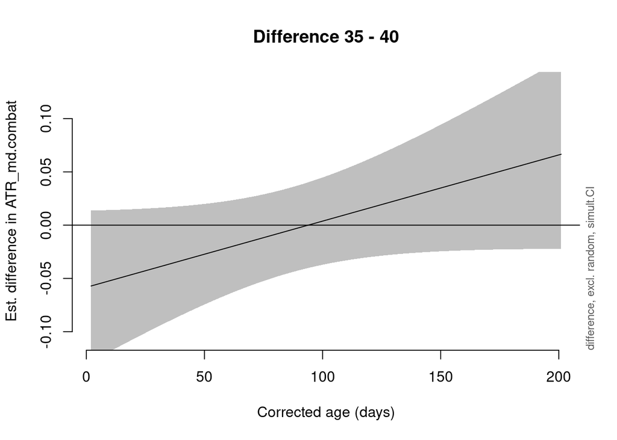

```
##
## Difference is not significant.
```

```r
model.atr.md = gam(ATR_md.combat~ti(Corr_age,k=9)+ti(GA,k=5)+ti(Corr_age,GA,k=c(9,5))+Sex+s(Unique_ID,bs='re'),method='REML',data=dat_harmonized)
plot_diff(model.atr.md,view='Corr_age',comp=list(GA=c(35,40)),sim.ci = TRUE,xlab='Corrected age (days)')
```

Conclusion: Gestational age has little effect. In ATR, the approximate pvalue is significant, but the difference plot shows little effect. The estimated effect is a bit hard to interpret: at age corrected 0 days, GA=35 are more developed (lower MD), but by 200 days, they are less developed. Note: also checked without sex, and result did not change.

In MD PT, main effect of GA has p=0.05 in tensor spline model.

```r
summary(gam(PT_md.combat~s(Corr_age,k=9)+s(GA,k=5)+ti(Corr_age,GA,k=c(9,5))+s(Unique_ID,bs='re'),method='REML',data=dat_harmonized))
```

```
##
## Family: gaussian
## Link function: identity
##
## Formula:
## PT_md.combat ~ s(Corr_age, k = 9) + s(GA, k = 5) + ti(Corr_age,
##     GA, k = c(9, 5)) + s(Unique_ID, bs = "re")
##
## Parametric coefficients:
##             Estimate Std. Error t value Pr(>|t|)
## (Intercept) 1.054417   0.007207   146.3   <2e-16 ***
## ---
## Signif. codes:  0 '***' 0.001 '**' 0.01 '*' 0.05 '.' 0.1 ' ' 1
##
## Approximate significance of smooth terms:
##                    edf Ref.df      F  p-value
## s(Corr_age)      1.788  2.162 29.793  < 2e-16 ***
## s(GA)            2.555  2.775  2.731   0.0539 .
## ti(Corr_age,GA)  2.201  2.739  0.437   0.6441
## s(Unique_ID)    44.305 77.000  1.457 2.84e-05 ***
## ---
## Signif. codes:  0 '***' 0.001 '**' 0.01 '*' 0.05 '.' 0.1 ' ' 1
##
## R-sq.(adj) =  0.653   Deviance explained = 79.1%
## -REML = -156.3  Scale est. = 0.0023158  n = 129
```

Check if GA is significant when there is not bivariate spline:

```
## Summary:
##  * Corr_age : numeric predictor; with 200 values ranging from 2.000000 to 201.000000.
##  * Unique_ID : factor; set to the value(s): 00106_04. (Might be canceled as random effect, check below.)
##  * NOTE : The following random effects columns are canceled: s(Unique_ID)
##
##  * Simultaneous 95%-CI used :
##      Critical value: 1.927
##      Proportion posterior simulations in pointwise CI: 1 (10000 samples)
##      Proportion posterior simulations in simultaneous CI: 1 (10000 samples)
##
```

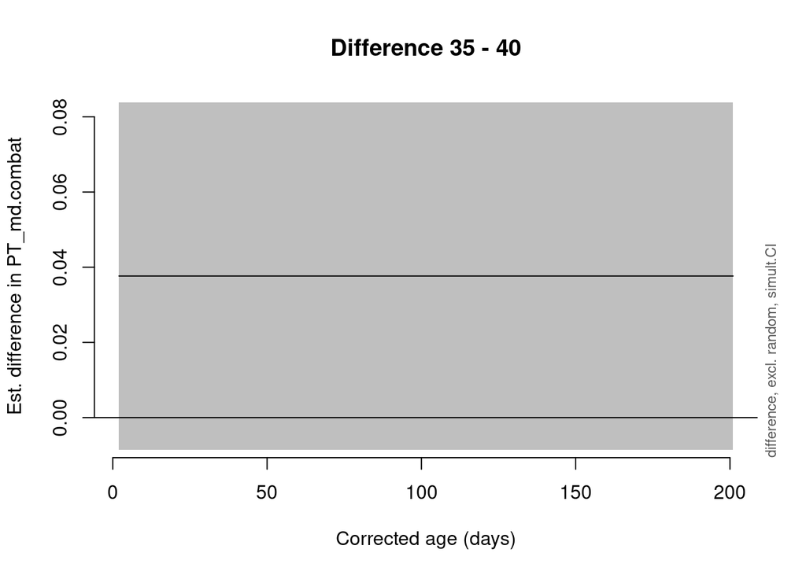

```
##
## Difference is not significant.
```

```r
model.pt.md = gam(PT_md.combat~s(Corr_age,k=9)+s(GA,k=5)+s(Unique_ID,bs='re'),method='REML',data=dat_harmonized)
plot_diff(model.pt.md,view='Corr_age',comp=list(GA=c(35,40)),sim.ci = TRUE,xlab='Corrected age (days)')
```

```r
summary(model.pt.md)
```

```
##
## Family: gaussian
## Link function: identity
##
## Formula:
## PT_md.combat ~ s(Corr_age, k = 9) + s(GA, k = 5) + s(Unique_ID,
##     bs = "re")
##
## Parametric coefficients:
##             Estimate Std. Error t value Pr(>|t|)
## (Intercept) 1.054156   0.007125   147.9   <2e-16 ***
## ---
## Signif. codes:  0 '***' 0.001 '**' 0.01 '*' 0.05 '.' 0.1 ' ' 1
##
## Approximate significance of smooth terms:
##                 edf Ref.df      F  p-value
## s(Corr_age)   1.717  2.064 32.481  < 2e-16 ***
## s(GA)         2.436  2.654  3.197   0.0193 *
## s(Unique_ID) 44.550 77.000  1.449 3.18e-05 ***
## ---
## Signif. codes:  0 '***' 0.001 '**' 0.01 '*' 0.05 '.' 0.1 ' ' 1
##
## R-sq.(adj) =  0.645   Deviance explained =   78%
## -REML = -157.38  Scale est. = 0.0023679  n = 129
```

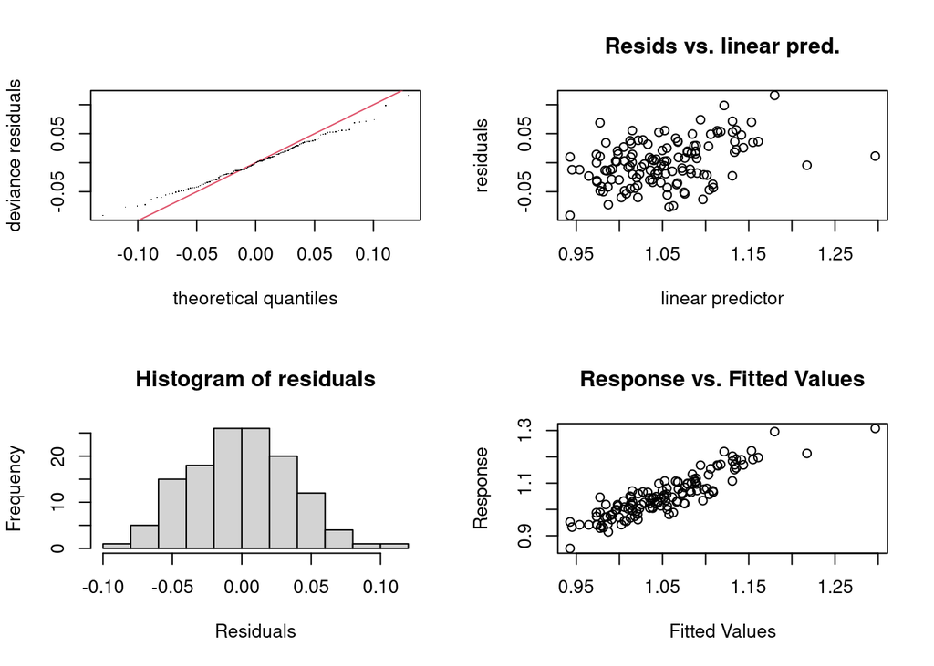

```
##
## Method: REML   Optimizer: outer newton
## full convergence after 6 iterations.
## Gradient range [-1.976485e-07,1.274147e-07]
## (score -157.3772 & scale 0.002367946).
## Hessian positive definite, eigenvalue range [0.1971956,71.39753].
## Model rank =  92 / 92
##
## Basis dimension (k) checking results. Low p-value (k-index<1) may
## indicate that k is too low, especially if edf is close to k'.
##
##                 k'   edf k-index p-value
## s(Corr_age)   8.00  1.72    1.08    0.80
## s(GA)         4.00  2.44    1.11    0.91
## s(Unique_ID) 79.00 44.55      NA      NA
```

```r
# step into function to examine model diagnostics:
gam.check(model.pt.md)
```

Simultaneous confidence intervals broadly overlapping. The approximate p value of GA is smaller (p=0.02), but I defer to the simultaneous confidence bands.